# A Prediction Model Project in Python (Complete Code)

**Bernardo Di Chiara**

*February 21<sup>st</sup>, 2020*

**COURSERA CONFIDENTIAL**

1. Overview  
2. Setup  
3. Defining the Needed Functions  
....3.1. Dataframe handling  
....3.2. Scatter matrixes  
....3.3. Hystograms  
....3.4. Bar plots  
....3.5. Scatter and line plots  
....3.6. Machine learning  
4. Dumping the Data  
5. Data Analysis  
....5.1. Summary of the created dataframes  
....5.2. Preliminary Data Analysis  
............5.2.1. Summary  
............5.2.2. Data fields  
............5.2.3. Details  
....5.3. Data Preparation  
............5.3.1. Summary  
............5.3.2. Merging latitude and longitude data with the train and test data sets  
............5.3.3. Creating a new dataframe to be used in the exploratory data analysis phase  
....5.4. Data Cleansing  
............5.4.1. Summary  
............5.4.2. Checking null values  
............5.4.3. Checking outliers  
............5.4.4. Handling outliers and null values  
............5.4.5. Verifying there are no miss-typed addresses  
....5.5. Exploratory Data Analysis  
............5.5.1. Summary  
............5.5.2. Data Preparation  
............5.5.3. Checking the extreme values of the numerical variables of interest  
............5.5.4. Discount  
............5.5.5. Late fee  
............5.5.6. Data Visualization  
......................5.5.6.1 Numerical variables  
......................5.5.6.2 Target value: Compliance  
......................5.5.6.3 Compliance details  
......................5.5.6.4 Disposition  
......................5.5.6.5 Agency name  
......................5.5.6.6 Violator category  
......................5.5.6.7 Late fee  
......................5.5.6.8 Discount  
......................5.5.6.9 Location  
......................5.5.6.10 Year and month  
....5.6. Preparing Data for Fitting Prediction Models  
............5.6.1. Summary  
............5.6.2. Selecting the variables to be used in the training data set  
............5.6.3. Discarded Variables  
............5.6.4. Separating the features and the target variable  
............5.6.5. Aligning the categorical variable classes with the test dataset and creating indicator variables  
............5.6.6. Modifying the test data set accordingly  
............5.6.7. Separating a validation data set for model evaluation  
............5.6.8. Normalizing the features  
6. Fitting Different Prediction Models  
....6.1. Summary  
....6.2. Selected Evaluation Metrics  
....6.3. Code to be run before model fitting  
....6.4. Decision Tree  
....6.5. Logistic Regression  
....6.6. Linear Support Vector Machines  
....6.7. Random Forest  
....6.8. Gradient Boosted Decision Trees  
7. Selecting the Model  
8. Making a Prediction  
9. Conclusions  
10. Annex: Pipeline code

## 1. Overview

This project is based on a data challenge from the Michigan Data Science Team ([MDST](http://midas.umich.edu/mdst/)).

The Michigan Data Science Team ([MDST](http://midas.umich.edu/mdst/)) and the Michigan Student Symposium for Interdisciplinary Statistical Sciences ([MSSISS](https://sites.lsa.umich.edu/mssiss/)) have partnered with the City of Detroit to help solving one of the most pressing problems facing Detroit: blight. [Blight violations](https://detroitmi.gov/Portals/0/docs/Brochures/DAH/DAH_Citizen_Guide.pdf) are issued by the city to individuals who allow their properties to remain in a deteriorated condition. Every year, the city of Detroit issues millions of dollars in fines to residents and every year, many of these fines remain unpaid. Enforcing unpaid blight fines is a costly and tedious process, so the city in interested in insights that may help to understand how to increase blight ticket compliance.

Therefore, it would be useful to understand when and why a resident might fail to comply with a blight ticket. This is where predictive modeling comes in. The task in the Prediction Competition part of the challenge is to **predict whether a given blight ticket will be paid on time**.

The data for this project has been provided through the [Detroit Open Data Portal](https://data.detroitmi.gov/).

In particular the data that is contained in the [kaggle competition](https://inclass.kaggle.com/c/detroit-blight-ticket-compliance/data) has been used as input data in here.

Before fitting any prediction model, the data is analyzed, prepared and cleansed.

Different prediction models are created and fit to the data. The evaluation metric used to compare the different models is the Area Under the ROC Curve (AUC).

A prediction is done with the selected model by using a separate dataset. The prediction is given as the probability that the corresponding blight ticket will be paid on time (that is, at latest within one month of the hearing date). For every entry in the dataset, the result file contains two columns: ticket_id and compliance (a scalar from 0 to 1 inclusive giving the above mentioned probability).

## 2. Setup

```python
# Importing the needed packages
import datetime as dt
import pandas as pd
import numpy as np
import matplotlib.pyplot as plt
import seaborn as sns
from sklearn.model_selection import train_test_split
from sklearn.preprocessing import MinMaxScaler
from sklearn.tree import DecisionTreeClassifier
from sklearn.linear_model import LogisticRegression
from sklearn.svm import LinearSVC
from sklearn.ensemble import RandomForestClassifier
from sklearn.ensemble import GradientBoostingClassifier
from sklearn.metrics import roc_curve, auc, roc_auc_score

# Displaying all the dafaframe columns
pd.set_option('display.max_columns', None)
```

## 3. Defining the Needed Functions

### 3.1. Dataframe handling

```python
def df_basic_data(dfname):
    # This function prints basic information about a given dataframe.
    # The function needs as input parameters the dataframe name.

    import pandas as pd

    # Fetching the dataframe name
    name = [x for x in globals() if globals()[x] is dfname][0]
    print("Dataframe name:", name, "\n")
    print("Dataframe length:", len(dfname), "\n")
    print("Number of columns:", len(dfname.columns), "\n")
    # Columns data types
    data_types = dfname.dtypes
    # Distint values
    distint_values = dfname.apply(pd.Series.nunique)
    # Amount of null values
    null_values = dfname.isnull().sum()
    print("Dataframe's columns names, column data types, amount of distint "
          "(non null) values\n"
          "and amount of null values for each column:")
    df_index = ['Data_Type',
                'Amount_of_Distint_Values',
                'Amount_of_Null_Values']
    col_types_dist_null = pd.DataFrame([data_types,
                                        distint_values,
                                        null_values],
                                       index=df_index)
    return col_types_dist_null.transpose()
```

```python
def missing_values(dfname,
                   figsize_w=12, figsize_h=8,
                   ref_font_size=12,
                   title="Missing Values in the Columns of the Dataframe",
                   title_offset=20):
    """
    This function plots a heatmap to visualize the amount of missing values
    in the columns of a pandas dataframe and customizes
    the way the chart looks by using the value of the provided parameters.

    Keyword arguments:
    dfname          -- The name of the dataframe (mandatory)
    figsize_w       -- The width of the plot area
    figsize_w       -- The height of the plot area
    ref_font_size   -- The reference font size
    title           -- A string containing the title of the chart
    title_offset    -- The distance between the title and the top of the chart
    """

    import matplotlib.pyplot as plt
    import seaborn as sns

    # Creating a new figure
    plt.figure(figsize=(figsize_w, figsize_h))
    # Defining the used style
    color_style = sns.color_palette(palette='deep')

    # Adding a title (with some distance to the top of the plot)
    plt.title(title, fontsize=ref_font_size*1.33, pad=title_offset)

    # Plotting a heatmap (with no y axis tick labels and no color bar legend)
    hm = sns.heatmap(dfname.isnull(),
                     yticklabels=False,
                     cbar=False,
                     cmap=color_style)

    # Adding labeles on the x axis
    plt.xlabel("Column names", fontsize=ref_font_size)
    # Setting x axis tick label rotation
    hm.set_xticklabels(hm.get_xticklabels(), rotation=45, horizontalalignment='right')

    # Showing the plot without additional text
    plt.show()
```

```python
def cat_perc_split(dfname, columnname, posneg, printout=False):

    '''
    This function takes a categorical variable (columnname) of a dataframe
    (dfname) and creates two series with length equal to the amount of unique
    category values.
    Then for each category value it calculates the percentage of entries
    for each of the two values of a second dataframe column (posneg),
    which contains a binary categorical variable (positive / negative).
    The function prints the result and returns two series containing
    the percentage value for each category,
    separately for the positive and the negative cases
    (the positive case is given first).

    Keyword arguments:
    dfname          -- The name of the dataframe (mandatory)
    columnname      -- A string containing the name of the categorical column
                       (mandatory)
    posneg          -- A string containing the name of the binary
                       categorical column (mandatory)
    printout        -- A boolean variable that controls if to print info (default False)
    '''

    # Finding the amount of unique categories in the series
    cat_number = dfname[columnname].nunique()
    # Creating a Series to contain the percentages of positove cases
    # for each category
    pos = pd.Series(index=dfname[columnname].unique().sort_values())
    # Creating a Series to contain the percentages of negative cases
    # for each category
    neg = pd.Series(index=dfname[columnname].unique().sort_values())

    # Iterating through the unique values of the variable columnname
    for name, i in zip(dfname[columnname].unique().sort_values(),
                       list(range(cat_number))):
        # Finding the percentage of positive and negavive values
        # for each category
        split = dfname[dfname[columnname] == name][posneg]\
                .value_counts(normalize=True)*100  # series
        # Adding percentages of negative cases to the Series created above
        neg.at[i] = split[0]
        # Adding percentages of positive cases to the Series created above
        pos.at[i] = 100 - split[0]
        if printout:
            print("Category:", name, "\n",
                  "Negative cases in percentage:", split[0], "\n",
                  "Positive cases in percentage:", 100 - split[0], "\n")

    return pos, neg
```

### 3.2. Scatter matrixes

```python
def cust_scatter_matrix(dfname, columns,
                        figsize=15, font_size=15,
                        title=None, title_offset=0.945):
    """
    This function plots a scatter matrix for the provided data and customizes
    the way the chart looks by using the value of the provided parameters.

    Keyword arguments:
    dfname          -- The name of a pandas dataframe (mandatory)
    columns         -- A list of column names (mandatory)
    figsize         -- The reference figure size (default = 15)
    font_size       -- The reference font size (default = 15)
    title           -- A string containing the title of the chart
                       (default: None)
    title_offset    -- The offset of the title
    """

    import pandas as pd
    import matplotlib.pyplot as plt

    # Creating a scatter matrix
    sm = pd.plotting.scatter_matrix(dfname.loc[:, columns],
                                    figsize=[figsize, figsize])

    # Adding a title
    plt.suptitle(title,
                 fontsize=1.7*font_size,
                 y=title_offset)

    # Formatting the axes' labels and ticks
    for ax in sm.ravel():
        ax.set_xlabel(ax.get_xlabel(), fontsize=1.1*font_size,
                      rotation=0, labelpad=0.66*font_size)
        ax.set_ylabel(ax.get_ylabel(), fontsize=1.1*font_size,
                      rotation=90, labelpad=0.66*font_size)
        ax.xaxis.set_tick_params(labelsize=0.95*font_size, pad=0.33*font_size)
        ax.yaxis.set_tick_params(labelsize=0.95*font_size, pad=0.33*font_size)
```

```python
def cust_pairplot(df, target,
                  s=2,
                  font_size=12,
                  col_numb1=1,
                  col_numb2=2,
                  title=None, title_offset=1):
    """
    This function plots a pair plot for the provided data and customizes
    the way the chart looks by using the value of the provided parameters.

    Keyword arguments:
    df              -- A pandas dataframe (mandatory)
    target          -- A string containing the name of the column containing
                       the target value (mandatory)
    s               -- It controls the size of the figure
    col_numb1,
    col_numb2       -- The colors to be used in the heatmap
    font_size       -- The reference font size (default = 12)
    title           -- A string containing the title of the chart
                       (default: None)
    title_offset    -- The offset of the title
    """

    import pandas as pd
    import matplotlib.pyplot as plt
    import seaborn as sns

    # Creating a pair plot
    pp = sns.pairplot(df, hue=target,
                      diag_kind='hist',
                      height=s,
                      palette=[sns.color_palette(palette='deep')[col_numb1],
                               sns.color_palette(palette='deep')[col_numb2]])

    # Adding a title
    pp.fig.suptitle(title,
                    fontsize=1.5*font_size,
                    y=title_offset)

    # Formatting the axes' labels and ticks
    for ax in pp.axes.flat:
        ax.set_xlabel(ax.get_xlabel(), fontsize=font_size,
                      rotation=0, labelpad=0.66*font_size)
        ax.set_ylabel(ax.get_ylabel(), fontsize=font_size,
                      rotation=90, labelpad=0.66*font_size)
        ax.xaxis.set_tick_params(labelsize=0.83*font_size, pad=0.33*font_size)
        ax.yaxis.set_tick_params(labelsize=0.83*font_size, pad=0.33*font_size)
```

### 3.3. Hystograms

```python
def cust_hist(data, figsize_w=8, figsize_h=6,
              title=None, title_fs=16, title_offset=20,
              rem_borders=False,
              x_label=None, xlabel_fs=12,
              n_bins=10, col_numb=0):
    """
    This function plots a histogram for the provided data and customizes
    the way the chart looks by using the value of the provided parameters.

    Keyword arguments:
    data            -- A pandas Series (mandatory)
    figsize_w       -- The width of the plot area
    figsize_w       -- The height of the plot area
    title           -- A string containing the title of the chart
    title_fs        -- The title font size
    title_offset    -- The distance between the title and the top of the chart
    rem_borders     -- If True, the top and right borders are removed
                       (default: False)
    x_label         -- Label for the x-axis (string)
    xlabel_fs       -- x axis labels' font size
    n_bins          -- An integer giving the numner of bins or
                       a list giving the bin edges
                       (all but the last interval are open to the right)
    col_numb        -- An integer between 0 and 9 that indicated the
                       seaborn-deep color to be used for the plot
    """

    import pandas as pd
    import matplotlib.pyplot as plt
    import seaborn as sns

    # Creating a new figure
    plt.figure(figsize=(figsize_w, figsize_h))
    # Defining the used style
    color_list = sns.color_palette(palette='deep')
    # Removing the top and right borders if so defined
    if rem_borders is True:
        plt.gca().spines['top'].set_visible(False)
        plt.gca().spines['right'].set_visible(False)

    # Adding a title (with some distance to the top of the plot)
    plt.title(title, fontsize=title_fs, pad=title_offset)

    # Creating the histogram
    plt.hist(data, bins=n_bins, color=color_list[col_numb])

    # If a label for the x axis is provided, showing it on the x axis
    if x_label:
        plt.xlabel(x_label, fontsize=xlabel_fs)

    # Showing the plot without additional text
    plt.show()
```

### 3.4. Bar plots

```python
def plot_cust_bar(data,
                  figsize_w=8, figsize_h=6,
                  frame=True, grid=False,
                  ref_font_size=12,
                  title_text=None,
                  title_offset=20,
                  color_numb=0,
                  categ_labels=True,
                  labels=None,
                  rot=0,
                  show_values=False,
                  omitted_value=0,
                  percent=False,
                  value_offset=1,
                  visible_digits=2):
    """
    This function plots a bar charts for the provided data with
    the provided labels and settings.

    Keyword arguments:
    data            -- A list that contains sorted data of a categorical series
                       (mandatory)
    figsize_w       -- The width of the plot area
    figsize_h       -- The height of the plot area
    frame           -- If False, the figure frame is omitted as well as
                       ticks and labels on the y axis (default is True)
    grid            -- If True a horizontal grid is displayed. It works
                       only when frame=True (default is False)
    ref_font_size   -- Reference font size used for all the fonts
    title_text      -- A string containing the title of the chart
    title_offset    -- The offset of the title from the rest of the plot
    color_numb      -- An integer between 0 and 9 that indicated the
                       seaborn-deep color to be used for the bars
    categ_labels    -- A boolean variable that defines if category labels
                       shall appear (on the x-axis)
    labels          -- List of category labels (strings). Used only if
                       categ_labels=True.
                       They override the existing lables
    rot             -- The rotation of the x axsis label (numerical)
                       (the default is horizontal)
    show_values     -- If True, then numeric value labels will be shown on
                       each bar (default is False)
    omitted_value   -- The max value that shall not be shown in the bar
    percent         -- If true, it indicates that the values are in percentage
                       (default is False)
    value_offset    -- Used to position the bar values in the plott
    visible_digits  -- Integer defining the number of decimal digits
                       to be seen in the value labels (the default is 2)
    """

    import pandas as pd
    import matplotlib.pyplot as plt
    import seaborn as sns

    # Finding the number of categories
    cat_number = len(data)

    # Defining the suffix to be shown in the bar values
    if percent:
        p = '%'
    else:
        p = ""

    # Preparing the indexes for the x axis
    ind = list(range(cat_number))

    # Creating a new figure
    fig = plt.figure(figsize=(figsize_w, figsize_h))
    # Defining the used style
    color_list = sns.color_palette(palette='deep')

    # Removing x axis ticks
    plt.gca().xaxis.set_ticks_position('none')

    if not frame:
        # Removing the borders, if so defined
        sns.despine(top=True, right=True, left=True, bottom=True)
        # Removing ticks and values in the y axes
        plt.gca().axes.get_yaxis().set_visible(False)
    elif grid:
        # Showing a horizontal grig, if so defined
        plt.gca().yaxis.grid(color='grey', alpha=0.25,
                             linestyle='-', linewidth=1)

    # Adding a title (with some distance to the top of the plot)
    plt.title(title_text, fontsize=ref_font_size*1.33, pad=title_offset)

    # Creating the bar plot
    plot = plt.bar(ind, data, color=color_list[color_numb])

    # Showing category labels them on the x axes, if so defined
    if categ_labels:
        # Overriding the index value if category labels are provided
        if labels:
            plt.xticks(ind, labels, fontsize=ref_font_size, rotation=rot)
        else:
            plt.xticks(ind, data.index.tolist(),
                       fontsize=ref_font_size, rotation=rot)
    else:
        # Removing ticks and values in the x axes
        plt.gca().axes.get_xaxis().set_visible(False)

    # Showing the bar values, if so defined
    if show_values:
        # Iterating through the bars in the plot
        for bar in plot:
            # Getting bar height and width
            w, h = bar.get_width(), bar.get_height()
            # Printing the values only if they are bigger than the defined value
            if h > omitted_value:
                # Positioning the text in the centre of the bar horizontally
                # and on top of the bar with an offset vertically
                plt.text(bar.get_x() + w/2, bar.get_y() + h + value_offset,
                         "{}".format(round(h, visible_digits))+p,
                         fontsize=ref_font_size,
                         ha="center", va="baseline")

    # Showing the plot without additional text
    plt.show()
```

```python
def plot_cust_hbar(data,
                   figsize_w=8, figsize_h=6,
                   frame=True, grid=False,
                   ref_font_size=12,
                   title_text=None,
                   title_offset=20,
                   color_numb=0,
                   categ_labels=True,
                   labels=None,
                   rot=0,
                   show_values=False,
                   omitted_value=0,
                   percent=False,
                   value_offset=1,
                   visible_digits=2):
    """
    This function plots a horizontal bar charts for the provided data with
    the provided labels and settings.

    Keyword arguments:
    data            -- A sorted Series that contains categorical data
                       (mandatory)
    figsize_w       -- The width of the plot area
    figsize_h       -- The height of the plot area
    frame           -- If False, the figure frame is omitted as well as
                       ticks and labels on the y axis (default is True)
    grid            -- If True a horizontal grid is displayed. It works
                       only when frame=True (default is False)
    ref_font_size   -- Reference font size used for all the fonts
    title_text      -- A string containing the title of the chart
    title_offset    -- The offset of the title from the rest of the plot
    color_numb      -- An integer between 0 and 9 that indicated the
                       seaborn-deep color to be used for the bars
    categ_labels    -- A boolean variable that defines if category labels
                       shall appear (on the y-axis)
    labels          -- List of category labels (strings) used only if
                       categ_labels=True.
                       They override the existing lables
    rot             -- The rotation of the x axsis label (numerical)
                       (the default is horizontal)
    show_values     -- If True, then numeric value labels will be shown on
                       each bar (default is False)
    omitted_value   -- The max value that shall not be shown in the bar
    percent         -- If true, it indicates that the values are in percentage
                       (default is False)
    value_offset    -- Used to position the bar values in the plott
    visible_digits  -- Integer defining the number of decimal digits
                       to be seen in the value labels (the default is 2)
    """

    import pandas as pd
    import matplotlib.pyplot as plt
    import seaborn as sns

    # Finding the number of categories
    cat_number = len(data)

    # Defining the suffix to be shown in the bar values
    if percent:
        p = '%'
    else:
        p = ""

    # Preparing the indexes for the x axis
    ind = list(range(cat_number))

    # Creating a new figure
    fig = plt.figure(figsize=(figsize_w, figsize_h))
    # Defining the used style
    color_list = sns.color_palette(palette='deep')

    # Removing y axis ticks
    plt.gca().yaxis.set_ticks_position('none')

    if frame is False:
        # Removing the borders, if so defined
        sns.despine(top=True, right=True, left=True, bottom=True)
        # Removing ticks and values in the x axes
        plt.gca().axes.get_xaxis().set_visible(False)
    elif grid:
        # Showing a vertical grig, if so defined
        plt.gca().xaxis.grid(color='grey', alpha=0.25,
                             linestyle='-', linewidth=1)

    # Adding a title (with some distance to the top of the plot)
    plt.title(title_text, fontsize=ref_font_size*1.33,
              loc='center', pad=title_offset)

    # Creating the bar plot
    plot = plt.barh(ind, data, color=color_list[color_numb])

    # Showing category labels them on the y axes, if so defined
    if categ_labels:
        # Overriding the index value if category labels are provided
        if labels:
            plt.yticks(ind, labels, fontsize=ref_font_size, rotation=rot)
        else:
            plt.yticks(ind, data.index.tolist(),
                       fontsize=ref_font_size, rotation=rot)
    else:
        # Removing ticks and values in the y axes
        plt.gca().axes.get_yaxis().set_visible(False)

    # Showing the bar values, if so defined
    if show_values:
        # Iterating through the bars in the plot
        for bar in plot:
            # Getting bar height and width
            w, h = bar.get_width(), bar.get_height()
            # Printing the values only if they are bigger than the defined value
            if w > omitted_value:
                # Positioning the text in the centre of the bar horizontally
                # and on top of the bar with an offset vertically
                plt.text(bar.get_x() + w + value_offset, bar.get_y() + h/2,
                         "{}".format(round(w, visible_digits))+p,
                         fontsize=ref_font_size,
                         ha="left", va="center")

    # Showing the plot without additional text
    plt.show()
```

```python
def plot_side_by_side_hbar(data1, data2, data3,
                           figsize_w=8, figsize_h=6,
                           frame=True, grid=False,
                           ref_font_size=12,
                           title_text=None,
                           title_offset=20,
                           color_numb1=0,
                           color_numb2=1,
                           color_numb3=2,
                           categ_labels=True,
                           labels=None,
                           rot=0,
                           show_values=False,
                           omitted_value=0,
                           percent=False,
                           value_offset=0,
                           visible_digits=2,
                           leg_list=None,
                           leg_loc=0):
    """
    This function plots a horizontal bar charts with 3 side by side bars
    for the provided data with the provided labels and settings.

    Keyword arguments:
    data1           -- A Series or a list that contains data of a categorical
                       series to be used for the first set of bars (mandatory)
    data2           -- Same as above for the second set of bars
    data3           -- Same as above for the third set of bars
    figsize_w       -- The width of the plot area
    figsize_h       -- The height of the plot area
    frame           -- If False, the figure frame is omitted as well as
                       ticks and labels on the y axis (default is True)
    grid            -- If True a horizontal grid is displayed. It works
                       only when frame=True (default is False)
    ref_font_size   -- Reference font size used for all the fonts
    title_text      -- A string containing the title of the chart
    title_offset    -- The offset of the title from the rest of the plot
    color_numb1     -- An integer between 0 and 9 that indicated the
                       seaborn-deep color to be used for the first set of bars
    color_numb2     -- Same as above for the second set of bars
    color_numb3     -- Same as above for the third set of bars
    categ_labels    -- A boolean variable that defines if category labels
                       shall appear (on the y-axis)
    labels          -- List of category labels (strings) used only if
                       categ_labels=True.
                       They override the existing lables
    rot             -- The rotation of the y axsis label (numerical)
                       (the default is horizontal)
    show_values     -- If True, then numeric value labels will be shown on
                       each bar (default is False)
    omitted_value   -- The max value that shall not be shown in the bar
    percent         -- If true, it indicates that the values are in percentage
                       (default is False)
    value_offset    -- Used to position the bar values in the plott
    visible_digits  -- Integer defining the number of decimal digits
                       to be seen in the value labels (the default is 2)
    leg_list        -- A list containing the content of the legend
    leg_loc         -- A integer from 0 to 9 indicating the location of the
                       legend
    """

    import pandas as pd
    import matplotlib.pyplot as plt
    import seaborn as sns

    # Defining the suffix to be shown in the bar values
    if percent:
        p = '%'
    else:
        p = ""

    # Defining the vertical width of the bars
    bars_width = 1/4

    # Creating a new figure
    fig = plt.figure(figsize=(figsize_w, figsize_h))
    # Defining the used style
    color_list = sns.color_palette(palette='deep')

    # Removing y axis ticks
    plt.gca().yaxis.set_ticks_position('none')

    if frame is False:
        # Removing the borders, if so defined
        sns.despine(top=True, right=True, left=True, bottom=True)
        # Removing ticks and values in the x axes
        plt.gca().axes.get_xaxis().set_visible(False)
    elif grid:
        # Showing a vertical grig, if so defined
        plt.gca().xaxis.grid(color='grey', alpha=0.25,
                             linestyle='-', linewidth=1)

    # Adding a title (with some distance to the top of the plot)
    plt.title(title_text, fontsize=ref_font_size*1.33,
              loc='center', pad=title_offset)

    # Creating the bar plot
    plot1 = plt.barh([x + bars_width for x in range(len(data1))],
                     data1,
                     height=bars_width,
                     color=color_list[color_numb1])
    plot2 = plt.barh([x for x in range(len(data2))],
                     data2,
                     height=bars_width,
                     color=color_list[color_numb2])
    plot3 = plt.barh([x - bars_width for x in range(len(data3))],
                     data3,
                     height=bars_width,
                     color=color_list[color_numb3])
    plots = [plot1, plot2, plot3]

    # Showing category labels them on the y axes, if so defined
    if categ_labels:
        # Overriding the index value if category labels are provided
        if labels:
            plt.yticks(range(len(labels)), labels,
                       fontsize=ref_font_size, rotation=rot)
        else:
            plt.yticks(list(range(len(data1))),
                       data1.index.tolist(),
                       fontsize=ref_font_size,
                       rotation=rot)
    else:
        # Removing ticks and values in the y axes
        plt.gca().axes.get_yaxis().set_visible(False)

    # Showing the bar values, if so defined
    if show_values:
        # Iterating through the three sets of bars
        for plot in plots:
            # Iterating through the bars in each set
            for bar in plot:
                # Getting bar height and width
                w, h = bar.get_width(), bar.get_height()
                # Printing the values only if they are bigger than
                # the defined value
                if w > omitted_value:
                    # Positioning the text in the centre of the bar vertically
                    # and on the right of the bar with an offset horizontally
                    plt.text(bar.get_x() + w + value_offset, bar.get_y() + h/2,
                             "{}".format(round(w, visible_digits))+p,
                             fontsize=ref_font_size,
                             ha="left", va="center")

    # Adding a legend
    if leg_list:
        fig.legend(leg_list,
                   frameon=False,
                   fontsize=ref_font_size*0.83,
                   loc=leg_loc)

    # Showing the plot without additional text
    plt.show()
```

### 3.5. Scatter and line plots

```python
def lat_long_scatter_plot(x1, y1,
                          figsize_w=8, figsize_h=6,
                          axses_limits=False,
                          xmin=None,
                          xmax=None,
                          ymin=None,
                          ymax=None,
                          ref_font_size=12,
                          title=None,
                          title_offset=20,
                          col_numb=0,
                          x_label=None,
                          y_label=None):
    """
    This function plots a scatterplot for the provided data and customizes
    the way the chart looks by using the value of the provided parameters.
    The plot is optimized to show latitide and longitude.

    Keyword arguments:
    x1               -- A pandas Series containing the x values (mandatory)
    y1               -- A pandas Series containing the y values (mandatory)
    figsize_w        -- The width of the plot area
    figsize_w        -- The height of the plot area
    axses_limits     -- A boolean variable that, if True, expects
                        axses limits as input
    xmin, xmax       -- The limits of the x axis
                        (used only if axses_limits=True)
    ymin, ymax       -- The limits of the y axis
                        (used only if axses_limits=True)
    ref_font_size    -- The reference font size
    title            -- A string containing the title of the chart
    title_offset     -- Distance between the title and the top of the chart
    col_numb         -- An integer (from 0 to 9) selecting the seaborn-deep
                        color
    x_label          -- Label for the x-axis (string)
    y_label          -- Label for the y-axis (string)
    """

    import matplotlib.pyplot as plt
    import seaborn as sns

    # Creating a new figure
    plt.figure(figsize=(figsize_w, figsize_h))

    # Defining the used style
    color_list = sns.color_palette(palette='deep')
    # Showing a horizontal and vertical grid and formatting the plot border
    # the same way
    for spine in plt.gca().spines.values():
        spine.set_edgecolor('grey')
        spine.set_linestyle('-')
        spine.set_linewidth(1)
        spine.set_alpha(0.25)
    plt.gca().xaxis.grid(color='grey', linestyle='-', linewidth=1, alpha=0.25)
    plt.gca().yaxis.grid(color='grey', linestyle='-', linewidth=1, alpha=0.25)
    # Removing ticks for the axses
    plt.gca().xaxis.set_ticks_position('none')
    plt.gca().yaxis.set_ticks_position('none')
    # Setting limits for the axses, if defined so
    if axses_limits:
        plt.gca().set_xlim(xmin, xmax)
        plt.gca().set_ylim(ymin, ymax)

    # Adding a title (with some distance to the top of the plot)
    plt.title(title, fontsize=ref_font_size*1.33, pad=title_offset)

    # Creating the scatter plot
    plt.scatter(x1, y1, marker=".", color=color_list[col_numb])

    # If a label for the x axis is provided, showing it on the x axis
    if x_label:
        plt.xlabel(x_label, fontsize=ref_font_size)
    # If a label for the y axis is provided, showing it on the y axis
    if y_label:
        plt.ylabel(y_label, fontsize=ref_font_size)

    # Showing the plot without additional text
    plt.show()
```

### 3.6. Machine learning

```python
def plot_feature_importances(model, feature_names,
                             figsize_w=8, figsize_h=12,
                             ref_font_size=12,
                             title_offset=0,
                             feat_numb=10,
                             value_offset=0,
                             visible_digits=2):

    """
    This function allows to visualize a horizontal bar chart containing
    the feature importance of a decision tree.
    The features are listed in decreasing importance order.

    Keyword arguments:
    model           -- A fitted model
    feature_names   -- A list of strings containing the feature names
    figsize_w       -- The width of the plot area
    figsize_h       -- The height of the plot area
    feat_numb       -- The number of features that shall be visualized
                       (default = 10).
                       This is useful for high dimensional datasets.
    value_offset    -- Used to position the bar values in the plot
    visible_digits  -- Integer defining the number of decimal digits
                       to be seen in the value labels (the default is 2)
    """

    import numpy as np
    import matplotlib.pyplot as plt
    import seaborn as sns

    # Calculate feature importances
    importances = model.feature_importances_  # numpy.ndarray
    # Sorting feature importances in descending order
    indices = np.argsort(importances)[::-1]
    # Rearranging the feature names so they match the sorted feature importances
    feat_names = [feature_names[i] for i in indices]  # list
    # Selecting the top of the list
    top_feats = feat_names[0:feat_numb]
    top_import = importances[indices][0:feat_numb]
    # Sorting feature importances of the most important features in
    # ascending order
    top_import = np.sort(top_import)[::1]
    # Rearranging the feature names accordingly
    top_feats = list(reversed(top_feats))

    # Creating a plot
    plt.figure(figsize=(figsize_w, figsize_h))

    # Removing the borders
    for spine in plt.gca().spines.values():
        spine.set_visible(False)
    # Removing ticks and values in the x axis
    plt.gca().axes.get_xaxis().set_visible(False)
    # Removing y axes ticks
    plt.gca().yaxis.set_ticks_position('none')

    # Adding a title
    plt.title("Feature importance for the most influential features",
              fontsize=ref_font_size*1.33, pad=title_offset)
    # Adding axses labels
    plt.ylabel("Feature name", fontsize=ref_font_size)
    # Adding the feature names as y-axis tick labels
    plt.yticks(np.arange(feat_numb), top_feats, fontsize=ref_font_size*0.83)

    # Adding horizontal bars
    plot = plt.barh(list(range(feat_numb)), top_import)

    # Adding bar labels with the actual bar lenght value
    # Iterating through the bars in the plot
    for bar in plot:
        # Getting bar height and width
        w, h = bar.get_width(), bar.get_height()
        # Positioning the text in the centre of the bar vertically
        # and on the right of the bar with an offset horizontally
        plt.text(bar.get_x() + w + value_offset, bar.get_y() + h/2,
                 "{}".format(round(w, visible_digits)), fontsize=ref_font_size,
                 ha="left", va="center")

    # Showing the plot without additional text
    plt.tight_layout()
    plt.show()
```

```python
def ROC_Curve(*parameters,
              figsize_w=8, figsize_h=6,
              ref_font_size=12,
              title="ROC curve",
              title_offset=20,
              col_numb=0):
    """
    This function plots a lineplot for the provided data and customizes
    the way the chart looks by using the value of the provided parameters.
    The plot is optimized to show a ROC curve and the ROC score
    and it can plot up several different curves

    Keyword arguments:
    parameters       -- A tuple containing 4 values:
                        - fpr (an array containing the false positive rate),
                        - tpr (an array containing the true positive rate),
                        - roc_auc (a float containing the value of
                        the area under the curve)
                        - a string containingt ext to be inserted in the label
                        of the legend
                        (mandatory - more than a tuple can be provided)
    figsize_w        -- The width of the plot area
    figsize_w        -- The height of the plot area
    ref_font_size    -- The reference font size
    title            -- A string containing the title of the chart
    title_offset     -- Distance between the title and the top of the chart
    col_numb         -- An integer (from 0 to 9) selecting the seaborn-deep
                        color of the first curve
    """

    import matplotlib.pyplot as plt
    import seaborn as sns

    # Creating a new figure
    plt.figure(figsize=(figsize_w, figsize_h))

    # Defining the used style
    color_list = sns.color_palette(palette='deep')

    # Setting limits for the axses
    plt.gca().set_xlim(-0.01, 1.0)
    plt.gca().set_ylim(-0.01, 1.0)

    # Adding a title (with some distance to the top of the plot)
    plt.title(title, fontsize=ref_font_size*1.33, pad=title_offset)

    # Creating the ROC line plot and adding a label with the AUC value
    # for each provided tupe of values
    col = col_numb
    for param in parameters:
        fpr = param[0]
        tpr = param[1]
        roc_auc = param[2]
        label_text = param[3]
        plt.plot(fpr, tpr,
                 linewidth=3, color=color_list[col],
                 label=label_text + " (area = {:0.4f})".format(roc_auc))
        # Setting the color to the next one for the next loop
        if col <= 8:
            col += 1
        else:
            col = 0
    # Adding a legend with the label and AUC value
    plt.legend(loc='lower right', fontsize=ref_font_size*0.83)
    # Adding the baseline
    plt.plot([0, 1], [0, 1],
             color=color_list[7], linewidth=3, linestyle='--')

    # Showing x axis label
    plt.xlabel("False Positive Rate", fontsize=ref_font_size)
    # Showing y axis label
    plt.ylabel("True Positive Rate", fontsize=ref_font_size)

    # Showing the plot without additional text
    plt.show()
```

## 4. Dumping the Data

The files are located in the directory `readonly` under the directory containing this notebook.

```python
# Training data set
train = pd.read_csv('readonly/train.csv', encoding="ISO-8859-1",
                    low_memory=False)
# Test data set
test = pd.read_csv('readonly/test.csv', encoding="ISO-8859-1")
# Additional files
addresses = pd.read_csv('readonly/addresses.csv', encoding="ISO-8859-1")
latlons = pd.read_csv('readonly/latlons.csv', encoding="ISO-8859-1")
```

**File descriptions**

- `train.csv`: the training set
- `test.csv`: the test set
- `addresses.csv`: mapping from ticket id to addresses
- `latlons.csv`: mapping from addresses to lat/lon coordinates
  - Note: misspelled addresses may be incorrectly geolocated

## 5. Data Analysis

### 5.1. Summary of the Created Dataframes

Within this document, different datasets are used for different purposes. This section provides a summary as a useful reference. Those variables that have been created temporarily just for reason of code clarity are not included in this list.

**train_coord**

- Based on `train`
- The columns *address*, *lat* and *lon* have been added

**test_coord**

**train_modified**

**train_cleaned**

**train_cl_compl**

- Based on `train_cleaned`
- It contains only entries with *compliance* = 1

**train_cl_no_compl**

- Based on `train_cleaned`
- It contains only entries with *compliance* = 0

**train_selected**

- Based on `train_cleaned`
- Columns:
  - ticket_id
  - agency_name
  - year
  - month
  - violator_cat
  - lat
  - lon
  - disposition
  - fine_amount
  - late_fee
  - discount
  - compliance

**train_features**

- Based on `train_selected`
- Contains only the features

**train_target**

- Based on `train_selected`
- Contains only the target variable

**train_feat_cat**

- Based on `train_features`
- Categorical variables are converted into indicator variables
- Columns which have only zero values are dropped

**test_mod**

- Based on `test_coord`
- *late_fee* has been converted into binary categorical variables
  - all entries with value different from 0.0 are converted into value 1.0
- A new binary categorical variable based on discount_amount has been created
  - all entries with value different from 0.0 are converted into value 1.0
- agency_name, inspector_name and violation_code have been converted into categorical type
- Year and month have been extracted into separate numerical variables

**test_features**

- Based on `test_mod`
- The null values of *lat* and *lon* have been filled with the mean values in the column
- Columns:
  - ticket_id
  - agency_name
  - year
  - month
  - violator_cat
  - lat
  - lon
  - disposition
  - fine_amount
  - late_fee
  - discount

**test_feat_cat**

- Based on `test_features`
- Categorical variables are converted into indicator variables

**X_train, y_train**

- Based on `train_feat_cat`, `train_target`
- Train dataset

**X_val, y_val**

- Based on `train_feat_cat`, `train_target`
- Validation dataset

**X_train_scaled**

- Based on `X_train`
- The feature values have been normalized

**X_val_scaled**

- Based on `X_val`
- The feature values have been normalized

### 5.2. Preliminary Data Analysis

#### 5.2.1. Summary

The **train dataset** has 250306 entries. The **test dataset** has 61001 entries. This correspond to a 80% / 20% train / test split.

However, the train set has 90426 entries will null value in the variable compliance (that corresponds to about 36% of the entries). Those are the entries corresponding to violators that were found not responsible. This leaves only 159880 entries in the train dataset corresponding to responsible violators. By considering only those entries, the train / test split is actually 72% / 28 %.

In order to avoid data leakage, the test data set contains entries that are belonging time-wise to the period after a **timestamp cutoff** (which is at the end of year 2011).

Therefore, `train.csv` contains tickets issued in the period 2004-2011 whereas `test.csv` contains tickets issued in the period 2012-2016.

Note that there are three data insertion mistakes in the ticket_issued_date column of the train dataset.

Each row in these two files corresponds to a single blight ticket, and includes information about when, where, why, by whom and to whom each ticket was issued.

The **target variable** is *compliance*, which is True if the ticket was paid early, on time, or within one month of the hearing date, False if the ticket was paid later than one month after the hearing date or not at all, and Null if the violator was found not responsible. This variable, as well as a handful of other variables that will not be available at test-time, are only included in `train.csv`.

The **addresses dataset** contains 311307 entries, that is the sum of the entries in the train dataset (250306) and the entries in the test dataset (61001). There are 121769 unique addresses in the address dataset, which is the same as the number of entries of the **latlons dataset**. This means that in the latlons dataset there are entries for every ticket id.

45.652 out of 119. 992 violators have had more than 1 accident. 1864 of them have had more than 10 accidents and 19 of them have had more than 100 accidents.

#### 5.2.2. Data fields

`train.csv` & `test.csv`:

- ticket_id: unique identifier for blight tickets
- agency_name: Agency that issued the ticket
- inspector_name: Name of the inspector that issued the ticket
- violator_name: Name of the person/organization that the ticket was issued to
- violation_street_number, violation_street_name, violation_zip_code: Address where the violation occurred
- mailing_address_str_number, mailing_address_str_name, city, state, zip_code, non_us_str_code, country: Mailing address of the violator
- ticket_issued_date: Date and time the ticket was issued
- hearing_date: Date and time the violator's hearing was scheduled (if the property owner complies before the hearing, the fine is withdrawn)
- violation_code, violation_description: Type of violation
- disposition: Judgment and judgement type
- fine_amount: Violation fine amount, excluding fees
- admin_fee: 20 dollars fee assigned to responsible judgements
- state_fee: 10 dollars fee assigned to responsible judgments
- late_fee: 10% fee assigned to responsible judgments (this penality is imposed if the propriety owner is found responsible at hearing and the fine and fees imposed are not paid by the hearing date)
- discount_amount: discount applied, if any
- clean_up_cost: DPW clean-up or graffiti removal cost
- judgment_amount: Sum of all fines and fees
- grafitti_status: Flag for graffiti violations

`train.csv` only:

- payment_amount: Amount paid, if any
- payment_date: Date payment was made, if it was received
- payment_status: Current payment status as of Feb 1 2017
- balance_due: Fines and fees still owed
- collection_status: Flag for payments in collections
- compliance [target variable for prediction]
  - Null = Not responsible
  - 0 = Responsible, non-compliant
  - 1 = Responsible, compliant
- compliance_detail: More information on why each ticket was marked compliant or non-compliant

`addresses.csv` only:

- ticket_id
- address: a combination of violation_street_number and violation_street_name

`latlonss.csv` only:

- address
- lat: latitude corresponding to the violation address
- lon: longitude corresponding to the violation address

#### 5.2.3. Details

```python
# Visualizing basic dataframe and column information of the train dataset
df_basic_data(train)
```

```
Dataframe name: train

Dataframe length: 250306

Number of columns: 34

Dataframe's columns names, column data types, amount of distint (non null) values
and amount of null values for each column:
```

|  | Data_Type | Amount_of_Distint_Values | Amount_of_Null_Values |
| --- | --- | --- | --- |
| ticket_id | int64 | 250306 | 0 |
| agency_name | object | 5 | 0 |
| inspector_name | object | 173 | 0 |
| violator_name | object | 119992 | 34 |
| violation_street_number | float64 | 19175 | 0 |
| violation_street_name | object | 1791 | 0 |
| violation_zip_code | float64 | 0 | 250306 |
| mailing_address_str_number | float64 | 15826 | 3602 |
| mailing_address_str_name | object | 37896 | 4 |
| city | object | 5184 | 0 |
| state | object | 59 | 93 |
| zip_code | object | 4251 | 1 |
| non_us_str_code | object | 2 | 250303 |
| country | object | 5 | 0 |
| ticket_issued_date | object | 86979 | 0 |
| hearing_date | object | 6222 | 12491 |
| violation_code | object | 235 | 0 |
| violation_description | object | 258 | 0 |
| disposition | object | 9 | 0 |
| fine_amount | float64 | 43 | 1 |
| admin_fee | float64 | 2 | 0 |
| state_fee | float64 | 2 | 0 |
| late_fee | float64 | 37 | 0 |
| discount_amount | float64 | 13 | 0 |
| clean_up_cost | float64 | 1 | 0 |
| judgment_amount | float64 | 57 | 0 |
| payment_amount | float64 | 533 | 0 |
| balance_due | float64 | 606 | 0 |
| payment_date | object | 2307 | 209193 |
| payment_status | object | 3 | 0 |
| collection_status | object | 1 | 213409 |
| grafitti_status | object | 1 | 250305 |
| compliance_detail | object | 10 | 0 |
| compliance | float64 | 2 | 90426 |

```python
# Visualizing the content of the first rows
train.head()
```

|  | ticket_id | agency_name | inspector_name | violator_name | violation_street_number | violation_street_name | violation_zip_code | mailing_address_str_number | mailing_address_str_name | city | state | zip_code | non_us_str_code | country | ticket_issued_date | hearing_date | violation_code | violation_description | disposition | fine_amount | admin_fee | state_fee | late_fee | discount_amount | clean_up_cost | judgment_amount | payment_amount | balance_due | payment_date | … |
| --- | --- | --- | --- | --- | --- | --- | --- | --- | --- | --- | --- | --- | --- | --- | --- | --- | --- | --- | --- | --- | --- | --- | --- | --- | --- | --- | --- | --- | --- | --- |
| 0 | 22056 | Buildings, Safety Engineering & Env Department | Sims, Martinzie | INVESTMENT INC., MIDWEST MORTGAGE | 2900.0 | TYLER | NaN | 3.0 | S. WICKER | CHICAGO | IL | 60606 | NaN | USA | 2004-03-16 11:40:00 | 2005-03-21 10:30:00 | 9-1-36(a) | Failure of owner to obtain certificate of comp... | Responsible by Default | 250.0 | 20.0 | 10.0 | 25.0 | 0.0 | 0.0 | 305.0 | 0.0 | 305.0 | NaN | … |
| 1 | 27586 | Buildings, Safety Engineering & Env Department | Williams, Darrin | Michigan, Covenant House | 4311.0 | CENTRAL | NaN | 2959.0 | Martin Luther King | Detroit | MI | 48208 | NaN | USA | 2004-04-23 12:30:00 | 2005-05-06 13:30:00 | 61-63.0600 | Failed To Secure Permit For Lawful Use Of Buil... | Responsible by Determination | 750.0 | 20.0 | 10.0 | 75.0 | 0.0 | 0.0 | 855.0 | 780.0 | 75.0 | 2005-06-02 00:00:00 | … |
| 2 | 22062 | Buildings, Safety Engineering & Env Department | Sims, Martinzie | SANDERS, DERRON | 1449.0 | LONGFELLOW | NaN | 23658.0 | P.O. BOX | DETROIT | MI | 48223 | NaN | USA | 2004-04-26 13:40:00 | 2005-03-29 10:30:00 | 9-1-36(a) | Failure of owner to obtain certificate of comp... | Not responsible by Dismissal | 250.0 | 0.0 | 0.0 | 0.0 | 0.0 | 0.0 | 0.0 | 0.0 | 0.0 | NaN | … |
| 3 | 22084 | Buildings, Safety Engineering & Env Department | Sims, Martinzie | MOROSI, MIKE | 1441.0 | LONGFELLOW | NaN | 5.0 | ST. CLAIR | DETROIT | MI | 48214 | NaN | USA | 2004-04-26 13:30:00 | NaN | 9-1-36(a) | Failure of owner to obtain certificate of comp... | Not responsible by City Dismissal | 250.0 | 0.0 | 0.0 | 0.0 | 0.0 | 0.0 | 0.0 | 0.0 | 0.0 | NaN | … |
| 4 | 22093 | Buildings, Safety Engineering & Env Department | Sims, Martinzie | NATHANIEL, NEAL | 2449.0 | CHURCHILL | NaN | 7449.0 | CHURCHILL | DETROIT | MI | 48206 | NaN | USA | 2004-04-26 13:00:00 | 2005-03-29 10:30:00 | 9-1-36(a) | Failure of owner to obtain certificate of comp... | Not responsible by Dismissal | 250.0 | 0.0 | 0.0 | 0.0 | 0.0 | 0.0 | 0.0 | 0.0 | 0.0 | NaN | … |

```python
# Visualizing basic dataframe and column information of the addresses dataset
df_basic_data(addresses)
```

```
Dataframe name: addresses

Dataframe length: 311307

Number of columns: 2

Dataframe's columns names, column data types, amount of distint (non null) values
and amount of null values for each column:
```

|  | Data_Type | Amount_of_Distint_Values | Amount_of_Null_Values |
| --- | --- | --- | --- |
| ticket_id | int64 | 311307 | 0 |
| address | object | 121769 | 0 |

```python
# Visualizing the content of the first rows
addresses.head()
```

|  | ticket_id | address |
| --- | --- | --- |
| 0 | 22056 | 2900 tyler, Detroit MI |
| 1 | 27586 | 4311 central, Detroit MI |
| 2 | 22062 | 1449 longfellow, Detroit MI |
| 3 | 22084 | 1441 longfellow, Detroit MI |
| 4 | 22093 | 2449 churchill, Detroit MI |

```python
# Visualizing basic dataframe and column information of the latlons dataset
df_basic_data(latlons)
```

```
Dataframe name: latlons

Dataframe length: 121769

Number of columns: 3

Dataframe's columns names, column data types, amount of distint (non null) values
and amount of null values for each column:
```

|  | Data_Type | Amount_of_Distint_Values | Amount_of_Null_Values |
| --- | --- | --- | --- |
| address | object | 121769 | 0 |
| lat | float64 | 91285 | 7 |
| lon | float64 | 103152 | 7 |

```python
# Visualizing the content of the first rows
latlons.head()
```

|  | address | lat | lon |
| --- | --- | --- | --- |
| 0 | 4300 rosa parks blvd, Detroit MI 48208 | 42.346169 | -83.079962 |
| 1 | 14512 sussex, Detroit MI | 42.394657 | -83.194265 |
| 2 | 3456 garland, Detroit MI | 42.373779 | -82.986228 |
| 3 | 5787 wayburn, Detroit MI | 42.403342 | -82.957805 |
| 4 | 5766 haverhill, Detroit MI | 42.407255 | -82.946295 |

```python
# Visualizing basic dataframe and column information of the test dataset
df_basic_data(test)
```

```
Dataframe name: test

Dataframe length: 61001

Number of columns: 27

Dataframe's columns names, column data types, amount of distint (non null) values
and amount of null values for each column:
```

|  | Data_Type | Amount_of_Distint_Values | Amount_of_Null_Values |
| --- | --- | --- | --- |
| ticket_id | int64 | 61001 | 0 |
| agency_name | object | 3 | 0 |
| inspector_name | object | 116 | 0 |
| violator_name | object | 38515 | 28 |
| violation_street_number | float64 | 13999 | 0 |
| violation_street_name | object | 1477 | 0 |
| violation_zip_code | object | 58 | 36977 |
| mailing_address_str_number | object | 9703 | 1014 |
| mailing_address_str_name | object | 16851 | 3 |
| city | object | 3266 | 1 |
| state | object | 58 | 331 |
| zip_code | object | 2900 | 3 |
| non_us_str_code | float64 | 0 | 61001 |
| country | object | 1 | 0 |
| ticket_issued_date | object | 33064 | 0 |
| hearing_date | object | 3312 | 2197 |
| violation_code | object | 151 | 0 |
| violation_description | object | 163 | 0 |
| disposition | object | 8 | 0 |
| fine_amount | float64 | 53 | 0 |
| admin_fee | float64 | 1 | 0 |
| state_fee | float64 | 1 | 0 |
| late_fee | float64 | 44 | 0 |
| discount_amount | float64 | 14 | 0 |
| clean_up_cost | float64 | 298 | 0 |
| judgment_amount | float64 | 503 | 0 |
| grafitti_status | object | 1 | 58780 |

```python
# Visualizing the content of the first rows
test.head()
```

|  | ticket_id | agency_name | inspector_name | violator_name | violation_street_number | violation_street_name | violation_zip_code | mailing_address_str_number | mailing_address_str_name | city | state | zip_code | non_us_str_code | country | ticket_issued_date | hearing_date | violation_code | violation_description | disposition | fine_amount | admin_fee | state_fee | late_fee | discount_amount | clean_up_cost | judgment_amount | grafitti_status |
| --- | --- | --- | --- | --- | --- | --- | --- | --- | --- | --- | --- | --- | --- | --- | --- | --- | --- | --- | --- | --- | --- | --- | --- | --- | --- | --- | --- |
| 0 | 284932 | Department of Public Works | Granberry, Aisha B | FLUELLEN, JOHN A | 10041.0 | ROSEBERRY | NaN | 141 | ROSEBERRY | DETROIT | MI | 48213 | NaN | USA | 2012-01-04 14:00:00 | 2012-01-19 09:00:00 | 22-2-61 | Failure to secure City or Private solid waste ... | Responsible by Default | 200.0 | 20.0 | 10.0 | 20.0 | 0.0 | 0.0 | 250.0 | NaN |
| 1 | 285362 | Department of Public Works | Lusk, Gertrina | WHIGHAM, THELMA | 18520.0 | EVERGREEN | NaN | 19136 | GLASTONBURY | DETROIT | MI | 48219 | NaN | USA | 2012-01-05 09:50:00 | 2012-02-06 09:00:00 | 22-2-88(b) | Allowing bulk solid waste to lie or accumulate... | Responsible by Default | 1000.0 | 20.0 | 10.0 | 100.0 | 0.0 | 0.0 | 1130.0 | NaN |
| 2 | 285361 | Department of Public Works | Lusk, Gertrina | WHIGHAM, THELMA | 18520.0 | EVERGREEN | NaN | 19136 | GLASTONBURY | DETROIT | MI | 48219 | NaN | USA | 2012-01-05 09:50:00 | 2012-02-06 09:00:00 | 22-2-43 | Improper placement of Courville container betw... | Responsible by Default | 100.0 | 20.0 | 10.0 | 10.0 | 0.0 | 0.0 | 140.0 | NaN |
| 3 | 285338 | Department of Public Works | Talbert, Reginald | HARABEDIEN, POPKIN | 1835.0 | CENTRAL | NaN | 2246 | NELSON | WOODHAVEN | MI | 48183 | NaN | USA | 2012-01-05 10:25:00 | 2012-02-07 09:00:00 | 22-2-88(b) | Allowing bulk solid waste to lie or accumulate... | Responsible by Default | 200.0 | 20.0 | 10.0 | 20.0 | 0.0 | 0.0 | 250.0 | NaN |
| 4 | 285346 | Department of Public Works | Talbert, Reginald | CORBELL, STANLEY | 1700.0 | CENTRAL | NaN | 3435 | MUNGER | LIVONIA | MI | 48154 | NaN | USA | 2012-01-05 10:20:00 | 2012-02-14 09:00:00 | 22-2-45 | Violation of time limit for approved container... | Responsible by Default | 100.0 | 20.0 | 10.0 | 10.0 | 0.0 | 0.0 | 140.0 | NaN |

```python
# Finding extreme dates in the train dataset
print("train dataset")
print("Oldest date:", train['ticket_issued_date'].min())
print("Latest date:", train['ticket_issued_date'].max())
```

```
train dataset
Oldest date: 1938-10-09 15:30:00
Latest date: 2011-12-31 16:15:00
```

```python
# Finding extreme dates in the test dataset
print("train dataset")
print("Oldest date:", test['ticket_issued_date'].min())
print("Latest date:", test['ticket_issued_date'].max())
```

```
train dataset
Oldest date: 2012-01-04 14:00:00
Latest date: 2016-12-29 15:00:00
```

```python
# Copying the ticket_issued_date of the train dataset into a Series
ticket_date = train['ticket_issued_date'].copy()
# Changing the datatype from object to datetime64
ticket_date = pd.to_datetime(ticket_date)
# Sorting the values
ticket_date.sort_values(inplace=True)
ticket_date.head()
```

```
124436   1938-10-09 15:30:00
124437   1963-03-17 10:00:00
124438   1988-05-06 20:00:00
0        2004-03-16 11:40:00
1        2004-04-23 12:30:00
Name: ticket_issued_date, dtype: datetime64[ns]
```

### 5.3. Data Preparation

#### 5.3.1. Summary

The latitude and longitude data has been merged with both the train and the test dataset.

Few new features have been created with the existing variables.

#### 5.3.2. Merging latitude and longitude data with the train and test data sets

The `address` and the `latlons` dataframes are merged with a left join to ensure that all the ticket ids are covered.

```python
# Merging address and latlons dataframes with address as a key (left join)
coordinates = pd.merge(addresses, latlons, how='left',
                       left_on='address', right_on='address')
# Visualizing basic dataframe and column information of the resulting dataset
df_basic_data(coordinates)
```

```
Dataframe name: coordinates

Dataframe length: 311307

Number of columns: 4

Dataframe's columns names, column data types, amount of distint (non null) values
and amount of null values for each column:
```

|  | Data_Type | Amount_of_Distint_Values | Amount_of_Null_Values |
| --- | --- | --- | --- |
| ticket_id | int64 | 311307 | 0 |
| address | object | 121769 | 0 |
| lat | float64 | 91285 | 8 |
| lon | float64 | 103152 | 8 |

```python
# Merging the train dataset with the coordinates dataset (left join)
# with ticket_id as a key
train_coord = pd.merge(train, coordinates, how='left',
                       left_on='ticket_id', right_on='ticket_id')
# Visualizing basic dataframe and column information of the resulting dataset
df_basic_data(train_coord)
```

```
Dataframe name: train_coord

Dataframe length: 250306

Number of columns: 37

Dataframe's columns names, column data types, amount of distint (non null) values
and amount of null values for each column:
```

|  | Data_Type | Amount_of_Distint_Values | Amount_of_Null_Values |
| --- | --- | --- | --- |
| ticket_id | int64 | 250306 | 0 |
| agency_name | object | 5 | 0 |
| inspector_name | object | 173 | 0 |
| violator_name | object | 119992 | 34 |
| violation_street_number | float64 | 19175 | 0 |
| violation_street_name | object | 1791 | 0 |
| violation_zip_code | float64 | 0 | 250306 |
| mailing_address_str_number | float64 | 15826 | 3602 |
| mailing_address_str_name | object | 37896 | 4 |
| city | object | 5184 | 0 |
| state | object | 59 | 93 |
| zip_code | object | 4251 | 1 |
| non_us_str_code | object | 2 | 250303 |
| country | object | 5 | 0 |
| ticket_issued_date | object | 86979 | 0 |
| hearing_date | object | 6222 | 12491 |
| violation_code | object | 235 | 0 |
| violation_description | object | 258 | 0 |
| disposition | object | 9 | 0 |
| fine_amount | float64 | 43 | 1 |
| admin_fee | float64 | 2 | 0 |
| state_fee | float64 | 2 | 0 |
| late_fee | float64 | 37 | 0 |
| discount_amount | float64 | 13 | 0 |
| clean_up_cost | float64 | 1 | 0 |
| judgment_amount | float64 | 57 | 0 |
| payment_amount | float64 | 533 | 0 |
| balance_due | float64 | 606 | 0 |
| payment_date | object | 2307 | 209193 |
| payment_status | object | 3 | 0 |
| collection_status | object | 1 | 213409 |
| grafitti_status | object | 1 | 250305 |
| compliance_detail | object | 10 | 0 |
| compliance | float64 | 2 | 90426 |
| address | object | 95598 | 0 |
| lat | float64 | 78694 | 3 |
| lon | float64 | 87249 | 3 |

```python
# Merging the test dataset with the coordinates dataset (left join)
# with ticket_id as a key
test_coord = pd.merge(test, coordinates, how='left',
                      left_on='ticket_id', right_on='ticket_id')
# Visualizing basic dataframe and column information of the resulting dataset
df_basic_data(test_coord)
```

```
Dataframe name: test_coord

Dataframe length: 61001

Number of columns: 30

Dataframe's columns names, column data types, amount of distint (non null) values
and amount of null values for each column:
```

|  | Data_Type | Amount_of_Distint_Values | Amount_of_Null_Values |
| --- | --- | --- | --- |
| ticket_id | int64 | 61001 | 0 |
| agency_name | object | 3 | 0 |
| inspector_name | object | 116 | 0 |
| violator_name | object | 38515 | 28 |
| violation_street_number | float64 | 13999 | 0 |
| violation_street_name | object | 1477 | 0 |
| violation_zip_code | object | 58 | 36977 |
| mailing_address_str_number | object | 9703 | 1014 |
| mailing_address_str_name | object | 16851 | 3 |
| city | object | 3266 | 1 |
| state | object | 58 | 331 |
| zip_code | object | 2900 | 3 |
| non_us_str_code | float64 | 0 | 61001 |
| country | object | 1 | 0 |
| ticket_issued_date | object | 33064 | 0 |
| hearing_date | object | 3312 | 2197 |
| violation_code | object | 151 | 0 |
| violation_description | object | 163 | 0 |
| disposition | object | 8 | 0 |
| fine_amount | float64 | 53 | 0 |
| admin_fee | float64 | 1 | 0 |
| state_fee | float64 | 1 | 0 |
| late_fee | float64 | 44 | 0 |
| discount_amount | float64 | 14 | 0 |
| clean_up_cost | float64 | 298 | 0 |
| judgment_amount | float64 | 503 | 0 |
| grafitti_status | object | 1 | 58780 |
| address | object | 37276 | 0 |
| lat | float64 | 31264 | 5 |
| lon | float64 | 32625 | 5 |

#### 5.3.3. Creating a new dataframe to be used in the exploratory data analysis phase

```python
# Number of occurrencies for the most frequent violators
print("Number of occurrencies for the most frequent violators:\n{}".\
      format(train['violator_name'].value_counts().head(20).to_string()))
```

```
Number of occurrencies for the most frequent violators:
INVESTMENT, ACORN                    809
INVESTMENT CO., ACORN                425
BANK, WELLS FARGO                    328
MILLER, JOHN                         205
SHIFMAN, ALLEN                       192
NEW YORK, BANK OF                    184
COMMISSION, DETROIT HOUSING          178
STEHLIK, JERRY                       162
SNOW, GEORGE                         147
TREASURER, WAYNE COUNTY              139
APARTMENTS, CARLTON                  139
KRAMER, KEITH                        137
FARWELL, WILLIAM B                   123
INVESTMENTS, ACORN                   122
NATIONAL TRUST CO., DEUTSCHE BANK    122
PARKVIEW LLC, NORMANDY               122
BANK, DEUTSCHE                       119
ROSEN, NATHAN                        110
PRESTIGE, KMG                        101
LEONARD, JACK                         99
```

```python
# Finding the total amount of violators
print("Total amount of violators: {}".format(train['violator_name'].nunique()))
```

```
Total amount of violators: 119992
```

```python
# Finding the occurrencies of each violator name
viol_occ = train['violator_name'].value_counts()
# Creating  a new variable containing the violator category
# The interval specified below are open to the left and closed to the right
limits = [0, 1, 10, 100, 100000]
labels = ['Only 1', 'More than 1', 'More than 10', 'More than 100']
violator_cat_s = pd.cut(viol_occ, bins=limits, labels=labels,
                        right=True, include_lowest=False)
# Converting the series into a dataframe and renaming the column
violator_cat_d = violator_cat_s.to_frame().rename(columns={"violator_name": "violator_cat"})

print("Amount of violators with only 1 occurrence: {}".\
      format(violator_cat_d['violator_cat'].value_counts()[0]))
print("Amount of violators with more than 1 occurrence and less than 10 occurrences: {}".\
      format(violator_cat_d['violator_cat'].value_counts()[1]))
# Finding how many violators have more than 10 violations
print("Amount of violators with more than 10 and less than 100 occurrences: {}".\
      format(violator_cat_d['violator_cat'].value_counts()[2]))
# Finding how many violators have more than 100 violations
print("Amount of violators with more than 100 occurrences: {}".\
      format(violator_cat_d['violator_cat'].value_counts()[3]))
```

```
Amount of violators with only 1 occurrence: 74340
Amount of violators with more than 1 occurrence and less than 10 occurrences: 43788
Amount of violators with more than 10 and less than 100 occurrences: 1845
Amount of violators with more than 100 occurrences: 19
```

```python
# Merging the dataframe containing the violator categories with the train_coor dataset
# by using violator_name as a index for train_coor (right join)
train_modified = pd.merge(violator_cat_d, train_coord, how='right',
                          left_index=True, right_on='violator_name')
df_basic_data(train_modified)
```

```
Dataframe name: train_modified

Dataframe length: 250306

Number of columns: 38

Dataframe's columns names, column data types, amount of distint (non null) values
and amount of null values for each column:
```

|  | Data_Type | Amount_of_Distint_Values | Amount_of_Null_Values |
| --- | --- | --- | --- |
| violator_cat | category | 4 | 34 |
| ticket_id | int64 | 250306 | 0 |
| agency_name | object | 5 | 0 |
| inspector_name | object | 173 | 0 |
| violator_name | object | 119992 | 34 |
| violation_street_number | float64 | 19175 | 0 |
| violation_street_name | object | 1791 | 0 |
| violation_zip_code | float64 | 0 | 250306 |
| mailing_address_str_number | float64 | 15826 | 3602 |
| mailing_address_str_name | object | 37896 | 4 |
| city | object | 5184 | 0 |
| state | object | 59 | 93 |
| zip_code | object | 4251 | 1 |
| non_us_str_code | object | 2 | 250303 |
| country | object | 5 | 0 |
| ticket_issued_date | object | 86979 | 0 |
| hearing_date | object | 6222 | 12491 |
| violation_code | object | 235 | 0 |
| violation_description | object | 258 | 0 |
| disposition | object | 9 | 0 |
| fine_amount | float64 | 43 | 1 |
| admin_fee | float64 | 2 | 0 |
| state_fee | float64 | 2 | 0 |
| late_fee | float64 | 37 | 0 |
| discount_amount | float64 | 13 | 0 |
| clean_up_cost | float64 | 1 | 0 |
| judgment_amount | float64 | 57 | 0 |
| payment_amount | float64 | 533 | 0 |
| balance_due | float64 | 606 | 0 |
| payment_date | object | 2307 | 209193 |
| payment_status | object | 3 | 0 |
| collection_status | object | 1 | 213409 |
| grafitti_status | object | 1 | 250305 |
| compliance_detail | object | 10 | 0 |
| compliance | float64 | 2 | 90426 |
| address | object | 95598 | 0 |
| lat | float64 | 78694 | 3 |
| lon | float64 | 87249 | 3 |

```python
# Creating a new dataframe to be used in the exploratory data analysis phase
train_modified = train_modified.loc[:,['ticket_id',
                                       'agency_name',
                                       'inspector_name',
                                       'ticket_issued_date',
                                       'violator_cat',
                                       'lat',
                                       'lon',
                                       'violation_code',
                                       'disposition',
                                       'fine_amount',
                                       'late_fee',
                                       'discount_amount',
                                       'compliance',
                                       'compliance_detail',
                                       'violation_street_name',
                                       'violation_street_number',
                                       'address']]

# Converting the categorical variables into the correct datatype
train_modified['agency_name'] = train_modified['agency_name'].astype('category')
train_modified['inspector_name'] = train_modified['inspector_name'].astype('category')
train_modified['violation_code'] = train_modified['violation_code'].astype('category')
train_modified['disposition'] = train_modified['disposition'].astype('category')
train_modified['compliance_detail'] = train_modified['compliance_detail'].\
                                      astype('category')
# Converting late_fee variable into categorical binary variables
# (all cells of the column with value different from 0.0 are converted into value 'Fee',
# all cells of the column with value 0.0 are converted into value 'No fee')
# Then the type is changed into categorical
train_modified.loc[train_modified['late_fee'] != 0.0, 'late_fee'] = 'Fee'
train_modified.loc[train_modified['late_fee'] == 0.0, 'late_fee'] = 'No fee'
train_modified['late_fee'] = train_modified['late_fee'].astype('category')
# Creating a new categorical binary variable based on discount_amount variables
# (all cells of the column with value different from 0.0 are converted into value 'Fee',
# all cells of the column with value 0.0 are converted into value 'No fee')
train_modified['discount'] = train_modified['discount_amount']
train_modified.loc[train_modified['discount'] != 0.0, 'discount'] = 'Discount'
train_modified.loc[train_modified['discount'] == 0.0, 'discount'] = 'No discount'
train_modified['discount'] = train_modified['discount'].astype('category')
# Creating a new continuos variable containing the percentage of discount
# compared to the fine_amount
train_modified['discount_percentage'] = train_modified['discount_amount']/\
                                        train_modified['fine_amount']*100
# Converting the date related variable to datetime64
train_modified['ticket_issued_date'] = pd.to_datetime(train_modified['ticket_issued_date'])
# Extracting the year and the month from ticket_issued_date
train_modified['year'] = train_modified['ticket_issued_date'].dt.year
train_modified['month'] = train_modified['ticket_issued_date'].dt.month
# Eliminating the ticket_issued_date variable
del train_modified['ticket_issued_date']
# Copying the informartion of the variable year into a categorical variable
train_modified['year_cat'] = train_modified['year'].astype('category')
# Copying the informartion of the variable month into a categorical variable
train_modified['month_cat'] = train_modified['month'].astype('category')
# Converting violation_street_number into the correct datatype
train_modified['violation_street_number'] = train_modified['violation_street_number'].\
                                            astype('int')

df_basic_data(train_modified)
```

```
Dataframe name: train_modified

Dataframe length: 250306

Number of columns: 22

Dataframe's columns names, column data types, amount of distint (non null) values
and amount of null values for each column:
```

|  | Data_Type | Amount_of_Distint_Values | Amount_of_Null_Values |
| --- | --- | --- | --- |
| ticket_id | int64 | 250306 | 0 |
| agency_name | category | 5 | 0 |
| inspector_name | category | 173 | 0 |
| violator_cat | category | 4 | 34 |
| lat | float64 | 78694 | 3 |
| lon | float64 | 87249 | 3 |
| violation_code | category | 235 | 0 |
| disposition | category | 9 | 0 |
| fine_amount | float64 | 43 | 1 |
| late_fee | category | 2 | 0 |
| discount_amount | float64 | 13 | 0 |
| compliance | float64 | 2 | 90426 |
| compliance_detail | category | 10 | 0 |
| violation_street_name | object | 1791 | 0 |
| violation_street_number | int64 | 19175 | 0 |
| address | object | 95598 | 0 |
| discount | category | 2 | 0 |
| discount_percentage | float64 | 4 | 196 |
| year | int64 | 11 | 0 |
| month | int64 | 12 | 0 |
| year_cat | category | 11 | 0 |
| month_cat | category | 12 | 0 |

### 5.4. Data Cleansing

#### 5.4.1. Summary

Columns like *violation_zip_code*, *non_us_str_code* and *grafiti_status* are not very useful due to the high density of null values.

The entry that has a null value in the variable *fine_amount* of the train dataset is related to a non-responsible violator so it is not a useful entry for the prediction model.

There are 7 entries in latlons dataset with null *lat* and *lon* values. Those correspond to 8 ticket ids so the coordinates dataframe has 8 null values. 3 of those ticket ids are in the `train` dataset. The remaining 5 are in the `test` dataset.

The entries with null values in compliance (in the `train_coord` dataset) contain the one entry with null value in *fine_amount*, one of the three entries with null coordinates and two of the three entries with incorrect date.

Among the 34 entries with null values in the violator category (those are the entries that have a null value in the violator name in the original training dataset), 8 of them have null values also in the *compliance* variable and therefore will not be used to fit the model.

There is clear some outlier at 10.000 in the variable *fine_amount* (in the `train` dataset) but it is not a typing mistake since according to this [page in the City of Detroit website](https://detroitmi.gov/departments/department-appeals-and-hearings/blight-ticket-information/blight-ticket-fees), fines can go up to that amount.

The entries related to null values in the *compliance* column (entries related to non-responsible violators), entries with null values in the coordinates as well as the three entries with incorrect date haven been cleaned.

#### 5.4.2. Checking null values

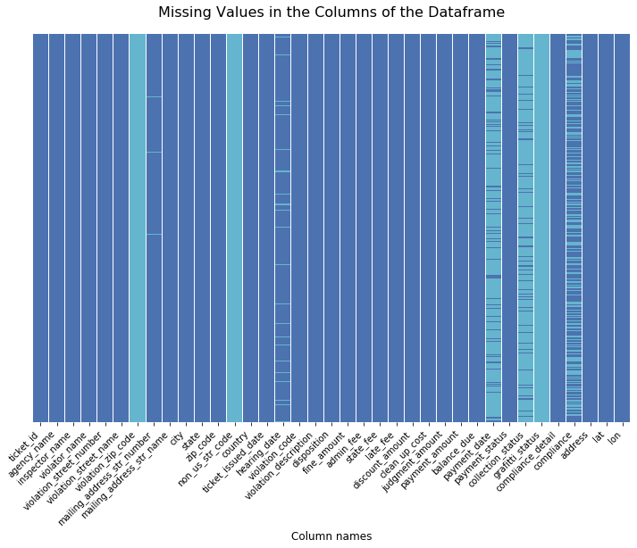

```python
# Visualizing the columns with missing values in the train_coord dataset
missing_values(train_coord,
               figsize_w=12, figsize_h=8,
               ref_font_size=12,
               title="Missing Values in the Columns of the Dataframe",
               title_offset=20)
```

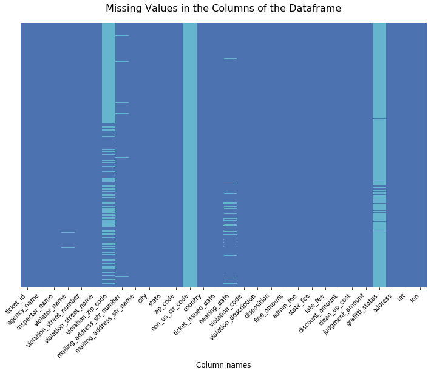

```python
# Visualizing the columns with missing values in the test_coord dataset
missing_values(test_coord,
               figsize_w=12, figsize_h=8,
               ref_font_size=12,
               title="Missing Values in the Columns of the Dataframe",
               title_offset=20)
```

```python
# Cheching the entry with null values for fine amount in the train dataset
train_coord[(train_coord['fine_amount'].isnull())]
```

|  | ticket_id | agency_name | inspector_name | violator_name | violation_street_number | violation_street_name | violation_zip_code | mailing_address_str_number | mailing_address_str_name | city | state | zip_code | non_us_str_code | country | ticket_issued_date | hearing_date | violation_code | violation_description | disposition | fine_amount | admin_fee | state_fee | late_fee | discount_amount | clean_up_cost | judgment_amount | payment_amount | balance_due | payment_date | … |
| --- | --- | --- | --- | --- | --- | --- | --- | --- | --- | --- | --- | --- | --- | --- | --- | --- | --- | --- | --- | --- | --- | --- | --- | --- | --- | --- | --- | --- | --- | --- |
| 81440 | 105992 | Detroit Police Department | MILLER, JAMES | Chinn, Willie | 8919.0 | COYLE | NaN | 8919.0 | Coyle | Detroit | MI | 48228 | NaN | USA | 2007-01-03 13:15:00 | 2007-01-29 13:30:00 | 22-2-88 | Failure of owner to keep property, its sidewal... | Not responsible by Dismissal | NaN | 0.0 | 0.0 | 0.0 | 0.0 | 0.0 | 0.0 | 0.0 | 0.0 | NaN | … |

```python
# Cheching the entries with null values for coordinates in the original dataframe
latlons[(latlons['lat'].isnull())]
```

|  | address | lat | lon |
| --- | --- | --- | --- |
| 4126 | 12038 prairie, Detroit MI 482O4 | NaN | NaN |
| 10466 | 20424 bramford, Detroit MI | NaN | NaN |
| 17293 | 6200 16th st, Detroit MI 482O8 | NaN | NaN |
| 34006 | 8325 joy rd, Detroit MI 482O4 | NaN | NaN |
| 55750 | 1201 elijah mccoy dr, Detroit MI 48208 | NaN | NaN |
| 74721 | 8300 fordyce, Detroit MI | NaN | NaN |
| 100359 | 445 fordyce, Detroit MI | NaN | NaN |

```python
# Cheching the entries with null values for coordinates in the interim dataframe
coordinates[(coordinates['lat'].isnull())]
```

|  | ticket_id | address | lat | lon |
| --- | --- | --- | --- | --- |
| 65578 | 89535 | 20424 bramford, Detroit MI | NaN | NaN |
| 191722 | 223598 | 445 fordyce, Detroit MI | NaN | NaN |
| 245981 | 280256 | 8300 fordyce, Detroit MI | NaN | NaN |
| 270765 | 317124 | 20424 bramford, Detroit MI | NaN | NaN |
| 278656 | 329689 | 8325 joy rd, Detroit MI 482O4 | NaN | NaN |
| 278722 | 329393 | 1201 elijah mccoy dr, Detroit MI 48208 | NaN | NaN |
| 282231 | 333990 | 12038 prairie, Detroit MI 482O4 | NaN | NaN |
| 305706 | 367165 | 6200 16th st, Detroit MI 482O8 | NaN | NaN |

```python
# Cheching the entries with null values for coordinates in the merged dataframe
train_coord[(train_coord['lat'].isnull())].loc[:, ['ticket_id',
                                                   'fine_amount',
                                                   'compliance']]
```

|  | ticket_id | fine_amount | compliance |
| --- | --- | --- | --- |
| 65578 | 89535 | 50.0 | 0.0 |
| 191722 | 223598 | 250.0 | 0.0 |
| 245981 | 280256 | 200.0 | NaN |

```python
# Checking the entries with null violator category
train_modified[train_modified['violator_cat'].isnull()].loc[:, ['ticket_id',
                                                                'lat',
                                                                'lon',
                                                                'fine_amount',
                                                                'compliance']]
```

|  | ticket_id | lat | lon | fine_amount | compliance |
| --- | --- | --- | --- | --- | --- |
| 340 | 19016 | 42.290998 | -83.146649 | 250.0 | 0.0 |
| 2255 | 22774 | 42.350140 | -83.053550 | 250.0 | 0.0 |
| 4399 | 22940 | 42.431201 | -83.217001 | 100.0 | 0.0 |
| 11602 | 30350 | 42.410960 | -82.992645 | 250.0 | 0.0 |
| 11815 | 30494 | 42.420175 | -82.984871 | 250.0 | 0.0 |
| 13870 | 32451 | 42.430415 | -82.943978 | 250.0 | 0.0 |
| 16236 | 35889 | 42.406487 | -83.271646 | 250.0 | 0.0 |
| 16614 | 35256 | 42.407269 | -82.978943 | 250.0 | 0.0 |
| 19085 | 37598 | 42.439907 | -82.967826 | 250.0 | 0.0 |
| 19086 | 37575 | 42.439399 | -83.046440 | 250.0 | NaN |
| 29102 | 49117 | 42.347688 | -83.233365 | 100.0 | 0.0 |
| 33099 | 53765 | 42.373617 | -83.092440 | 200.0 | 1.0 |
| 33438 | 53848 | 42.430045 | -83.141776 | 250.0 | 0.0 |
| 33592 | 54021 | 42.432906 | -83.082883 | 500.0 | NaN |
| 35255 | 55785 | 42.361022 | -83.057846 | 250.0 | 0.0 |
| 36972 | 58693 | 42.419634 | -83.266403 | 250.0 | NaN |
| 42323 | 65243 | 42.417709 | -83.108815 | 250.0 | 0.0 |
| 93396 | 120108 | 42.381917 | -83.003269 | 200.0 | 0.0 |
| 93397 | 120111 | 42.381917 | -83.003269 | 100.0 | 0.0 |
| 95339 | 120988 | 42.365149 | -83.196368 | 250.0 | 0.0 |
| 95340 | 120986 | 42.365149 | -83.196368 | 250.0 | NaN |
| 101672 | 128112 | 42.391866 | -83.128556 | 200.0 | 1.0 |
| 103931 | 130212 | 42.378127 | -82.987887 | 50.0 | 0.0 |
| 142077 | 170956 | 42.392749 | -82.958015 | 250.0 | NaN |
| 174503 | 205826 | 42.405976 | -82.964956 | 250.0 | 1.0 |
| 179984 | 211643 | 42.359551 | -83.234973 | 250.0 | 0.0 |
| 181321 | 213505 | 42.389189 | -83.177479 | 200.0 | 0.0 |
| 183175 | 215018 | 42.392337 | -83.236131 | 200.0 | NaN |
| 188168 | 220772 | 42.355753 | -83.153804 | 50.0 | 0.0 |
| 193349 | 225601 | 42.326968 | -83.124072 | 200.0 | 1.0 |
| 219283 | 252805 | 42.362706 | -83.239181 | 200.0 | NaN |
| 231428 | 266391 | 42.354104 | -83.136789 | 50.0 | NaN |
| 239978 | 274809 | 42.410855 | -83.046409 | 200.0 | 0.0 |
| 243639 | 278444 | 42.352307 | -83.138894 | 50.0 | 0.0 |

#### 5.4.3. Checking outliers

```python
# Checking the entries with wrong dates
wrong_dates = train_modified[(train_modified['year'] == 1938) |
                             (train_modified['year'] == 1963) |
                             (train_modified['year'] == 1988)]
wrong_dates.loc[:, ['ticket_id',
                    'agency_name',
                    'violator_cat',
                    'lat', 'lon',
                    'fine_amount',
                    'compliance', 'compliance_detail']]
```

|  | ticket_id | agency_name | violator_cat | lat | lon | fine_amount | compliance | compliance_detail |
| --- | --- | --- | --- | --- | --- | --- | --- | --- |
| 124436 | 156069 | Detroit Police Department | Only 1 | 42.360132 | -83.115531 | 200.0 | NaN | not responsible by disposition |
| 124437 | 243699 | Detroit Police Department | Only 1 | 42.402947 | -83.167513 | 50.0 | NaN | not responsible by disposition |
| 124438 | 226673 | Detroit Police Department | Only 1 | 42.421124 | -83.115976 | 50.0 | 1.0 | compliant by late payment within 1 month |

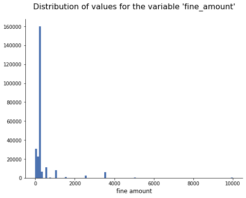

```python
# Plotting an histogram for the variable fine_amount (train dataset)
cust_hist(train_modified['fine_amount'].dropna(),
          figsize_w=8, figsize_h=6,
          title="Distribution of values for the variable 'fine_amount'",
          title_fs=16,
          title_offset=20,
          rem_borders=True,
          x_label='fine amount',
          xlabel_fs=12,
          n_bins=100,
          col_numb=0)
```

#### 5.4.4. Handling outliers and null values

Only basic cleansing is possible at this stage to avoid data leakage since the data has not been split yet into training and validation datasets.

```python
# Eliminating the entries in the train dataset containing data insertion mistakes
# in the ticket_issued_date column
train_cleaned = train_modified[(train_modified['year'] != 1938) &
                               (train_modified['year'] != 1963) &
                               (train_modified['year'] != 1988)]
df_basic_data(train_cleaned)
```

```
Dataframe name: train_cleaned

Dataframe length: 250303

Number of columns: 22

Dataframe's columns names, column data types, amount of distint (non null) values
and amount of null values for each column:
```

|  | Data_Type | Amount_of_Distint_Values | Amount_of_Null_Values |
| --- | --- | --- | --- |
| ticket_id | int64 | 250303 | 0 |
| agency_name | category | 5 | 0 |
| inspector_name | category | 173 | 0 |
| violator_cat | category | 4 | 34 |
| lat | float64 | 78693 | 3 |
| lon | float64 | 87248 | 3 |
| violation_code | category | 235 | 0 |
| disposition | category | 9 | 0 |
| fine_amount | float64 | 43 | 1 |
| late_fee | category | 2 | 0 |
| discount_amount | float64 | 13 | 0 |
| compliance | float64 | 2 | 90424 |
| compliance_detail | category | 10 | 0 |
| violation_street_name | object | 1791 | 0 |
| violation_street_number | int64 | 19175 | 0 |
| address | object | 95597 | 0 |
| discount | category | 2 | 0 |
| discount_percentage | float64 | 4 | 196 |
| year | int64 | 8 | 0 |
| month | int64 | 12 | 0 |
| year_cat | category | 8 | 0 |
| month_cat | category | 12 | 0 |

```python
# Eliminating entries with null values in compliance
train_cleaned = train_cleaned[pd.notnull(train_cleaned['compliance'])]
df_basic_data(train_cleaned)
```

```
Dataframe name: train_cleaned

Dataframe length: 159879

Number of columns: 22

Dataframe's columns names, column data types, amount of distint (non null) values
and amount of null values for each column:
```

|  | Data_Type | Amount_of_Distint_Values | Amount_of_Null_Values |
| --- | --- | --- | --- |
| ticket_id | int64 | 159879 | 0 |
| agency_name | category | 5 | 0 |
| inspector_name | category | 159 | 0 |
| violator_cat | category | 4 | 26 |
| lat | float64 | 61559 | 2 |
| lon | float64 | 66839 | 2 |
| violation_code | category | 189 | 0 |
| disposition | category | 4 | 0 |
| fine_amount | float64 | 40 | 0 |
| late_fee | category | 2 | 0 |
| discount_amount | float64 | 13 | 0 |
| compliance | float64 | 2 | 0 |
| compliance_detail | category | 8 | 0 |
| violation_street_name | object | 1716 | 0 |
| violation_street_number | int64 | 18096 | 0 |
| address | object | 71901 | 0 |
| discount | category | 2 | 0 |
| discount_percentage | float64 | 4 | 195 |
| year | int64 | 8 | 0 |
| month | int64 | 12 | 0 |
| year_cat | category | 8 | 0 |
| month_cat | category | 12 | 0 |

```python
# Filling the null values of lat and lon with the mean values in the column
train_cleaned['lat'] = train_cleaned['lat'].fillna(train_cleaned['lat'].mean())
train_cleaned['lon'] = train_cleaned['lon'].fillna(train_cleaned['lon'].mean())
# Filling the null values of violator_cat with the most recurring value of the category
train_cleaned['violator_cat'] = train_cleaned['violator_cat'].\
fillna(train_cleaned['violator_cat'].value_counts().idxmax())

df_basic_data(train_cleaned)
```

```
Dataframe name: train_cleaned

Dataframe length: 159879

Number of columns: 22

Dataframe's columns names, column data types, amount of distint (non null) values
and amount of null values for each column:
```

|  | Data_Type | Amount_of_Distint_Values | Amount_of_Null_Values |
| --- | --- | --- | --- |
| ticket_id | int64 | 159879 | 0 |
| agency_name | category | 5 | 0 |
| inspector_name | category | 159 | 0 |
| violator_cat | category | 4 | 0 |
| lat | float64 | 61560 | 0 |
| lon | float64 | 66840 | 0 |
| violation_code | category | 189 | 0 |
| disposition | category | 4 | 0 |
| fine_amount | float64 | 40 | 0 |
| late_fee | category | 2 | 0 |
| discount_amount | float64 | 13 | 0 |
| compliance | float64 | 2 | 0 |
| compliance_detail | category | 8 | 0 |
| violation_street_name | object | 1716 | 0 |
| violation_street_number | int64 | 18096 | 0 |
| address | object | 71901 | 0 |
| discount | category | 2 | 0 |
| discount_percentage | float64 | 4 | 195 |
| year | int64 | 8 | 0 |
| month | int64 | 12 | 0 |
| year_cat | category | 8 | 0 |
| month_cat | category | 12 | 0 |

```python
# Converting the target value into integer type
train_cleaned['compliance'] = train_cleaned['compliance'].astype('int')
df_basic_data(train_cleaned)
```

```
Dataframe name: train_cleaned

Dataframe length: 159879

Number of columns: 22

Dataframe's columns names, column data types, amount of distint (non null) values
and amount of null values for each column:
```

|  | Data_Type | Amount_of_Distint_Values | Amount_of_Null_Values |
| --- | --- | --- | --- |
| ticket_id | int64 | 159879 | 0 |
| agency_name | category | 5 | 0 |
| inspector_name | category | 159 | 0 |
| violator_cat | category | 4 | 0 |
| lat | float64 | 61560 | 0 |
| lon | float64 | 66840 | 0 |
| violation_code | category | 189 | 0 |
| disposition | category | 4 | 0 |
| fine_amount | float64 | 40 | 0 |
| late_fee | category | 2 | 0 |
| discount_amount | float64 | 13 | 0 |
| compliance | int64 | 2 | 0 |
| compliance_detail | category | 8 | 0 |
| violation_street_name | object | 1716 | 0 |
| violation_street_number | int64 | 18096 | 0 |
| address | object | 71901 | 0 |
| discount | category | 2 | 0 |
| discount_percentage | float64 | 4 | 195 |
| year | int64 | 8 | 0 |
| month | int64 | 12 | 0 |
| year_cat | category | 8 | 0 |
| month_cat | category | 12 | 0 |

#### 5.4.5. Verifying there are no miss-typed addresses

```python
# THIS CELL TAKES ABOUT 30 MINUTES TO RUN!

import datetime as dt

# Initializing data to provide consolle feedback
start_time = dt.datetime.now()
print ("Script start time:", start_time)
total = len(train_cleaned)
feedb_int = 10000

# Fetching the street number
numbers = train_cleaned['violation_street_number']
# Fetching the street name in lower letters
streets = train_cleaned['violation_street_name'].str.lower()

# Initializing an empty dataframe
corr_addr = pd.DataFrame()
# Iterating through all the rows of the train_cleaned dataframe
for i in list(range(total)):
    # Fetching the cell in the address column
    cell = train_cleaned.loc[train_cleaned.index[i], ['address']]
    # Checking if the cell contains the number and the street name separated
    # by a space and followed by a comma
    # Then storing the result in a boolean variable in a Series of lenght 1
    number = numbers.loc[numbers.index[i]].astype('str')
    street = streets.loc[streets.index[i]]
    correct = cell.str.contains(number + " " + street + ",")
    # Adding the corresponding ticket_id to a Series
    corr_addr.at[i, 'ticket_id'] = train_cleaned.loc[train_cleaned.index[i],
                                                     ['ticket_id']][0]
    # Adding the value of the lenght 1 Series above to the Series
    corr_addr.at[i, 'correct_address'] = correct[0]
    # Checking if it it time to update consolle feebback
    if i != 0 and i%feedb_int == 0:
        print(i, "entries handled at", dt.datetime.now())

# Converting the column 'ticket_id' into integer
corr_addr['ticket_id'] = corr_addr['ticket_id'].astype('int')

# Providing consolle feedback
end_time = dt.datetime.now()
print ("Script end time:", end_time)
print ("Script duration:", end_time - start_time)
```

```
Script start time: 2020-02-21 16:09:56.019806
10000 entries handled at 2020-02-21 16:10:59.617919
20000 entries handled at 2020-02-21 16:12:01.884697
30000 entries handled at 2020-02-21 16:13:13.210809
40000 entries handled at 2020-02-21 16:14:28.021130
50000 entries handled at 2020-02-21 16:15:54.269824
60000 entries handled at 2020-02-21 16:17:28.145539
70000 entries handled at 2020-02-21 16:19:16.559808
80000 entries handled at 2020-02-21 16:20:54.752766
90000 entries handled at 2020-02-21 16:22:38.243899
100000 entries handled at 2020-02-21 16:24:34.090596
110000 entries handled at 2020-02-21 16:26:43.603333
120000 entries handled at 2020-02-21 16:29:00.490706
130000 entries handled at 2020-02-21 16:31:23.139752
140000 entries handled at 2020-02-21 16:33:44.325175
150000 entries handled at 2020-02-21 16:36:08.527377
Script end time: 2020-02-21 16:38:36.448062
Script duration: 0:28:40.428256
```

```python
df_basic_data(corr_addr)
```

```
Dataframe name: corr_addr

Dataframe length: 159879

Number of columns: 2

Dataframe's columns names, column data types, amount of distint (non null) values
and amount of null values for each column:
```

|  | Data_Type | Amount_of_Distint_Values | Amount_of_Null_Values |
| --- | --- | --- | --- |
| ticket_id | int64 | 159879 | 0 |
| correct_address | object | 1 | 0 |

```python
corr_addr.head()
```

|  | ticket_id | correct_address |
| --- | --- | --- |
| 0 | 22056 | True |
| 1 | 27586 | True |
| 2 | 22046 | True |
| 3 | 18738 | True |
| 4 | 18735 | True |

```python
# Checking how many addresses are incorrectly typed in the address column
# (incorrectly types addresses gives False)
corr_addr['correct_address'].value_counts()
```

```
True    159879
Name: correct_address, dtype: int64
```

### 5.5. Exploratory Data Analysis

#### 5.5.1. Summary

This analysis confirms the choice of the selected variables and provides useful insights for the selecting the predictions models to be tested.

The maximum and minimum values of the numerical variables differ quite a lot for the different variables, so for all those methods that require feature normalization, it is important to process the data accordingly.

**92.75%** of the violators are **not compliant**. This means that they have not paid by a month after the hearing date. Among compliant violators, 54.32% pays after the hearing date, 33.46% pays by the hearing date and 8.55% pays before the hearing date. Among non-compliant violators 87.18% does not pay at all and 12.82% pays later than one month after the hearing date.

**Most of the fines** are **below 500**. The distribution of values is strongly skewed to the right with some **outlier around 10000**.

About **disposition**: 89.73% of the no compliant violators are classified as "responsible by default". The compliant violators are more evenly distributed also among the categories of "responsible by admission" and "responsible by determination".

The percentage of non-complaint cases within each **violator category** grows steadily by moving to categories that contain more frequent violators.

Over 90% of the entries related to responsible violators have a **late fee**. Among the complaint violators, almost half have had a late fee (therefore, almost half of them has paid within one month of the hearing date). Among non-compliant violators, most of them have had the fee.

A **discount** has been applied only to 0.74% of the cases related to responsible violators. This percentage increases to 9.68% by considering only the compliant violators.

There are few **locations** which are far from the district. Most of those locations are related to non-compliant violators.

#### 5.5.2. Data Preparation

```python
# Splitting the data into two dataframes based on the value of the variable compliance
train_cl_compl = train_cleaned[train_cleaned['compliance']==1]
train_cl_no_compl = train_cleaned[train_cleaned['compliance']==0]
```

#### 5.5.3. Checking the extreme values of the numerical variables of interest

```python
# Checking the maximum values of the numerical variables of interest
train_cleaned.loc[:,['year',
                     'month',
                     'lat',
                     'lon',
                     'fine_amount',
                     'compliance',]].max()
```

```
year            2011.000000
month             12.000000
lat               44.785389
lon              -82.512936
fine_amount    10000.000000
compliance         1.000000
dtype: float64
```

```python
# Checking the minimum values of the numerical variables of interest
train_cleaned.loc[:,['year',
                     'month',
                     'lat',
                     'lon',
                     'fine_amount',
                     'compliance',]].min()
```

```
year           2004.000000
month             1.000000
lat              42.145257
lon             -84.403766
fine_amount       0.000000
compliance        0.000000
dtype: float64
```

#### 5.5.4. Discount

All compliant violators that have paid before the hearing date have had a discount. However, not all the violators that have had a discount are early payers.

The 196 entries with null discount percentage in `train_modified` data set correspond to the 195 entries with zero *fine_amount* and to the entry with null *fine_amount*. The entries with zero *fine_amount* are all related to compliant violators whose fine has been waived.

For those who have had the discount, the amount varies between 10 and 12%. Therefore, the variable *discount_percentage* will not be likely a useful predictor.

```python
# Extracting compliant violators that have paid before the hearing date
# and checking the amount of entries
early_payers = train_modified[train_modified['compliance_detail'] == \
                              "compliant by early payment"]
print("Amount of compliant violators that have paid before the hearing date:",
      len(early_payers))
print("")
# Extracting violators that have a discount and checking the amount of entries
discounted_payers = train_modified[train_modified['discount'] == "Discount"]
print("Amount of violators that have had a discount:",
      len(discounted_payers))
print("")
# Checking the occurrences of the variable compliance detail for violators
# that have had a discount
print("Compliance details of payers who have had a discount:")
print(discounted_payers['compliance_detail'].value_counts().to_string())
```

```
Amount of compliant violators that have paid before the hearing date: 992

Amount of violators that have had a discount: 1180

Compliance details of payers who have had a discount:
compliant by early payment                         992
compliant by payment with no scheduled hearing     125
non-compliant by late payment more than 1 month     57
compliant by late payment within 1 month             3
compliant by payment on unknown date                 2
compliant by on-time payment                         1
not responsible by pending judgment disposition      0
not responsible by disposition                       0
non-compliant by no payment                          0
compliant by no fine                                 0
```

```python
# Checking the amount of entries with zero fine amount
print("Amount of entries with zero fine amount:")
len(train_modified[train_modified['fine_amount'] == 0])
```

```
Amount of entries with zero fine amount:
```

```
195
```

```python
print("Occurrency of disposition values for the entries with zero fine amount:\n{}".\
      format(train_modified[train_modified['fine_amount'] == 0]['disposition'].\
      value_counts().to_string()))
print("")
print("Occurrency of compliance_detail values for the entries with zero fine amount:\n{}".\
      format(train_modified[train_modified['fine_amount'] == 0]['compliance_detail'].\
      value_counts().to_string()))
```

```
Occurrency of disposition values for the entries with zero fine amount:
Responsible (Fine Waived) by Deter    195
SET-ASIDE (PENDING JUDGMENT)            0
Responsible by Determination            0
Responsible by Default                  0
Responsible by Admission                0
PENDING JUDGMENT                        0
Not responsible by Dismissal            0
Not responsible by Determination        0
Not responsible by City Dismissal       0

Occurrency of compliance_detail values for the entries with zero fine amount:
compliant by no fine                               195
not responsible by pending judgment disposition      0
not responsible by disposition                       0
non-compliant by no payment                          0
non-compliant by late payment more than 1 month      0
compliant by payment with no scheduled hearing       0
compliant by payment on unknown date                 0
compliant by on-time payment                         0
compliant by late payment within 1 month             0
compliant by early payment                           0
```

```python
# Checking the occurrence of different discount percentages
train_modified['discount_percentage'].value_counts()
print("Occurrence of different discount percentages:\n{}".\
      format(train_modified['discount_percentage'].value_counts().to_string()))
```

```
Occurrence of different discount percentages:
0.0     248930
10.0      1160
12.0        19
10.4         1
```

#### 5.5.5. Late fee

Among the responsible violators that have no late fee, there are both compliant and non-compliant violators. This ensures that this variable is not leading to data leakage when fitting a prediction model. The non-complaint violators have not paid at all or have paid more than one month after the hearing date (in this case they should have had the late fee). The compliant violators have either paid in full or no payment was applicable.

**Responsible violators with no late fee**

```python
# Responsible violators
resp = train[pd.notnull(train['compliance'])]
# Extracting responsible violators that have no late fee and checking the amount of entries
no_late_fee = resp[resp['late_fee'] == 0]
print("Amount of responsible violators that have no late fee: {}".format(len(no_late_fee)))
# Checking of many of those entries correspond to compliant violators
print("Responsible violators with no late fee divided based on their compliance:\n{}".\
      format(no_late_fee['compliance'].value_counts().to_string()))
```

```
Amount of responsible violators that have no late fee: 15458
Responsible violators with no late fee divided based on their compliance:
0.0    9856
1.0    5602
```

```python
# Extracting responsible violators that have no late fee and are non compliant
print("Responsible violators that have no late fee and are non compliant\n")
print("Division by compliance detail:\n{}".\
      format(no_late_fee[no_late_fee['compliance'] == 0.0]['compliance_detail'].\
                                                      value_counts().to_string()))

print("")
print("Division by payment status:\n{}".\
      format(no_late_fee[no_late_fee['compliance'] == 0.0]['payment_status'].\
                                                      value_counts().to_string()))
```

```
Responsible violators that have no late fee and are non compliant

Division by compliance detail:
non-compliant by no payment                        9182
non-compliant by late payment more than 1 month     674

Division by payment status:
PARTIAL PAYMENT APPLIED    9182
PAID IN FULL                674
```

```python
# Extracting responsible violators that have no late fee and are compliant
print("Responsible violators that have no late fee and are compliant\n")
print("Division by compliance detail:\n{}".\
      format(no_late_fee[no_late_fee['compliance'] == 1.0]['compliance_detail'].\
                                                      value_counts().to_string()))
print("")
print("Division by payment status:\n{}".\
      format(no_late_fee[no_late_fee['compliance'] == 1.0]['payment_status'].\
                                                      value_counts().to_string()))
```

```
Responsible violators that have no late fee and are compliant

Division by compliance detail:
compliant by on-time payment                      3880
compliant by early payment                         992
compliant by late payment within 1 month           395
compliant by no fine                               195
compliant by payment with no scheduled hearing     137
compliant by payment on unknown date                 3

Division by payment status:
PAID IN FULL          5418
NO PAYMENT APPLIED     184
```

**Responsible violators with late fee**

```python
# Extracting responsible violators that have late fee and checking the amount of entries
late_fee = resp[resp['late_fee'] != 0]
print("Amount of responsible violators that have late fee:{}".format(len(late_fee)))
# Checking of many of those entries correspond to compliant violators
print("Responsible violators with late fee divided based on their compliance:\n{}".\
      format(late_fee['compliance'].value_counts().to_string()))
```

```
Amount of responsible violators that have late fee:144422
Responsible violators with late fee divided based on their compliance:
0.0    138427
1.0      5995
```

```python
# Extracting responsible violators that have late fee and are non compliant
print("Responsible violators that have late fee and are non compliant\n")
print("Division by compliance detail:\n{}".format(late_fee[late_fee['compliance'] == 0.0]\
      ['compliance_detail'].value_counts().to_string()))

print("")
print("Division by payment status:\n{}".format(late_fee[late_fee['compliance'] == 0.0]\
      ['payment_status'].value_counts().to_string()))
```

```
Responsible violators that have late fee and are non compliant

Division by compliance detail:
non-compliant by no payment                        120085
non-compliant by late payment more than 1 month     18342

Division by payment status:
NO PAYMENT APPLIED    120085
PAID IN FULL           18342
```

```python
# Extracting responsible violators that have late fee and are compliant
print("Responsible violators that have late fee and are compliant\n")
print("Division by compliance detail:\n{}".format(late_fee[late_fee['compliance'] == 1.0]\
      ['compliance_detail'].value_counts().to_string()))
print("")
print("Division by payment status:\n{}".format(late_fee[late_fee['compliance'] == 1.0]\
      ['payment_status'].value_counts().to_string()))
```

```
Responsible violators that have late fee and are compliant

Division by compliance detail:
compliant by late payment within 1 month          5905
compliant by payment on unknown date                66
compliant by payment with no scheduled hearing      24

Division by payment status:
PAID IN FULL    5995
```

**"NO PAYMENT APPLIED" cases**

All responsible compliant violators that have "NO PAYMENT APPLIED" in payment_status have "compliant by no fine" in the compliance_detail.

All responsible non-compliant violators that have "NO PAYMENT APPLIED" in payment_status have "non-compliant by no payment" in the compliance_detail.

```python
# Responsible compliant violators
resp_c = resp [resp ['compliance'] == 1.0]
# Responsible compliant violators with "NO PAYMENT APPLIED"
resp_c[resp_c['payment_status'] == "NO PAYMENT APPLIED"]['compliance_detail'].\
                                   value_counts()
```

```
compliant by no fine    184
Name: compliance_detail, dtype: int64
```

```python
# Responsible non compliant violators
resp_noc = resp [resp ['compliance'] == 0.0]
resp_noc[resp_noc['payment_status'] == "NO PAYMENT APPLIED"]['compliance_detail'].\
                                       value_counts()
```

```
non-compliant by no payment    120085
Name: compliance_detail, dtype: int64
```

#### 5.5.6. Data Visualization

##### 5.5.6.1. Numerical variables

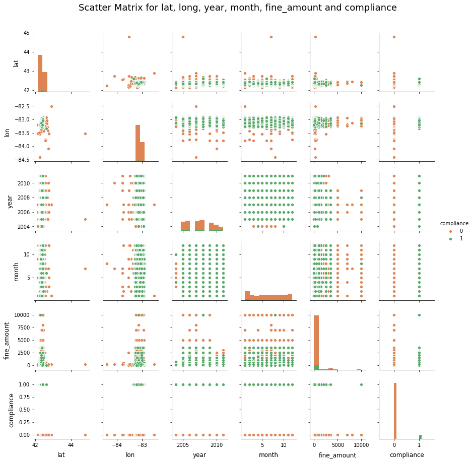

```python
# Creating a pairplot with the relevant numerical variables
# (it takes some time to visualize)
cust_pairplot(train_cleaned.loc[:,['lat',
                                   'lon',
                                   'year',
                                   'month',
                                   'fine_amount',
                                   'compliance']],
              target='compliance',
              s=2,
              font_size=12,
              title="Scatter Matrix for lat, long, year, month, fine_amount and compliance",
              title_offset=1.05)
```

##### 5.5.6.2. Target value: Compliance

```python
# Grouping the entries per category value of the variable compliance
compliance_c = train_cleaned['compliance'].value_counts()
# Finding out the percentage values
compliance_c_perc = train_cleaned['compliance'].value_counts(normalize=True)*100
print("Amount of compliane and non compliant entries in the cleaned dataset\n"\
      "(1 means compliance):\n{}".format(compliance_c.to_string()))
```

```
Amount of compliane and non compliant entries in the cleaned dataset
(1 means compliance):
0    148283
1     11596
```

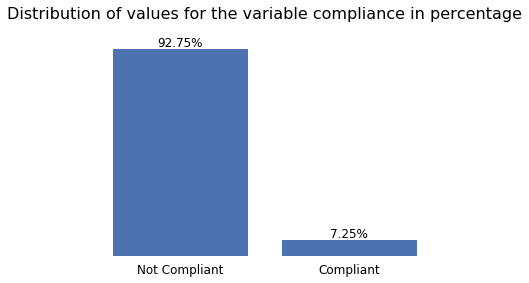

```python
# Plotting the same result as above in a bar plot by showing the percentage values
plot_cust_bar(compliance_c_perc,
              figsize_w=6, figsize_h=4,
              frame=False, grid=False,
              ref_font_size=12,
              title_text="Distribution of values for the variable compliance in percentage",
              title_offset=20,
              color_numb=0,
              categ_labels=True,
              labels=['Not Compliant', 'Compliant'],
              rot=0,
              show_values=True,
              omitted_value=0,
              percent=True,
              value_offset=1,
              visible_digits=2)
```

##### 5.5.6.3. Compliance details

```python
# Grouping the entries per category value of the variable compliance_detail
# separately for compliant and non compliant data sets
# and sorting the values
compl_det_c = train_cl_compl['compliance_detail'].value_counts().sort_values()
compl_det_noc = train_cl_no_compl['compliance_detail'].value_counts().sort_values()

print("Compliant violators:\n")
print(compl_det_c.to_string())
print("")
print("Non compliant violators:\n")
print(compl_det_noc.to_string())
```

```
Compliant violators:

not responsible by pending judgment disposition       0
not responsible by disposition                        0
non-compliant by no payment                           0
non-compliant by late payment more than 1 month       0
compliant by payment on unknown date                 69
compliant by payment with no scheduled hearing      161
compliant by no fine                                195
compliant by early payment                          992
compliant by on-time payment                       3880
compliant by late payment within 1 month           6299

Non compliant violators:

not responsible by pending judgment disposition         0
not responsible by disposition                          0
compliant by payment with no scheduled hearing          0
compliant by payment on unknown date                    0
compliant by on-time payment                            0
compliant by no fine                                    0
compliant by late payment within 1 month                0
compliant by early payment                              0
non-compliant by late payment more than 1 month     19016
non-compliant by no payment                        129267
```

```python
# Finding out the percentage values
compl_det_c_perc = train_cl_compl['compliance_detail'].value_counts(normalize=True)*100
compl_det_noc_perc = train_cl_no_compl['compliance_detail'].\
                     value_counts(normalize=True)*100
```

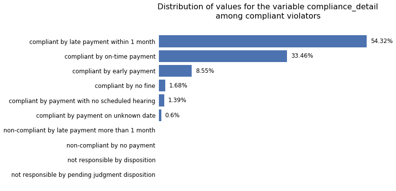

```python
# Plotting the same result as above in a bar plot by showing the percentage values:
# compliant violators
plot_cust_hbar(compl_det_c_perc.sort_values(),
               figsize_w=8, figsize_h=6,
               frame=False, grid=False,
               ref_font_size=12,
               title_text="Distribution of values for the variable compliance_detail\n"\
                          "among compliant violators",
               title_offset=20,
               color_numb=0,
               categ_labels=True,
               rot=0,
               show_values=True,
               omitted_value=0,
               percent=True,
               value_offset=1,
               visible_digits=2)
```

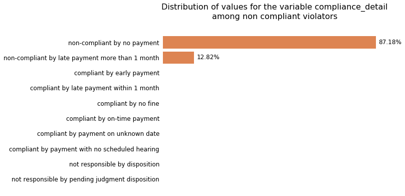

```python
# Plotting the same result as above in a bar plot by showing the percentage values:
# non compliant violators
plot_cust_hbar(compl_det_noc_perc.sort_values(),
              figsize_w=8, figsize_h=6,
              frame=False, grid=False,
              ref_font_size=12,
              title_text="Distribution of values for the variable compliance_detail\n"\
                         "among non compliant violators",
              title_offset=20,
              color_numb=1,
              categ_labels=True,
              rot=0,
              show_values=True,
              omitted_value=0,
              percent=True,
              value_offset=1,
              visible_digits=2)
```

##### 5.5.6.4. Disposition

```python
# Grouping the entries per category value of the variable disposition
# and sorting the values
disposition_cat = train_cleaned['disposition'].value_counts().sort_values()
disposition_cat_c = train_cl_compl['disposition'].value_counts().sort_values()
disposition_cat_noc = train_cl_no_compl['disposition'].value_counts().sort_values()
# Finding out the percentage values
disposition_cat_perc = train_cleaned['disposition'].value_counts(normalize=True)*100
disposition_cat_c_perc = train_cl_compl['disposition'].value_counts(normalize=True)*100
disposition_cat_noc_perc = train_cl_no_compl['disposition'].\
                           value_counts(normalize=True)*100

print("Compliant violators:\n")
print(disposition_cat_c.to_string())
print("")
print("Non compliant violators:\n")
print(disposition_cat_noc.to_string())
```

```
Compliant violators:

SET-ASIDE (PENDING JUDGMENT)             0
PENDING JUDGMENT                         0
Not responsible by Dismissal             0
Not responsible by Determination         0
Not responsible by City Dismissal        0
Responsible (Fine Waived) by Deter     195
Responsible by Determination          2349
Responsible by Admission              3768
Responsible by Default                5284

Non compliant violators:

SET-ASIDE (PENDING JUDGMENT)               0
Responsible (Fine Waived) by Deter         0
PENDING JUDGMENT                           0
Not responsible by Dismissal               0
Not responsible by Determination           0
Not responsible by City Dismissal          0
Responsible by Determination            5295
Responsible by Admission                9933
Responsible by Default                133055
```

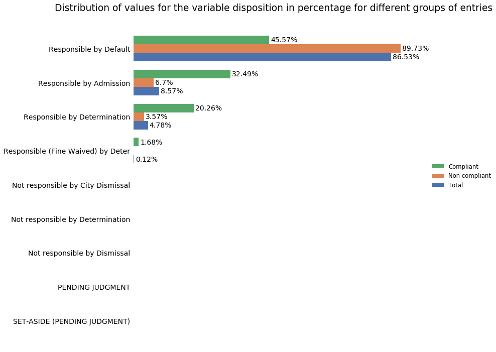

```python
# Plotting the same result as above in a bar plot by showing the percentage values
plot_side_by_side_hbar(disposition_cat_c_perc.sort_values(),
                       disposition_cat_noc_perc.sort_values(),
                       disposition_cat_perc.sort_values(),
                       figsize_w=10, figsize_h=12,
                       frame=False, grid=False,
                       ref_font_size=14,
                       title_text="Distribution of values for the variable disposition "\
                                  "in percentage for different groups of entries",
                       title_offset=20,
                       color_numb1=2,
                       color_numb2=1,
                       color_numb3=0,
                       categ_labels=True,
                       rot=0,
                       show_values=True,
                       omitted_value=0,
                       percent=True,
                       value_offset=0.5,
                       visible_digits=2,
                       leg_list=["Compliant", "Non compliant", "Total"],
                       leg_loc=5)
```

##### 5.5.6.5. Agency name

```python
# Grouping the entries per category value of the variable agency_name
# and sorting the values
agency_name_cat = train_cleaned['agency_name'].value_counts().sort_values()
agency_name_cat_c = train_cl_compl['agency_name'].value_counts().sort_values()
agency_name_cat_noc = train_cl_no_compl['agency_name'].value_counts().sort_values()
# Finding out the percentage values
agency_name_cat_perc = train_cleaned['agency_name'].value_counts(normalize=True)*100
print("Amount of tickets to responsible violators for each agency:\n")
print(agency_name_cat.to_string())
```

```
Amount of tickets to responsible violators for each agency:

Neighborhood City Halls                               1
Detroit Police Department                          4463
Health Department                                  7107
Department of Public Works                        52445
Buildings, Safety Engineering & Env Department    95863
```

```python
print("Compliant violators:\n")
print(agency_name_cat_c.to_string())
print("")
print("Non compliant violators:\n")
print(agency_name_cat_noc.to_string())
```

```
Compliant violators:

Neighborhood City Halls                              0
Health Department                                  468
Detroit Police Department                          587
Department of Public Works                        4718
Buildings, Safety Engineering & Env Department    5823

Non compliant violators:

Neighborhood City Halls                               1
Detroit Police Department                          3876
Health Department                                  6639
Department of Public Works                        47727
Buildings, Safety Engineering & Env Department    90040
```

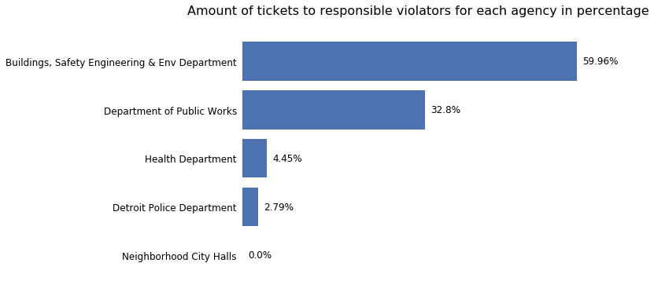

```python
# Plotting the amount of tickets to responsible violators for each agency in percentage
plot_cust_hbar(agency_name_cat_perc.sort_values(),
               figsize_w=8, figsize_h=6,
               frame=False, grid=False,
               ref_font_size=12,
               title_text="Amount of tickets to responsible violators for each agency "\
                          "in percentage",
               title_offset=20,
               color_numb=0,
               categ_labels=True,
               labels=None,
               rot=0,
               show_values=True,
               omitted_value=0,
               percent=True,
               value_offset=1,
               visible_digits=2)
```

```python
# Calling the function cat_perc_split to provide the percentage of entries
# of the category agency_name, separately for each of the two values of
# the variable compliance (the positive case is given first)
# (the output of the cell is hidden with the ";")
print("The category is the Agency name\n"\
      "The positive cases are the compliant cases\n")
agency_name_cat_split = cat_perc_split(train_cleaned, 'agency_name', 'compliance',
                                       printout=True)
agency_name_cat_split;
```

```
The category is the Agency name
The positive cases are the compliant cases

Category: Buildings, Safety Engineering & Env Department
 Negative cases in percentage: 93.92570647695149
 Positive cases in percentage: 6.07429352304851

Category: Health Department
 Negative cases in percentage: 93.41494301392993
 Positive cases in percentage: 6.585056986070072

Category: Department of Public Works
 Negative cases in percentage: 91.0039088568977
 Positive cases in percentage: 8.996091143102305

Category: Detroit Police Department
 Negative cases in percentage: 86.84741205467175
 Positive cases in percentage: 13.15258794532825

Category: Neighborhood City Halls
 Negative cases in percentage: 100.0
 Positive cases in percentage: 0.0
```

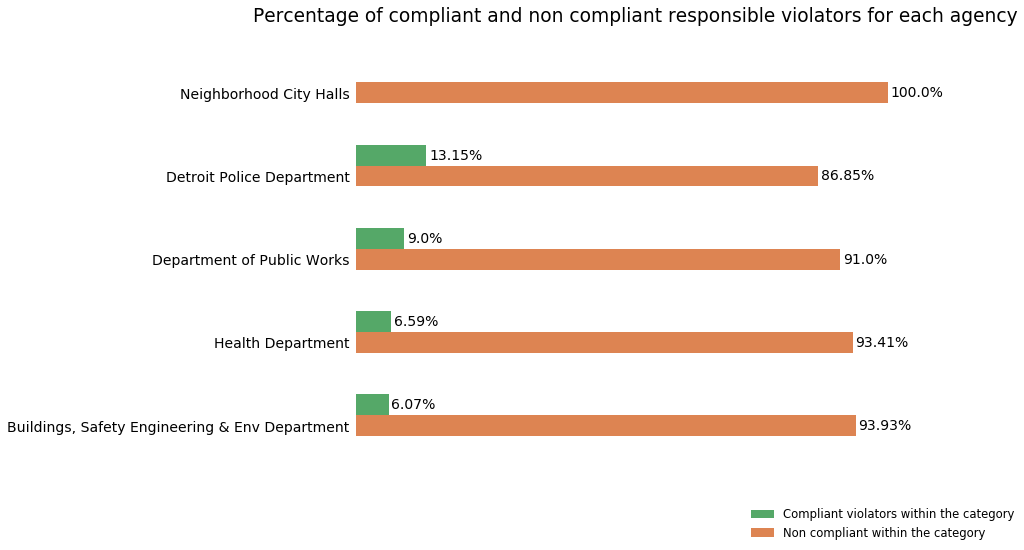

```python
# Plotting the percentage of compliant and non compliant responsible violators
# for each agency
plot_side_by_side_hbar(agency_name_cat_split[0],
                       agency_name_cat_split[1],
                       [0, 0, 0, 0, 0],
                       figsize_w=10, figsize_h=8,
                       frame=False, grid=False,
                       ref_font_size=14,
                       title_text="Percentage of compliant and non compliant responsible "\
                                  "violators for each agency",
                       title_offset=20,
                       color_numb1=2,
                       color_numb2=1,
                       color_numb3=0,
                       categ_labels=True,
                       rot=0,
                       show_values=True,
                       omitted_value=0,
                       percent=True,
                       value_offset=0.5,
                       visible_digits=2,
                       leg_list=["Compliant violators within the category",
                                 "Non compliant within the category"],
                       leg_loc=4)
```

##### 5.5.6.6. Violator category

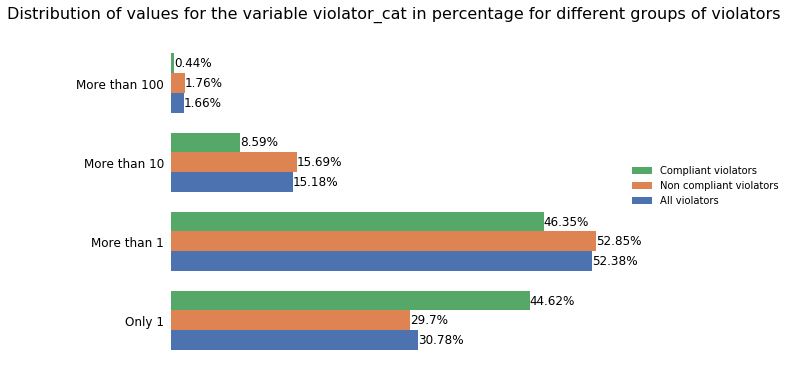

```python
# Plotting the distribution of values of the variable violator_cat
# separately for compliant violators, for non compliant violators and for all violators
data1 = train_cl_compl['violator_cat'].value_counts(normalize=True)*100
data2 = train_cl_no_compl['violator_cat'].value_counts(normalize=True)*100
data3 = train_cleaned['violator_cat'].value_counts(normalize=True)*100
plot_side_by_side_hbar(data1.sort_index(),
                       data2.sort_index(),
                       data3.sort_index(),
                       figsize_w=8, figsize_h=6,
                       frame=False, grid=False,
                       ref_font_size=12,
                       title_text="Distribution of values for the variable violator_cat "\
                                  "in percentage for different groups of violators",
                       title_offset=20,
                       color_numb1=2,
                       color_numb2=1,
                       color_numb3=0,
                       categ_labels=True,
                       labels=None,
                       rot=0,
                       show_values=True,
                       omitted_value=0,
                       percent=True,
                       value_offset=0,
                       visible_digits=2,
                       leg_list=["Compliant violators",
                                 "Non compliant violators",
                                 "All violators"],
                       leg_loc=5)
```

```python
# Grouping the entries per category value of the variable violator_cat
# and sorting the values
violator_categ = train_cleaned['violator_cat'].value_counts()
violator_categ_c = train_cl_compl['violator_cat'].value_counts()
violator_categ_noc = train_cl_no_compl['violator_cat'].value_counts()
# Finding out the percentage values
violator_categ_perc = train_cleaned['violator_cat'].value_counts(normalize=True)*100
violator_categ_c_perc = train_cl_compl['violator_cat'].value_counts(normalize=True)*100
violator_categ_noc_perc = train_cl_no_compl['violator_cat'].value_counts(normalize=True)*100
print("Amount of responsible violators per violator category:\n{}".\
      format(violator_categ.to_string()))
```

```
Amount of responsible violators per violator category:
More than 1      83748
Only 1           49213
More than 10     24263
More than 100     2655
```

```python
print("Compliant violators:\n")
print(violator_categ_c.to_string())
print("")
print("Non compliant violators:\n")
print(violator_categ_noc.to_string())
```

```
Compliant violators:

More than 1      5375
Only 1           5174
More than 10      996
More than 100      51

Non compliant violators:

More than 1      78373
Only 1           44039
More than 10     23267
More than 100     2604
```

```python
# Calling the function cat_perc_split to provide the percentage of entries
# of the category violator_cat, separately for each of the two values of
# the variable compliance (the positive case is given first)
# (the output of the cell is hidden with the ";")
print("The category is the violator category\n"\
      "The positive cases are the compliant cases\n")
violator_cat_split = cat_perc_split(train_cleaned, 'violator_cat', 'compliance',
                                    printout=True)
violator_cat_split;
```

```
The category is the violator category
The positive cases are the compliant cases

Category: Only 1
 Negative cases in percentage: 89.48651779001483
 Positive cases in percentage: 10.51348220998517

Category: More than 1
 Negative cases in percentage: 93.58193628504561
 Positive cases in percentage: 6.4180637149543855

Category: More than 10
 Negative cases in percentage: 95.89498413221777
 Positive cases in percentage: 4.105015867782228

Category: More than 100
 Negative cases in percentage: 98.07909604519774
 Positive cases in percentage: 1.920903954802256
```

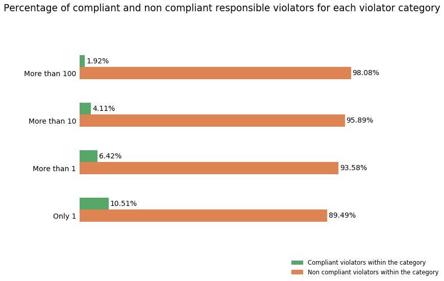

```python
# Plotting the percentage of compliant and non compliant violators
# for each agency
plot_side_by_side_hbar(violator_cat_split[0].sort_index(),
                       violator_cat_split[1].sort_index(),
                       [0, 0, 0, 0, 0],
                       figsize_w=10, figsize_h=8,
                       frame=False, grid=False,
                       ref_font_size=14,
                       title_text="Percentage of compliant and non compliant responsible "\
                                  "violators for each violator category",
                       title_offset=20,
                       color_numb1=2,
                       color_numb2=1,
                       color_numb3=0,
                       categ_labels=True,
                       rot=0,
                       show_values=True,
                       omitted_value=0,
                       percent=True,
                       value_offset=0.5,
                       visible_digits=2,
                       leg_list=["Compliant violators within the category",
                                 "Non compliant violators within the category"],
                       leg_loc=4)
```

##### 5.5.6.7. Late fee

```python
# Grouping the entries per category value of the variable late_fee
# and sorting the values
late_fee_cat = train_cleaned['late_fee'].value_counts().sort_values()
late_fee_cat_c = train_cl_compl['late_fee'].value_counts().sort_values()
late_fee_cat_noc = train_cl_no_compl['late_fee'].value_counts().sort_values()
# Finding out the percentage values
late_fee_cat_perc = train_cleaned['late_fee'].value_counts(normalize=True)*100
late_fee_cat_c_perc = train_cl_compl['late_fee'].value_counts(normalize=True)*100
late_fee_cat_noc_perc = train_cl_no_compl['late_fee'].value_counts(normalize=True)*100
print("Amount of responsible violators who have had the late fee:\n{}".\
      format(late_fee_cat.to_string()))
```

```
Amount of responsible violators who have had the late fee:
No fee     15458
Fee       144421
```

```python
print("Compliant violators:\n")
print(late_fee_cat_c.to_string())
print("")
print("Non compliant violators:\n")
print(late_fee_cat_noc.to_string())
```

```
Compliant violators:

No fee    5602
Fee       5994

Non compliant violators:

No fee      9856
Fee       138427
```

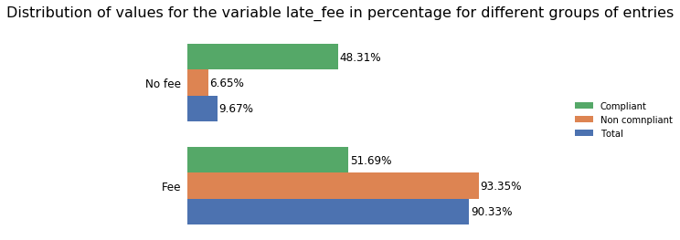

```python
# Plotting the same result as above in a bar plot by showing the percentage values
plot_side_by_side_hbar(late_fee_cat_c_perc,
                       late_fee_cat_noc_perc,
                       late_fee_cat_perc,
                       figsize_w=6, figsize_h=4,
                       frame=False, grid=False,
                       ref_font_size=12,
                       title_text="Distribution of values for the variable late_fee "\
                                  "in percentage for different groups of entries",
                       title_offset=20,
                       color_numb1=2,
                       color_numb2=1,
                       color_numb3=0,
                       categ_labels=True,
                       rot=0,
                       show_values=True,
                       omitted_value=0,
                       percent=True,
                       value_offset=0.5,
                       visible_digits=2,
                       leg_list=["Compliant", "Non comnpliant", "Total"],
                       leg_loc=5)
```

##### 5.5.6.8. Discount

```python
# Grouping the entries per category value of the variable discount
# and sorting the values
discount_cat = train_cleaned['discount'].value_counts().sort_values()
discount_cat_c = train_cl_compl['discount'].value_counts().sort_values()
discount_cat_noc = train_cl_no_compl['discount'].value_counts().sort_values()
# Finding out the percentage values
discount_cat_perc = train_cleaned['discount'].value_counts(normalize=True)*100
discount_cat_c_perc = train_cl_compl['discount'].value_counts(normalize=True)*100
discount_cat_noc_perc = train_cl_no_compl['discount'].value_counts(normalize=True)*100
print("Amount of responsible violators who have had a discount:\n{}".\
      format(discount_cat.to_string()))
```

```
Amount of responsible violators who have had a discount:
Discount         1180
No discount    158699
```

```python
print("Compliant violators:\n")
print(discount_cat_c.to_string())
print("")
print("Non compliant violators:\n")
print(discount_cat_noc.to_string())
```

```
Compliant violators:

Discount        1123
No discount    10473

Non compliant violators:

Discount           57
No discount    148226
```

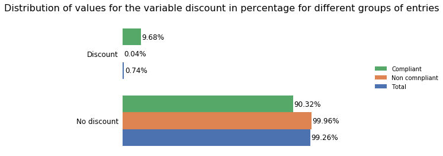

```python
# Plotting the same result as above in a bar plot by showing the percentage values
plot_side_by_side_hbar(discount_cat_c_perc,
                       discount_cat_noc_perc,
                       discount_cat_perc,
                       figsize_w=6, figsize_h=4,
                       frame=False, grid=False,
                       ref_font_size=12,
                       title_text="Distribution of values for the variable discount "\
                                  "in percentage for different groups of entries",
                       title_offset=20,
                       color_numb1=2,
                       color_numb2=1,
                       color_numb3=0,
                       categ_labels=True,
                       rot=0,
                       show_values=True,
                       omitted_value=0,
                       percent=True,
                       value_offset=0.5,
                       visible_digits=2,
                       leg_list=["Compliant", "Non comnpliant", "Total"],
                       leg_loc=5)
```

##### 5.5.6.9. Location

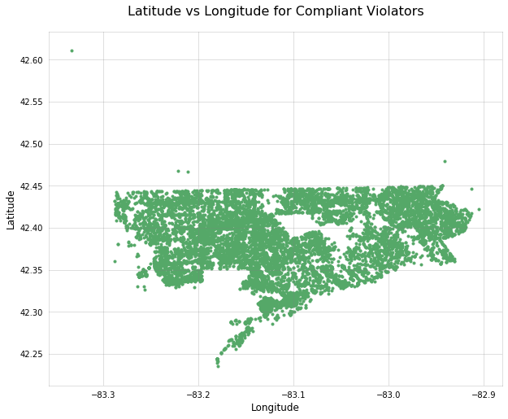

```python
# Plotting lat and long for compliant violators
lat_long_scatter_plot(train_cl_compl['lon'],
                      train_cl_compl['lat'],
                      figsize_w=10, figsize_h=8,
                      ref_font_size=12,
                      title="Latitude vs Longitude for Compliant Violators",
                      title_offset=20,
                      col_numb=2,
                      x_label="Longitude",
                      y_label="Latitude")
```

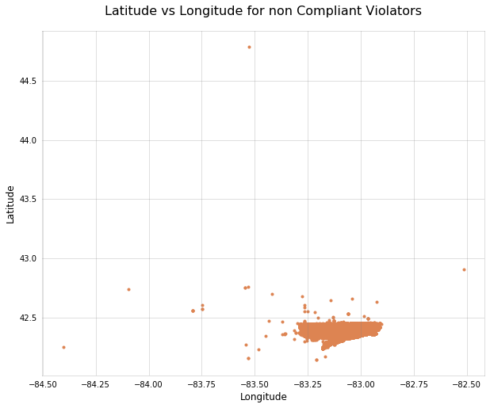

```python
# Plotting lat and long for non compliant violators
lat_long_scatter_plot(train_cl_no_compl['lon'],
                      train_cl_no_compl['lat'],
                      figsize_w=10, figsize_h=8,
                      ref_font_size=12,
                      title="Latitude vs Longitude for non Compliant Violators",
                      title_offset=20,
                      col_numb=1,
                      x_label="Longitude",
                      y_label="Latitude")
```

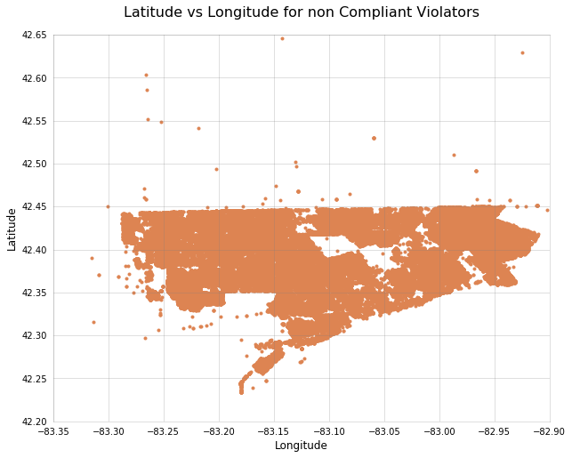

```python
# Plotting lat and long for non compliant violators by zooming in the Detroit area
lat_long_scatter_plot(train_cl_no_compl['lon'],
                      train_cl_no_compl['lat'],
                      figsize_w=10, figsize_h=8,
                      axses_limits=True,
                      xmin=-83.35,
                      xmax=-82.9,
                      ymin=42.20,
                      ymax=42.65,
                      ref_font_size=12,
                      title="Latitude vs Longitude for non Compliant Violators",
                      title_offset=20,
                      col_numb=1,
                      x_label="Longitude",
                      y_label="Latitude")
```

##### 5.5.6.10. Year and month

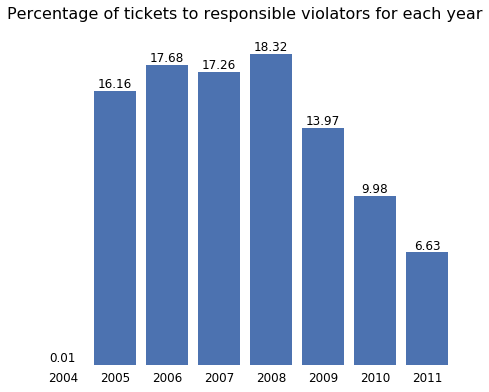

```python
# Plotting the percentage values of the variable year
plot_cust_bar((train_cleaned['year'].value_counts(normalize=True)*100).sort_index(),
               figsize_w=8, figsize_h=6,
               frame=False, grid=False,
               ref_font_size=12,
               title_text="Percentage of tickets to responsible violators for each year",
               title_offset=20,
               color_numb=0,
               categ_labels=True,
               labels=None,
               rot=0,
               show_values=True,
               omitted_value=0,
               percent=False,
               value_offset=0.2,
               visible_digits=2)
```

```python
# Calling the function cat_perc_split to provide the percentage of entries
# of the category year, separately for each of the two values of
# the variable compliance (the positive case is given first)
year_cat_split = cat_perc_split(train_cleaned, 'year_cat', 'compliance', printout=False)
```

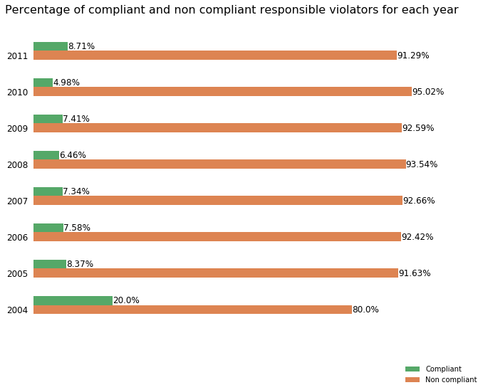

```python
# Plotting the percentage of compliant and non compliant violators
# for each year
plot_side_by_side_hbar(year_cat_split[0].sort_index(),
                       year_cat_split[1].sort_index(),
                       [0, 0, 0, 0, 0],
                       figsize_w=10, figsize_h=8,
                       frame=False, grid=False,
                       ref_font_size=12,
                       title_text="Percentage of compliant and non compliant responsible "\
                                  "violators for each year",
                       title_offset=20,
                       color_numb1=2,
                       color_numb2=1,
                       color_numb3=0,
                       categ_labels=True,
                       labels=None,
                       rot=0,
                       show_values=True,
                       omitted_value=0,
                       percent=True,
                       value_offset=0,
                       visible_digits=2,
                       leg_list=["Compliant", "Non compliant"],
                       leg_loc=4)
```

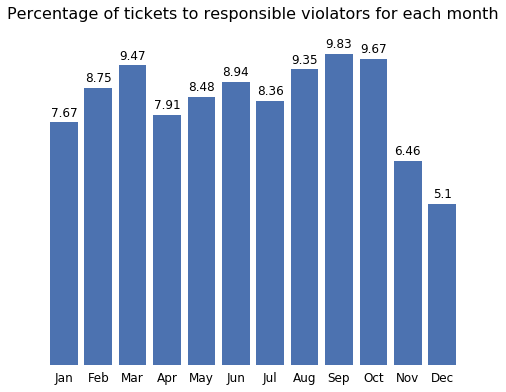

```python
# Plotting the percentage values of the variable month
plot_cust_bar((train_cleaned['month'].value_counts(normalize=True)*100).sort_index(),
               figsize_w=8, figsize_h=6,
               frame=False, grid=False,
               ref_font_size=12,
               title_text="Percentage of tickets to responsible violators for each month",
               title_offset=20,
               color_numb=0,
               categ_labels=True,
               labels=['Jan', 'Feb', 'Mar', 'Apr', 'May', 'Jun',
                       'Jul', 'Aug', 'Sep', 'Oct', 'Nov', 'Dec'],
               rot=0,
               show_values=True,
               omitted_value=0,
               percent=False,
               value_offset=0.2,
               visible_digits=2)
```

```python
# Calling the function cat_perc_split to provide the percentage of entries
# of the category month, separately for each of the two values of
# the variable compliance (the positive case is given first)
month_cat_split = cat_perc_split(train_cleaned, 'month_cat', 'compliance', printout=False)
```

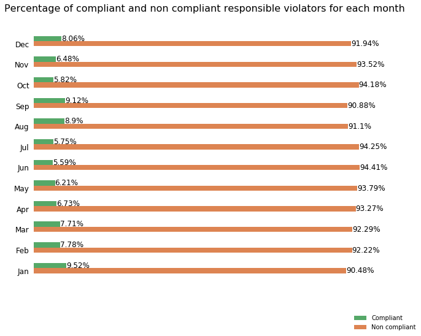

```python
# Plotting the percentage of compliant and non compliant violators
# for each month
plot_side_by_side_hbar(month_cat_split[0].sort_index(),
                       month_cat_split[1].sort_index(),
                       [0, 0, 0, 0, 0],
                       figsize_w=10, figsize_h=8,
                       frame=False, grid=False,
                       ref_font_size=12,
                       title_text="Percentage of compliant and non compliant responsible "\
                                  "violators for each month",
                       title_offset=20,
                       color_numb1=2,
                       color_numb2=1,
                       color_numb3=0,
                       categ_labels=True,
                       labels=['Jan', 'Feb', 'Mar', 'Apr', 'May', 'Jun',
                               'Jul', 'Aug', 'Sep', 'Oct', 'Nov', 'Dec'],
                       rot=0,
                       show_values=True,
                       omitted_value=0,
                       percent=True,
                       value_offset=0,
                       visible_digits=2,
                       leg_list=["Compliant", "Non compliant"],
                       leg_loc=4)
```

### 5.6. Preparing Data for Fitting Prediction Models

#### 5.6.1. Summary

Variables which are not useful predictors because they contain always the same value or because have many zero values or because they would lead to a huge number of variables with many zero values (categorical variables with many distinct values) have been dropped from the data set to be used for model prediction. The same has been done for variables that are not considered to be useful predictors because of their meaning or because they are redundant (for example, text variables whose values map one to one to categorical variables containing codes).

The remaining features have been separated from the target variable.

Modifications have been done to the test dataset in order to align it with the modifications done to the training data set.

Finally, a validation data set has been extracted from the train dataset to be used for model evaluation.

Also, the features have been normalized and stored in separate data sets to be used with models that require feature normalization (like linear models).

#### 5.6.2. Selecting the variables to be used in the training data set

```python
# Selecting the variables to be used in the training data set
train_selected = train_cleaned.loc[:,['ticket_id',
                                      'agency_name',
                                      'year',
                                      'month',
                                      'violator_cat',
                                      'lat',
                                      'lon',
                                      'disposition',
                                      'fine_amount',
                                      'late_fee',
                                      'discount',
                                      'compliance']]
df_basic_data(train_selected)
```

```
Dataframe name: train_selected

Dataframe length: 159879

Number of columns: 12

Dataframe's columns names, column data types, amount of distint (non null) values
and amount of null values for each column:
```

|  | Data_Type | Amount_of_Distint_Values | Amount_of_Null_Values |
| --- | --- | --- | --- |
| ticket_id | int64 | 159879 | 0 |
| agency_name | category | 5 | 0 |
| year | int64 | 8 | 0 |
| month | int64 | 12 | 0 |
| violator_cat | category | 4 | 0 |
| lat | float64 | 61560 | 0 |
| lon | float64 | 66840 | 0 |
| disposition | category | 4 | 0 |
| fine_amount | float64 | 40 | 0 |
| late_fee | category | 2 | 0 |
| discount | category | 2 | 0 |
| compliance | int64 | 2 | 0 |

```python
# Reordering the categories
train_cleaned['violator_cat'].cat.reorder_categories(['Only 1',
                                                      'More than 1',
                                                      'More than 10',
                                                      'More than 100'],
                                                     inplace=True)
```

#### 5.6.3. Discarded Variables

The variable *ticket_id* is not a useful predictor. The *violator_name* has been refactorized in the *violator_cat* variable.

The *violation_street_number*, *violation_street_name* and *violation_zip_code* are factorized in the *lat and* *lon* variables. Also, the variable *violation_zip_code* is always null in the train dataset. The variables *violation_street_number* and *violation_street_name* have been added temporarily to the modified dataframe to check the correct addresses in the cleansing phase but they have been discarded in the selected dataframe.

Using the *mailing_address_street_name* and the *mailing_address_street_number* would not have added considerable benefits and would have resulted in an excessive high number of categorical variables containing a lot of null entries. The same applies to the *city* and *zip_code*. It has been decided not to use the variable *state* since it would have added additional indicator variables and it would have caused the deletion of a comparable number of entries due to null values.

*non_us_str_code* and *country* would not have been very useful since almost all the violators' mail addresses are in US.

Using *ticket_issued_date* and *hearing_date* to calculate the number of days from the day the ticket has been issued to the day that has been fixed for the hearing would have been very useful. Unfortunately, the variable hearing_date contains a lot of date entry errors (for example, 171 entries have the hearing date before the ticket issued date) and therefore it would not have been a reliable estimator. Also, the variable contains 12491 null values, which would have led to discard about 5% of the training data.

The variables *inspector_name* and *violation_code* could potentially be useful predictors but they are categorical variables containing a big number of categories and therefore they would result in adding of many sparse variables without adding much value.

The variable *violation_description* is basically the textual version of the violation code.

The variables *admin_fee* and *state_fee* are not useful variables since such fees are asked to each responsible violator.

The variable *judgment_amount* does not give any additional information since it is the sum of *fine_amount*, *admin_fee*, *state_fee* and *late_fee*.

The variable *grafitti_status* has all null values except one. The variable *clean_up_cost* is always zero.

```python
# Creating a new variable that contains both violation street name and violation street number
# after eliminating the "decimal part" in violation_street_number
train['violation_street_number'] = train['violation_street_number'].astype(int)
train['violation_address'] = train['violation_street_name'] + ' ' + \
train['violation_street_number'].astype(str)
print("Combinations of violation street name and violation street number:\n{}".\
      format(train['violation_address'].nunique()))
```

```
Combinations of violation street name and violation street number:
95598
```

```python
# Changing the datatype of hearing_date from object to datetime64
hearing_date_dateformat = pd.to_datetime(train['hearing_date'])
ticket_issued_date_dateformat = pd.to_datetime(train['ticket_issued_date'])
# Calculating the number of days between ticket issued date and hearing date
time_to_hearing = hearing_date_dateformat - ticket_issued_date_dateformat
# Extracting the days
days_to_hearing = time_to_hearing.dt.days
# Calculating how many instances have negative differences
negative_diff = days_to_hearing[days_to_hearing < 0].count()
# Calculating how many instances have too high values
too_high_values = days_to_hearing[days_to_hearing > 365].count()
# Calculating how many instances have too small values
too_low_values = days_to_hearing[days_to_hearing < 30].count()
# Visualizing the results
print("There are {} entries where the hearing date is before the ticket issued date.\n\n"\
      "There are {} entries where the hearing date is more than one year "\
      "in the future compared to the ticket issued date.\n\n"\
      "There are {} entries where the hearing date is less than one month "\
      "in the future compared to the ticket issued date.".format(negative_diff,
                                                                 too_high_values,
                                                                 too_low_values))
```

```
There are 171 entries where the hearing date is before the ticket issued date.

There are 1007 entries where the hearing date is more than one year in the future compared to the ticket issued date.

There are 54746 entries where the hearing date is less than one month in the future compared to the ticket issued date.
```

```python
# Checking how many entries have the admin_fee
add_fee = train[train['admin_fee'] == 20]
# Checking how many entries have the state_fee
state_fee = train[train['state_fee'] == 10]
# Checking how many entries have the admin_fee and the state_fee
fee = train[(train['admin_fee'] == 20) & (train['state_fee'] == 10)]
# Checking how many entries which have the fees are related to responsible violators
resp = fee[(fee['compliance'] == 0.0) | (fee['compliance'] == 1.0)]

print("Entries that have the admin fee (fee amount and count):\n{}".\
      format(add_fee['admin_fee'].value_counts().to_string()))
print("")
print("Entries that have the state fee (fee amount and count):\n{}".\
      format(add_fee['state_fee'].value_counts().to_string()))
print("")
print("Entries that have the admin fee and the state fee:\n{}".\
      format(fee['ticket_id'].count()))
print("")
print("Entries that have the fees and are related to responsible violators:\n{}".\
      format(resp['ticket_id'].count()))
```

```
Entries that have the admin fee (fee amount and count):
20.0    159880

Entries that have the state fee (fee amount and count):
10.0    159880

Entries that have the admin fee and the state fee:
159880

Entries that have the fees and are related to responsible violators:
159880
```

```python
# Checking the occurrencies of the different values of the variable clean_up_cost
print("Occurrencies of the values of the variable clean_up_cost (value and count):\n{}".\
      format(train['clean_up_cost'].value_counts().to_string()))
```

```
Occurrencies of the values of the variable clean_up_cost (value and count):
0.0    250306
```

#### 5.6.4. Separating the features and the target variable

```python
# Separating the features and the target variable in the train dataset
train_features = train_selected.drop(columns='compliance')
train_target = train_selected['compliance']
```

```python
df_basic_data(train_features)
```

```
Dataframe name: train_features

Dataframe length: 159879

Number of columns: 11

Dataframe's columns names, column data types, amount of distint (non null) values
and amount of null values for each column:
```

|  | Data_Type | Amount_of_Distint_Values | Amount_of_Null_Values |
| --- | --- | --- | --- |
| ticket_id | int64 | 159879 | 0 |
| agency_name | category | 5 | 0 |
| year | int64 | 8 | 0 |
| month | int64 | 12 | 0 |
| violator_cat | category | 4 | 0 |
| lat | float64 | 61560 | 0 |
| lon | float64 | 66840 | 0 |
| disposition | category | 4 | 0 |
| fine_amount | float64 | 40 | 0 |
| late_fee | category | 2 | 0 |
| discount | category | 2 | 0 |

#### 5.6.5. Aligning the categorical variable classes with the test dataset and creating indicator variables

```python
# Adding category values to align it with the test dataset
train_features['disposition'].cat.add_categories(['Responsible (Fine Waived) by Admis',
                                                  'Responsible - Compl/Adj by Default',
                                                  'Responsible - Compl/Adj by Determi',
                                                  'Responsible by Dismissal'],
                                                   inplace=True)
# Checking the result
train_features['disposition'].cat.categories.tolist()
```

```
['Not responsible by City Dismissal',
 'Not responsible by Determination',
 'Not responsible by Dismissal',
 'PENDING JUDGMENT',
 'Responsible (Fine Waived) by Deter',
 'Responsible by Admission',
 'Responsible by Default',
 'Responsible by Determination',
 'SET-ASIDE (PENDING JUDGMENT)',
 'Responsible (Fine Waived) by Admis',
 'Responsible - Compl/Adj by Default',
 'Responsible - Compl/Adj by Determi',
 'Responsible by Dismissal']
```

```python
# Reordering the categories
train_features['disposition'].cat.reorder_categories(['Responsible (Fine Waived) by Admis',
                                                      'Responsible (Fine Waived) by Deter',
                                                      'Responsible - Compl/Adj by Default',
                                                      'Responsible - Compl/Adj by Determi',
                                                      'Responsible by Admission',
                                                      'Responsible by Default',
                                                      'Responsible by Determination',
                                                      'Responsible by Dismissal',
                                                      'Not responsible by City Dismissal',
                                                      'Not responsible by Determination',
                                                      'Not responsible by Dismissal',
                                                      'PENDING JUDGMENT',
                                                      'SET-ASIDE (PENDING JUDGMENT)'],
                                                     inplace=True)
# Checking the result
train_features['disposition'].cat.categories.tolist()
```

```
['Responsible (Fine Waived) by Admis',
 'Responsible (Fine Waived) by Deter',
 'Responsible - Compl/Adj by Default',
 'Responsible - Compl/Adj by Determi',
 'Responsible by Admission',
 'Responsible by Default',
 'Responsible by Determination',
 'Responsible by Dismissal',
 'Not responsible by City Dismissal',
 'Not responsible by Determination',
 'Not responsible by Dismissal',
 'PENDING JUDGMENT',
 'SET-ASIDE (PENDING JUDGMENT)']
```

```python
# Converting the categorical variables in train_features into indicator variables
# to be used in Machine Learning
train_feat_cat = pd.get_dummies(train_features)
print("Dataframe name: train_feat_cat\n")
print ("Dataframe length:", len(train_feat_cat), "\n")
print ("Number of columns:", len(train_feat_cat.columns), "\n")
```

```
Dataframe name: train_feat_cat

Dataframe length: 159879

Number of columns: 32
```

```python
# Checking the column names
train_feat_cat.columns.tolist()
```

```
['ticket_id',
 'year',
 'month',
 'lat',
 'lon',
 'fine_amount',
 'agency_name_Buildings, Safety Engineering & Env Department',
 'agency_name_Department of Public Works',
 'agency_name_Detroit Police Department',
 'agency_name_Health Department',
 'agency_name_Neighborhood City Halls',
 'violator_cat_Only 1',
 'violator_cat_More than 1',
 'violator_cat_More than 10',
 'violator_cat_More than 100',
 'disposition_Responsible (Fine Waived) by Admis',
 'disposition_Responsible (Fine Waived) by Deter',
 'disposition_Responsible - Compl/Adj by Default',
 'disposition_Responsible - Compl/Adj by Determi',
 'disposition_Responsible by Admission',
 'disposition_Responsible by Default',
 'disposition_Responsible by Determination',
 'disposition_Responsible by Dismissal',
 'disposition_Not responsible by City Dismissal',
 'disposition_Not responsible by Determination',
 'disposition_Not responsible by Dismissal',
 'disposition_PENDING JUDGMENT',
 'disposition_SET-ASIDE (PENDING JUDGMENT)',
 'late_fee_Fee',
 'late_fee_No fee',
 'discount_Discount',
 'discount_No discount']
```

#### 5.6.6. Modifying the test data set accordingly

```python
# Finding the occurrencies of each violator name
viol_occ_t = test['violator_name'].value_counts()
# Creating  a new variable containing the violator category
# The interval specified below are open to the left and closed to the right
limits = [0, 1, 10, 100, 100000]
labels = ['Only 1', 'More than 1', 'More than 10', 'More than 100']
violator_cat_s_t = pd.cut(viol_occ_t, bins=limits, labels=labels,
                          right=True, include_lowest=False)
# Renaming the series
violator_cat_s_t.rename("violator_cat_s_t")
# Converting the series into a dataframe and renaming the column
violator_cat_d_t = violator_cat_s_t.to_frame().\
rename(columns={"violator_name": "violator_cat"})

# Merging the dataframe containing the violator categories with the test_coor dataset
# by using violator_name as a index for train_coor (right join)
test_mod = pd.merge(violator_cat_d_t, test_coord, how='right',
                    left_index=True, right_on='violator_name')

# Converting the categorical variables into the correct datatype
test_mod['agency_name'] = test_mod['agency_name'].astype('category')
test_mod['inspector_name'] = test_mod['inspector_name'].astype('category')
test_mod['violation_code'] = test_mod['violation_code'].astype('category')
test_mod['disposition'] = test_mod['disposition'].astype('category')
# Converting late_fee variable into categorical binary variables
# (all cells of the column with value different from 0.0 are converted into value 'Fee',
# all cells of the column with value 0.0 are converted into value 'No fee')
# Then the type is changed into categorical
test_mod.loc[test_mod['late_fee'] != 0.0, 'late_fee'] = 'Fee'
test_mod.loc[test_mod['late_fee'] == 0.0, 'late_fee'] = 'No fee'
test_mod['late_fee'] = test_mod['late_fee'].astype('category')
# Creating a new categorical binary variable based on discount_amount variables
# (all cells of the column with value different from 0.0 are converted into value 'Fee',
# all cells of the column with value 0.0 are converted into value 'No fee')
test_mod['discount'] = test_mod['discount_amount']
test_mod.loc[test_mod['discount'] != 0.0, 'discount'] = 'Discount'
test_mod.loc[test_mod['discount'] == 0.0, 'discount'] = 'No discount'
test_mod['discount'] = test_mod['discount'].astype('category')
# Converting the date related variable to datetime64
test_mod['ticket_issued_date'] = pd.to_datetime(test_mod['ticket_issued_date'])
# Extracting the year and the month from ticket_issued_date
test_mod['year'] = test_mod['ticket_issued_date'].dt.year
test_mod['month'] = test_mod['ticket_issued_date'].dt.month

df_basic_data(test_mod)
```

```
Dataframe name: test_mod

Dataframe length: 61001

Number of columns: 34

Dataframe's columns names, column data types, amount of distint (non null) values
and amount of null values for each column:
```

|  | Data_Type | Amount_of_Distint_Values | Amount_of_Null_Values |
| --- | --- | --- | --- |
| violator_cat | category | 3 | 28 |
| ticket_id | int64 | 61001 | 0 |
| agency_name | category | 3 | 0 |
| inspector_name | category | 116 | 0 |
| violator_name | object | 38515 | 28 |
| violation_street_number | float64 | 13999 | 0 |
| violation_street_name | object | 1477 | 0 |
| violation_zip_code | object | 58 | 36977 |
| mailing_address_str_number | object | 9703 | 1014 |
| mailing_address_str_name | object | 16851 | 3 |
| city | object | 3266 | 1 |
| state | object | 58 | 331 |
| zip_code | object | 2900 | 3 |
| non_us_str_code | float64 | 0 | 61001 |
| country | object | 1 | 0 |
| ticket_issued_date | datetime64[ns] | 33064 | 0 |
| hearing_date | object | 3312 | 2197 |
| violation_code | category | 151 | 0 |
| violation_description | object | 163 | 0 |
| disposition | category | 8 | 0 |
| fine_amount | float64 | 53 | 0 |
| admin_fee | float64 | 1 | 0 |
| state_fee | float64 | 1 | 0 |
| late_fee | category | 2 | 0 |
| discount_amount | float64 | 14 | 0 |
| clean_up_cost | float64 | 298 | 0 |
| judgment_amount | float64 | 503 | 0 |
| grafitti_status | object | 1 | 58780 |
| address | object | 37276 | 0 |
| lat | float64 | 31264 | 5 |
| lon | float64 | 32625 | 5 |
| discount | category | 2 | 0 |
| year | int64 | 5 | 0 |
| month | int64 | 12 | 0 |

```python
# Selecting the variables to be used in the test data set
test_features = test_mod.loc[:,['ticket_id',
                                'agency_name',
                                'year',
                                'month',
                                'violator_cat',
                                'lat',
                                'lon',
                                'disposition',
                                'fine_amount',
                                'late_fee',
                                'discount']]
df_basic_data(test_features)
```

```
Dataframe name: test_features

Dataframe length: 61001

Number of columns: 11

Dataframe's columns names, column data types, amount of distint (non null) values
and amount of null values for each column:
```

|  | Data_Type | Amount_of_Distint_Values | Amount_of_Null_Values |
| --- | --- | --- | --- |
| ticket_id | int64 | 61001 | 0 |
| agency_name | category | 3 | 0 |
| year | int64 | 5 | 0 |
| month | int64 | 12 | 0 |
| violator_cat | category | 3 | 28 |
| lat | float64 | 31264 | 5 |
| lon | float64 | 32625 | 5 |
| disposition | category | 8 | 0 |
| fine_amount | float64 | 53 | 0 |
| late_fee | category | 2 | 0 |
| discount | category | 2 | 0 |

```python
# Filling the null values of lat and lon with the mean values in the column
test_features['lat'] = test_features['lat'].fillna(test_features['lat'].mean())
test_features['lon'] = test_features['lon'].fillna(test_features['lon'].mean())
# Filling the null values of violator_cat with the most recurring value of the category
test_features['violator_cat'] = test_features['violator_cat'].\
fillna(test_features['violator_cat'].value_counts().idxmax())

df_basic_data(test_features)
```

```
Dataframe name: test_features

Dataframe length: 61001

Number of columns: 11

Dataframe's columns names, column data types, amount of distint (non null) values
and amount of null values for each column:
```

|  | Data_Type | Amount_of_Distint_Values | Amount_of_Null_Values |
| --- | --- | --- | --- |
| ticket_id | int64 | 61001 | 0 |
| agency_name | category | 3 | 0 |
| year | int64 | 5 | 0 |
| month | int64 | 12 | 0 |
| violator_cat | category | 3 | 0 |
| lat | float64 | 31265 | 0 |
| lon | float64 | 32626 | 0 |
| disposition | category | 8 | 0 |
| fine_amount | float64 | 53 | 0 |
| late_fee | category | 2 | 0 |
| discount | category | 2 | 0 |

```python
# Checking the category values of the variable agency_name
test_features['agency_name'].value_counts()
```

```
Department of Public Works                        40731
Buildings, Safety Engineering & Env Department    16832
Detroit Police Department                          3438
Name: agency_name, dtype: int64
```

```python
# Checking the category values of the variable disposition
test_features['disposition'].value_counts()
```

```
Responsible by Default                51602
Responsible by Admission               4484
Responsible by Determination           4124
Responsible (Fine Waived) by Deter      781
Responsible - Compl/Adj by Default        6
Responsible - Compl/Adj by Determi        2
Responsible by Dismissal                  1
Responsible (Fine Waived) by Admis        1
Name: disposition, dtype: int64
```

```python
# Adding category values to align it with the train dataset
test_features['agency_name'].cat.add_categories(['Health Department',
                                                 'Neighborhood City Halls'],
                                                  inplace=True)
# Checking the result
test_features['agency_name'].cat.categories.tolist()
```

```
['Buildings, Safety Engineering & Env Department',
 'Department of Public Works',
 'Detroit Police Department',
 'Health Department',
 'Neighborhood City Halls']
```

```python
# Adding category values to align it with the train dataset
test_features['disposition'].cat.add_categories(['Not responsible by City Dismissal',
                                                 'Not responsible by Determination',
                                                 'Not responsible by Dismissal',
                                                 'PENDING JUDGMENT',
                                                 'SET-ASIDE (PENDING JUDGMENT)'],
                                                  inplace=True)
# Checking the result
test_features['disposition'].cat.categories.tolist()
```

```
['Responsible (Fine Waived) by Admis',
 'Responsible (Fine Waived) by Deter',
 'Responsible - Compl/Adj by Default',
 'Responsible - Compl/Adj by Determi',
 'Responsible by Admission',
 'Responsible by Default',
 'Responsible by Determination',
 'Responsible by Dismissal',
 'Not responsible by City Dismissal',
 'Not responsible by Determination',
 'Not responsible by Dismissal',
 'PENDING JUDGMENT',
 'SET-ASIDE (PENDING JUDGMENT)']
```

```python
# Converting the categorical variables of test_features into indicator variables
# to be used in Machine Learning
test_feat_cat = pd.get_dummies(test_features)
print("Dataframe name: test_feat_cat\n")
print ("Dataframe length:", len(test_feat_cat), "\n")
print ("Number of columns:", len(test_feat_cat.columns), "\n")
```

```
Dataframe name: test_feat_cat

Dataframe length: 61001

Number of columns: 32
```

```python
# Checking the column names
test_feat_cat.columns.tolist()
```

```
['ticket_id',
 'year',
 'month',
 'lat',
 'lon',
 'fine_amount',
 'agency_name_Buildings, Safety Engineering & Env Department',
 'agency_name_Department of Public Works',
 'agency_name_Detroit Police Department',
 'agency_name_Health Department',
 'agency_name_Neighborhood City Halls',
 'violator_cat_Only 1',
 'violator_cat_More than 1',
 'violator_cat_More than 10',
 'violator_cat_More than 100',
 'disposition_Responsible (Fine Waived) by Admis',
 'disposition_Responsible (Fine Waived) by Deter',
 'disposition_Responsible - Compl/Adj by Default',
 'disposition_Responsible - Compl/Adj by Determi',
 'disposition_Responsible by Admission',
 'disposition_Responsible by Default',
 'disposition_Responsible by Determination',
 'disposition_Responsible by Dismissal',
 'disposition_Not responsible by City Dismissal',
 'disposition_Not responsible by Determination',
 'disposition_Not responsible by Dismissal',
 'disposition_PENDING JUDGMENT',
 'disposition_SET-ASIDE (PENDING JUDGMENT)',
 'late_fee_Fee',
 'late_fee_No fee',
 'discount_Discount',
 'discount_No discount']
```

#### 5.6.7. Separating a validation data set for model evaluation

```python
# Creating a validation data set by using the default 75% / 25% train-test split
X_train, X_val, y_train, y_val = train_test_split(train_feat_cat,
                                                  train_target,
                                                  random_state=0)
print("Dataframe name: X_train")
print ("Dataframe length:", len(X_train))
print ("Number of columns:", len(X_train.columns), "\n")
print("Dataframe name:X_val")
print ("Dataframe length:", len(X_val))
print ("Number of columns:", len(X_val.columns), "\n")
print("Series name: y_train")
print ("Series length:", len(y_train), "\n")
print("Series name: y_val")
print ("Series length:", len(y_val), "\n")
```

```
Dataframe name: X_train
Dataframe length: 119909
Number of columns: 32

Dataframe name:X_val
Dataframe length: 39970
Number of columns: 32

Series name: y_train
Series length: 119909

Series name: y_val
Series length: 39970
```

```python
X_train.head()
```

|  | ticket_id | year | month | lat | lon | fine_amount | agency_name_Buildings, Safety Engineering & Env Department | agency_name_Department of Public Works | agency_name_Detroit Police Department | agency_name_Health Department | agency_name_Neighborhood City Halls | violator_cat_Only 1 | violator_cat_More than 1 | violator_cat_More than 10 | violator_cat_More than 100 | disposition_Responsible (Fine Waived) by Admis | disposition_Responsible (Fine Waived) by Deter | disposition_Responsible - Compl/Adj by Default | disposition_Responsible - Compl/Adj by Determi | disposition_Responsible by Admission | disposition_Responsible by Default | disposition_Responsible by Determination | disposition_Responsible by Dismissal | disposition_Not responsible by City Dismissal | disposition_Not responsible by Determination | disposition_Not responsible by Dismissal | disposition_PENDING JUDGMENT | disposition_SET-ASIDE (PENDING JUDGMENT) | late_fee_Fee | … |
| --- | --- | --- | --- | --- | --- | --- | --- | --- | --- | --- | --- | --- | --- | --- | --- | --- | --- | --- | --- | --- | --- | --- | --- | --- | --- | --- | --- | --- | --- | --- |
| 87056 | 113211 | 2007 | 2 | 42.403376 | -82.939663 | 200.0 | 0 | 1 | 0 | 0 | 0 | 1 | 0 | 0 | 0 | 0 | 0 | 0 | 0 | 0 | 1 | 0 | 0 | 0 | 0 | 0 | 0 | 0 | 1 | … |
| 181655 | 212753 | 2009 | 3 | 42.385360 | -83.121268 | 250.0 | 1 | 0 | 0 | 0 | 0 | 0 | 1 | 0 | 0 | 0 | 0 | 0 | 0 | 0 | 1 | 0 | 0 | 0 | 0 | 0 | 0 | 0 | 1 | … |
| 189653 | 221362 | 2009 | 6 | 42.377870 | -83.116613 | 250.0 | 1 | 0 | 0 | 0 | 0 | 0 | 0 | 1 | 0 | 0 | 0 | 0 | 0 | 0 | 1 | 0 | 0 | 0 | 0 | 0 | 0 | 0 | 1 | … |
| 71953 | 95849 | 2006 | 10 | 42.392083 | -83.182548 | 250.0 | 1 | 0 | 0 | 0 | 0 | 0 | 0 | 1 | 0 | 0 | 0 | 0 | 0 | 0 | 1 | 0 | 0 | 0 | 0 | 0 | 0 | 0 | 1 | … |
| 135792 | 164994 | 2008 | 3 | 42.396997 | -83.118330 | 250.0 | 1 | 0 | 0 | 0 | 0 | 0 | 1 | 0 | 0 | 0 | 0 | 0 | 0 | 0 | 1 | 0 | 0 | 0 | 0 | 0 | 0 | 0 | 1 | … |

```python
y_train.head()
```

```
87056     0
181655    0
189653    0
71953     0
135792    0
Name: compliance, dtype: int64
```

#### 5.6.8. Normalizing the features

```python
# Normalizing the features
scaler = MinMaxScaler()
# Calculating the min and max values of each feature and
# then doing the normalization based on those values
X_train_scaled = scaler.fit_transform(X_train)
# Doing the normalization on the validation data set
# by using the same min and max values calculated above
X_val_scaled = scaler.transform(X_val)
```

## 6. Fitting Different Prediction Models

### 6.1. Summary

This is a classification problem.

Due to the categorical variables, we have a sparse data set (half the features have a lot of zero values). Therefore, few of the selected prediction models are of the **Linear Models** family. On the other hand, due to the good prediction performance of ensemble methods, also **Random Forest** and **Gradient Boosted Decision Trees** methods are used. Neural networks are not used in order to limit the needed run time.

As an exploratory model, a simple **Decision Tree** model is used.

Since there are a lot of unbalanced classes, accuracy is not a useful evaluation metrics. In this project **ROC curves** are used. Accuracy is used as a preliminary metrics to adjust model parameters in order to avoid the model overfits.

### 6.2. Selected Evaluation Metrics

A single number metric will be used for model evaluation: the **Area Under the Curve (AUC)**.

The **Receiver Operating Characteristic Curve (ROC)** has **False Positive Rate (FPR)** in the x axis and **True Positive Rate (TPR)** in the y axis.

**TPR** represents the fraction of positive instances identified correctly as positive (TPR = TP / (TP + FN)).

**FPR** represents the fraction of all negative instances incorrectly classified as positive (FPR = FP / (TN + FP)).

The Area under the curve represents the probability that the classifier will assign a higher score to a randomly chosen positive example than to a randomly chosen negative example.

To check how much the model overfits, for each model an overfitting indicator is calculated as the difference of the auc score on the training set and the auc score on the validation set, divided by the auc score on the validation set, in percentage. Ideally, this overfitting indicator is zero. However, values smaller that 1% are somehow acceptable.

### 6.3. Code to be run before model fitting

Here is the code that needs to be run to dump and process the data before fitting the prediction models. This is useful when modifying the machine learning part of this notebook without touching the data preparation part.

```python
# NOTE: The code in section 3 has to be run first

# Importing the needed packages
import pandas as pd
import numpy as np
import matplotlib.pyplot as plt
import seaborn as sns
from sklearn.model_selection import train_test_split
from sklearn.preprocessing import MinMaxScaler
from sklearn.tree import DecisionTreeClassifier
from sklearn.linear_model import LogisticRegression
from sklearn.svm import LinearSVC
from sklearn.ensemble import RandomForestClassifier
from sklearn.ensemble import GradientBoostingClassifier
from sklearn.metrics import roc_curve, auc, roc_auc_score

# *** Dumping Data ***

# Training data set
train = pd.read_csv('readonly/train.csv', encoding = "ISO-8859-1",
                    low_memory=False)
# Test data set
test = pd.read_csv('readonly/test.csv', encoding = "ISO-8859-1")
# Additional files
addresses = pd.read_csv('readonly/addresses.csv', encoding = "ISO-8859-1")
latlons = pd.read_csv('readonly/latlons.csv', encoding = "ISO-8859-1")

# *** Preparing Data ***

# Merging address and latlons dataframes with address as a key (left join)
coordinates = pd.merge(addresses, latlons, how='left',
                       left_on='address', right_on='address')
# Merging the train dataset with the coordinates dataset (left join)
# with ticket_id as a key
train_coord = pd.merge(train, coordinates, how='left',
                       left_on='ticket_id', right_on='ticket_id')
# Merging the test dataset with the coordinates dataset (left join)
# with ticket_id as a key
test_coord = pd.merge(test, coordinates, how='left',
                      left_on='ticket_id', right_on='ticket_id')

# Finding the occurrencies of each violator name
viol_occ = train['violator_name'].value_counts()
# Creating  a new variable containing the violator category
# The interval specified below are open to the left and closed to the right
limits = [0, 1, 10, 100, 100000]
labels = ['Only 1', 'More than 1', 'More than 10', 'More than 100']
violator_cat_s = pd.cut(viol_occ, bins=limits, labels=labels,
                        right=True, include_lowest=False)
# Converting the series into a dataframe and renaming the column
violator_cat_d = violator_cat_s.to_frame().rename(columns={"violator_name": "violator_cat"})
# Merging the dataframe containing the violator categories with the train_coor dataset
# by using violator_name as a index for train_coor (right join)
train_modified = pd.merge(violator_cat_d, train_coord, how='right',
                          left_index=True, right_on='violator_name')

# Creating a new dataframe to be used in the exploratory data analysis phase
train_modified = train_modified.loc[:,['ticket_id',
                                       'agency_name',
                                       'inspector_name',
                                       'ticket_issued_date',
                                       'violator_cat',
                                       'lat',
                                       'lon',
                                       'violation_code',
                                       'disposition',
                                       'fine_amount',
                                       'late_fee',
                                       'discount_amount',
                                       'compliance',
                                       'compliance_detail',
                                       'violation_street_name',
                                       'violation_street_number',
                                       'address']]

# Converting the categorical variables into the correct datatype
train_modified['agency_name'] = train_modified['agency_name'].astype('category')
train_modified['inspector_name'] = train_modified['inspector_name'].astype('category')
train_modified['violation_code'] = train_modified['violation_code'].astype('category')
train_modified['disposition'] = train_modified['disposition'].astype('category')
train_modified['compliance_detail'] = train_modified['compliance_detail'].\
                                      astype('category')
# Converting late_fee variable into categorical binary variables
# (all cells of the column with value different from 0.0 are converted into value 'Fee',
# all cells of the column with value 0.0 are converted into value 'No fee')
# Then the type is changed into categorical
train_modified.loc[train_modified['late_fee'] != 0.0, 'late_fee'] = 'Fee'
train_modified.loc[train_modified['late_fee'] == 0.0, 'late_fee'] = 'No fee'
train_modified['late_fee'] = train_modified['late_fee'].astype('category')
# Creating a new categorical binary variable based on discount_amount variables
# (all cells of the column with value different from 0.0 are converted into value 'Fee',
# all cells of the column with value 0.0 are converted into value 'No fee')
train_modified['discount'] = train_modified['discount_amount']
train_modified.loc[train_modified['discount'] != 0.0, 'discount'] = 'Discount'
train_modified.loc[train_modified['discount'] == 0.0, 'discount'] = 'No discount'
train_modified['discount'] = train_modified['discount'].astype('category')
# Creating a new continuos variable containing the percentage of discount
# compared to the fine_amount
train_modified['discount_percentage'] = train_modified['discount_amount']/\
                                        train_modified['fine_amount']*100
# Converting the date related variable to datetime64
train_modified['ticket_issued_date'] = pd.to_datetime(train_modified['ticket_issued_date'])
# Extracting the year and the month from ticket_issued_date
train_modified['year'] = train_modified['ticket_issued_date'].dt.year
train_modified['month'] = train_modified['ticket_issued_date'].dt.month
# Eliminating the ticket_issued_date variable
del train_modified['ticket_issued_date']
# Converting violation_street_number into the correct datatype
train_modified['violation_street_number'] = train_modified['violation_street_number'].\
                                            astype('int')
```

```python
# *** Cleaning Data ***

# Eliminating the entries in the train dataset containing data insertion mistakes
# in the ticket_issued_date column
train_cleaned = train_modified[(train_modified['year'] != 1938) &
                               (train_modified['year'] != 1963) &
                               (train_modified['year'] != 1988)]
# Eliminating entries with null values in compliance
train_cleaned = train_cleaned[pd.notnull(train_cleaned['compliance'])]

# Filling the null values of lat and lon with the mean values in the column
train_cleaned['lat'] = train_cleaned['lat'].fillna(train_cleaned['lat'].mean())
train_cleaned['lon'] = train_cleaned['lon'].fillna(train_cleaned['lon'].mean())
# Filling the null values of violator_cat with the most recurring value of the category
train_cleaned['violator_cat'] = train_cleaned['violator_cat'].\
fillna(train_cleaned['violator_cat'].value_counts().idxmax())

# Converting the target value into integer type
train_cleaned['compliance'] = train_cleaned['compliance'].astype('int')

# *** Preparing Data for Fitting Predicion Models ***

# Selecting the variables to be used in the training data set
train_selected = train_cleaned.loc[:,['ticket_id',
                                      'agency_name',
                                      'year',
                                      'month',
                                      'violator_cat',
                                      'lat',
                                      'lon',
                                      'disposition',
                                      'fine_amount',
                                      'late_fee',
                                      'discount',
                                      'compliance']]
# Separating the features and the target variable in the train dataset
train_features = train_selected.drop(columns='compliance')
train_target = train_selected['compliance']
# Adding category values to align it with the test dataset
train_features['disposition'].cat.add_categories(['Responsible (Fine Waived) by Admis',
                                                  'Responsible - Compl/Adj by Default',
                                                  'Responsible - Compl/Adj by Determi',
                                                  'Responsible by Dismissal'],
                                                   inplace=True)
# Reordering the categories
train_features['disposition'].cat.reorder_categories(['Responsible (Fine Waived) by Admis',
                                                      'Responsible (Fine Waived) by Deter',
                                                      'Responsible - Compl/Adj by Default',
                                                      'Responsible - Compl/Adj by Determi',
                                                      'Responsible by Admission',
                                                      'Responsible by Default',
                                                      'Responsible by Determination',
                                                      'Responsible by Dismissal',
                                                      'Not responsible by City Dismissal',
                                                      'Not responsible by Determination',
                                                      'Not responsible by Dismissal',
                                                      'PENDING JUDGMENT',
                                                      'SET-ASIDE (PENDING JUDGMENT)'],
                                                     inplace=True)
# Converting the categorical variables in train_features into indicator variables
# to be used in Machine Learning
train_feat_cat = pd.get_dummies(train_features)

# *** Modifying the test data ***

# Finding the occurrencies of each violator name
viol_occ_t = test['violator_name'].value_counts()
# Creating  a new variable containing the violator category
# The interval specified below are open to the left and closed to the right
limits = [0, 1, 10, 100, 100000]
labels = ['Only 1', 'More than 1', 'More than 10', 'More than 100']
violator_cat_s_t = pd.cut(viol_occ_t, bins=limits, labels=labels,
                          right=True, include_lowest=False)
# Renaming the series
violator_cat_s_t.rename("violator_cat_s_t")
# Converting the series into a dataframe and renaming the column
violator_cat_d_t = violator_cat_s_t.to_frame().\
rename(columns={"violator_name": "violator_cat"})

# Merging the dataframe containing the violator categories with the test_coor dataset
# by using violator_name as a index for train_coor (right join)
test_mod = pd.merge(violator_cat_d_t, test_coord, how='right',
                    left_index=True, right_on='violator_name')

# Converting the categorical variables into the correct datatype
test_mod['agency_name'] = test_mod['agency_name'].astype('category')
test_mod['inspector_name'] = test_mod['inspector_name'].astype('category')
test_mod['violation_code'] = test_mod['violation_code'].astype('category')
test_mod['disposition'] = test_mod['disposition'].astype('category')
# Converting late_fee variable into categorical binary variables
# (all cells of the column with value different from 0.0 are converted into value 'Fee',
# all cells of the column with value 0.0 are converted into value 'No fee')
# Then the type is changed into categorical
test_mod.loc[test_mod['late_fee'] != 0.0, 'late_fee'] = 'Fee'
test_mod.loc[test_mod['late_fee'] == 0.0, 'late_fee'] = 'No fee'
test_mod['late_fee'] = test_mod['late_fee'].astype('category')
# Creating a new categorical binary variable based on discount_amount variables
# (all cells of the column with value different from 0.0 are converted into value 'Fee',
# all cells of the column with value 0.0 are converted into value 'No fee')
test_mod['discount'] = test_mod['discount_amount']
test_mod.loc[test_mod['discount'] != 0.0, 'discount'] = 'Discount'
test_mod.loc[test_mod['discount'] == 0.0, 'discount'] = 'No discount'
test_mod['discount'] = test_mod['discount'].astype('category')
# Converting the date related variable to datetime64
test_mod['ticket_issued_date'] = pd.to_datetime(test_mod['ticket_issued_date'])
# Extracting the year and the month from ticket_issued_date
test_mod['year'] = test_mod['ticket_issued_date'].dt.year
test_mod['month'] = test_mod['ticket_issued_date'].dt.month
```

```python
# Selecting the variables to be used in the test data set
test_features = test_mod.loc[:,['ticket_id',
                                'agency_name',
                                'year',
                                'month',
                                'violator_cat',
                                'lat',
                                'lon',
                                'disposition',
                                'fine_amount',
                                'late_fee',
                                'discount']]

# Filling the null values of lat and lon with the mean values in the column
test_features['lat'] = test_features['lat'].fillna(test_features['lat'].mean())
test_features['lon'] = test_features['lon'].fillna(test_features['lon'].mean())
# Filling the null values of violator_cat with the most recurring value of the category
test_features['violator_cat'] = test_features['violator_cat'].\
fillna(test_features['violator_cat'].value_counts().idxmax())
# Adding category values to align it with the train dataset
test_features['agency_name'].cat.add_categories(['Health Department',
                                                 'Neighborhood City Halls'],
                                                  inplace=True)
# Adding category values to align it with the train dataset
test_features['disposition'].cat.add_categories(['Not responsible by City Dismissal',
                                                 'Not responsible by Determination',
                                                 'Not responsible by Dismissal',
                                                 'PENDING JUDGMENT',
                                                 'SET-ASIDE (PENDING JUDGMENT)'],
                                                  inplace=True)

# Converting the categorical variables of test_features into indicator variables
# to be used in Machine Learning
test_feat_cat = pd.get_dummies(test_features)

# *** Separating a validation data set and normalizing the features ***

# Creating a validation data set by using the default 75% / 25% train-test split
X_train, X_val, y_train, y_val = train_test_split(train_feat_cat,
                                                  train_target,
                                                  random_state=0)
# Normalizing the features
scaler = MinMaxScaler()
# Calculating the min and max values of each feature and
# then doing the normalization based on those values
X_train_scaled = scaler.fit_transform(X_train)
# Doing the normalization by using the same min and max values calculated above
X_val_scaled = scaler.transform(X_val)
```

### 6.4. Decision Tree

This is a model that is easy to visualize and that it does not require normalization or scaling, since each feature is processed independently. However, it tends to overfit even after tuning and it does not produce the best accuracy. Therefore, it is used only as an exploratory method.

```python
from sklearn.tree import DecisionTreeClassifier

# Fitting a decision tree model with max depth of 6
dec_tree_6 = DecisionTreeClassifier(max_depth=6,
                                    min_samples_split=30,
                                    min_samples_leaf=15).fit(X_train, y_train)
```

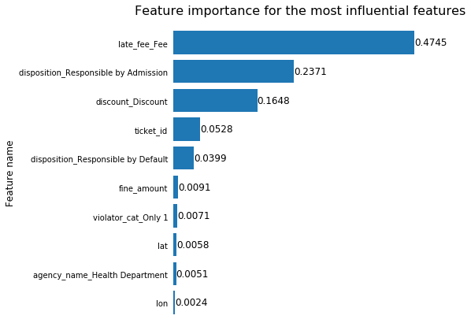

```python
# Finding the feature importance (visualizing only the 10 most important features)
plot_feature_importances(dec_tree_6,
                         X_train.columns.tolist(),
                         figsize_w=8,
                         figsize_h=6,
                         ref_font_size=12,
                         title_offset=0,
                         feat_numb=10,
                         value_offset=0,
                         visible_digits=4)
```

```python
# Calculating the accuracy
print('Accuracy of Decision Tree classifier on the training set: {:.4f}'
     .format(dec_tree_6.score(X_train, y_train)))
print('Accuracy of Decision Tree classifier on the validation set: {:.4f}'
     .format(dec_tree_6.score(X_val, y_val)))
```

```
Accuracy of Decision Tree classifier on the training set: 0.9442
Accuracy of Decision Tree classifier on the validation set: 0.9437
```

```python
# Calculating the probability of the positive class
# Taking the second element of each occurrency of the resulting bidimensional array
score_dt_6 = dec_tree_6.predict_proba(X_val)[:,1]
# Calculating the ROC curve
fpr_dt_6, tpr_dt_6, thresholds = roc_curve(y_val, score_dt_6)
# Calculating the area under the curve
roc_auc_dt_6 = auc(fpr_dt_6, tpr_dt_6)
```

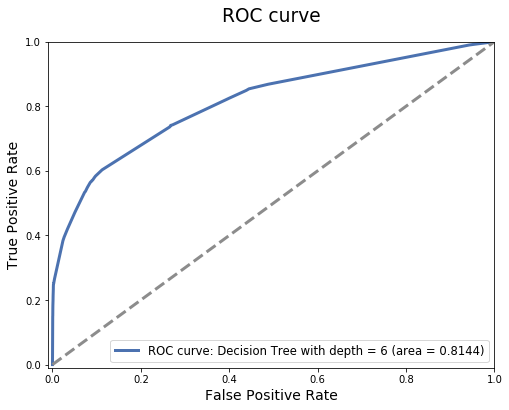

```python
# Plotting the ROC curve
parameters_dt_6 = (fpr_dt_6, tpr_dt_6, roc_auc_dt_6,
                   "ROC curve: Decision Tree with depth = 6")
ROC_Curve(parameters_dt_6,
          figsize_w=8, figsize_h=6,
          ref_font_size=14,
          title="ROC curve",
          title_offset=20,
          col_numb=0)
```

```python
# Calculating the AUC score for the training set
# Taking the second element of each occurrency of the resulting bidimensional array
train_score_dt_6 = dec_tree_6.predict_proba(X_train)[:,1]
# Calculating the AUC score
train_roc_auc_dt_6 = roc_auc_score(y_train, train_score_dt_6)
print("AUC for the training set: {:.4f}".format(train_roc_auc_dt_6))
print("Overfitting indicator: {:.2f}%".\
      format((train_roc_auc_dt_6-roc_auc_dt_6)/roc_auc_dt_6*100))
```

```
AUC for the training set: 0.8195
Overfitting indicator: 0.63%
```

The higher value of the accuracy in the training set shows that this model overfits slightly but this was expected. So, there is no need to try deeper trees.

The AUC value is surprisingly good. This is a good sign since it might mean that the feature selection is good. With good quality data also a simple and imperfect model can reach decent evaluation score values.

According to this preliminary analysis, the most useful predictors are:

- whether there has been no late fine
- whether the responsible violator has admitted the responsibility
- whether there has been a discount

With a considerable smaller influence, there are also the following predictors:

- the fine amount
- whether the violator is a first-time offender

### 6.5. Logistic Regression

This is a generalized linear model used for classification which is fast and is fits well to sparse data. It requires normalization.

```python
from sklearn.linear_model import LogisticRegression

# Fitting a logistic regression model with C = 0.1
log_reg_01 = LogisticRegression(C=0.1, solver="liblinear").fit(X_train_scaled, y_train)
```

```python
# Calculating the accuracy
print('Accuracy of Logistic Regression classifier on the training set: {:.4f}'
     .format(log_reg_01.score(X_train_scaled, y_train)))
print('Accuracy of Logistic Regression classifier on the validation set: {:.4f}'
     .format(log_reg_01.score(X_val_scaled, y_val)))
```

```
Accuracy of Logistic Regression classifier on the training set: 0.9438
Accuracy of Logistic Regression classifier on the validation set: 0.9434
```

```python
# Calculating the probability of the positive class
# Taking the second element of each occurrency of the resulting bidimensional array
score_lr_01 = log_reg_01.predict_proba(X_val_scaled)[:,1]
# Calculating the ROC curve
fpr_lr_01, tpr_lr_01, thresholds = roc_curve(y_val, score_lr_01)
# Calculating the area under the curve
roc_auc_lr_01 = auc(fpr_lr_01, tpr_lr_01)
```

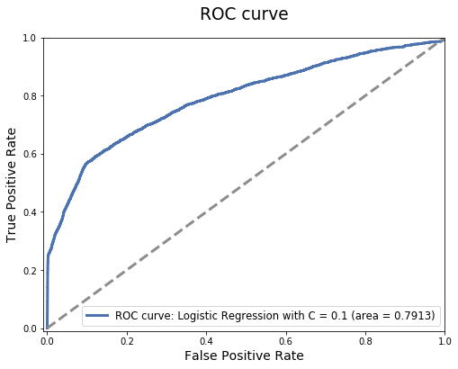

```python
# Plotting the ROC curve
parameters_lr_01 = (fpr_lr_01, tpr_lr_01, roc_auc_lr_01,
                    "ROC curve: Logistic Regression with C = 0.1")
ROC_Curve(parameters_lr_01,
          figsize_w=8, figsize_h=6,
          ref_font_size=14,
          title="ROC curve",
          title_offset=20,
          col_numb=0)
```

```python
# Calculating the AUC score for the training set
# Taking the second element of each occurrency of the resulting bidimensional array
train_score_lr_01 = log_reg_01.predict_proba(X_train_scaled)[:,1]
# Calculating the AUC score
train_roc_auc_lr_01 = roc_auc_score(y_train, train_score_lr_01)
print("AUC for the training set: {:.4f}".format(train_roc_auc_lr_01))
print("Overfitting indicator: {:.2f}%".\
      format((train_roc_auc_lr_01-roc_auc_lr_01)/roc_auc_lr_01*100))
```

```
AUC for the training set: 0.7963
Overfitting indicator: 0.64%
```

```python
# Fitting a logistic regression model with C = 100
log_reg_100 = LogisticRegression(C=100, solver="liblinear").fit(X_train_scaled, y_train)
```

```python
# Calculating the accuracy
print('Accuracy of Logistic Regression classifier on the training set: {:.4f}'
     .format(log_reg_100.score(X_train_scaled, y_train)))
print('Accuracy of Logistic Regression classifier on the validation set: {:.4f}'
     .format(log_reg_100.score(X_val_scaled, y_val)))
```

```
Accuracy of Logistic Regression classifier on the training set: 0.9439
Accuracy of Logistic Regression classifier on the validation set: 0.9434
```

```python
# Calculating the probability of the positive class
# Taking the second element of each occurrency of the resulting bidimensional array
score_lr_100 = log_reg_100.predict_proba(X_val_scaled)[:,1]
# Calculating the ROC curve
fpr_lr_100, tpr_lr_100, thresholds = roc_curve(y_val, score_lr_100)
# Calculating the area under the curve
roc_auc_lr_100 = auc(fpr_lr_100, tpr_lr_100)
```

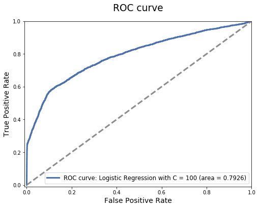

```python
# Plotting the ROC curve
parameters_lr_100 = (fpr_lr_100, tpr_lr_100, roc_auc_lr_100,
                    "ROC curve: Logistic Regression with C = 100")
ROC_Curve(parameters_lr_100,
          figsize_w=8, figsize_h=6,
          ref_font_size=14,
          title="ROC curve",
          title_offset=20,
          col_numb=0)
```

```python
# Calculating the AUC score for the training set
# Taking the second element of each occurrency of the resulting bidimensional array
train_score_lr_100 = log_reg_100.predict_proba(X_train_scaled)[:,1]
# Calculating the AUC score
train_roc_auc_lr_100 = roc_auc_score(y_train, train_score_lr_100)
print("AUC for the training set: {:.4f}".format(train_roc_auc_lr_100))
print("Overfitting indicator: {:.2f}%".\
      format((train_roc_auc_lr_100-roc_auc_lr_100)/roc_auc_lr_100*100))
```

```
AUC for the training set: 0.7993
Overfitting indicator: 0.85%
```

The AUC value seems not to be changing by changing the amount of regularization (C parameter).

### 6.6. Linear Support Vector Machines

Linear Support Vector Machine is a similar method to logistic regression.

```python
from sklearn.svm import LinearSVC

# Fitting a linear support vector machines model with C = 0.01
lsvm_001 = LinearSVC(C=0.01).fit(X_train_scaled, y_train)
```

```python
# Calculating the accuracy
print('Accuracy of Linear Support Vector Machines classifier on the training set: {:.4f}'
     .format(lsvm_001.score(X_train_scaled, y_train)))
print('Accuracy of Linear Support Vector Machines classifier on the validation set: {:.4f}'
     .format(lsvm_001.score(X_val_scaled, y_val)))
```

```
Accuracy of Linear Support Vector Machines classifier on the training set: 0.9441
Accuracy of Linear Support Vector Machines classifier on the validation set: 0.9436
```

```python
# Calculating the decision threshold by using the decision function
score_lsvm_001 = lsvm_001.decision_function(X_val_scaled)
# Calculating the ROC curve
fpr_lsvm_001, tpr_lsvm_001, thresholds = roc_curve(y_val, score_lsvm_001)
# Calculating the area under the curve
roc_auc_lsvm_001 = auc(fpr_lsvm_001, tpr_lsvm_001)
```

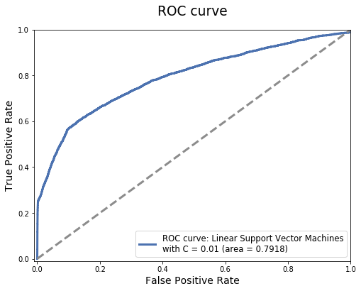

```python
# Plotting the ROC curve
parameters_lsvm_001 = (fpr_lsvm_001, tpr_lsvm_001, roc_auc_lsvm_001,
                       "ROC curve: Linear Support Vector Machines\nwith C = 0.01")
ROC_Curve(parameters_lsvm_001,
          figsize_w=8, figsize_h=6,
          ref_font_size=14,
          title="ROC curve",
          title_offset=20,
          col_numb=0)
```

```python
# Calculating the AUC score for the training set
# Calculating the decision threshold by using the decision function
train_score_lsvm_001 = lsvm_001.decision_function(X_train_scaled)
# Calculating the AUC score
train_roc_auc_lsvm_001 = roc_auc_score(y_train, train_score_lsvm_001)
print("AUC for the training set: {:.4f}".format(train_roc_auc_lsvm_001))
print("Overfitting indicator: {:.2f}%".\
      format((train_roc_auc_lsvm_001-roc_auc_lsvm_001)/roc_auc_lsvm_001*100))
```

```
AUC for the training set: 0.7977
Overfitting indicator: 0.74%
```

```python
# Initializing data to provide consolle feedback
start_time = dt.datetime.now()
print ("Script start time:", start_time)

# Fitting a linear support vector machines model with C = 100
lsvm_100 = LinearSVC(C=100, max_iter=100000).fit(X_train_scaled, y_train)

# Providing consolle feedback
end_time = dt.datetime.now()
print ("Script end time:", end_time)
print ("Script duration:", end_time - start_time)
```

```
Script start time: 2020-02-21 16:40:36.908554
Script end time: 2020-02-21 16:53:52.783930
Script duration: 0:13:15.875376
```

```python
# Calculating the accuracy
print('Accuracy of Linear Support Vector Machines classifier on the training set: {:.4f}'
     .format(lsvm_100.score(X_train_scaled, y_train)))
print('Accuracy of Linear Support Vector Machines classifier on the validation set: {:.4f}'
     .format(lsvm_100.score(X_val_scaled, y_val)))
```

```
Accuracy of Linear Support Vector Machines classifier on the training set: 0.9441
Accuracy of Linear Support Vector Machines classifier on the validation set: 0.9436
```

```python
# Calculating the decision threshold by using the decision function
score_lsvm_100 = lsvm_100.decision_function(X_val_scaled)
# Calculating the ROC curve
fpr_lsvm_100, tpr_lsvm_100, thresholds = roc_curve(y_val, score_lsvm_100)
# Calculating the area under the curve
roc_auc_lsvm_100 = auc(fpr_lsvm_100, tpr_lsvm_100)
```

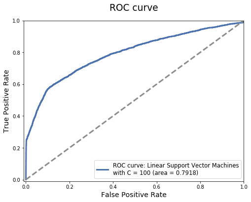

```python
# Plotting the ROC curve
parameters_lsvm_100 = (fpr_lsvm_100, tpr_lsvm_100, roc_auc_lsvm_100,
                       "ROC curve: Linear Support Vector Machines\nwith C = 100")
ROC_Curve(parameters_lsvm_100,
          figsize_w=8, figsize_h=6,
          ref_font_size=14,
          title="ROC curve",
          title_offset=20,
          col_numb=0)
```

```python
# Calculating the AUC score for the training set
# Calculating the decision threshold by using the decision function
train_score_lsvm_100 = lsvm_100.decision_function(X_train_scaled)
# Calculating the AUC score
train_roc_auc_lsvm_100 = roc_auc_score(y_train, train_score_lsvm_100)
print("AUC for the training set: {:.4f}".format(train_roc_auc_lsvm_100))
print("Overfitting indicator: {:.2f}%".\
      format((train_roc_auc_lsvm_100-roc_auc_lsvm_100)/roc_auc_lsvm_100*100))
```

```
AUC for the training set: 0.7990
Overfitting indicator: 0.90%
```

### 6.7. Random Forest

It is an ensemble model, that is, a model that takes multiple individual learning models and combines them to produce an aggregate model that is more powerful than any of its individual learning models alone. This allows averaging out the individual mistakes of the individual models to reduce the risk of overfitting while maintaining strong prediction performance.

Random Forest builds different trees by introducing random variation into the process of building each tree. First, the data used to build each tree is selected randomly and second, the features chosen in each split are also randomly selected.

Each tree is built from a different bootstrap sample. If a training set has N instances, a bootstrap sample of size N is created by repeatedly picking one of the N dataset rows at random with replacement N times.

Like for decision trees, the parameters max_depth, min_samples_split and min_samples_leaf are used to control overfitting.

```python
from sklearn.ensemble import RandomForestClassifier

# Initializing data to provide consolle feedback
start_time = dt.datetime.now()
print ("Script start time:", start_time)

# Fitting a random forest model with 1000 trees with a max depth of 6
rf_1000 = RandomForestClassifier(n_estimators=1000,
                                 max_depth=6,
                                 min_samples_split=24,
                                 min_samples_leaf=12,
                                 random_state=0).fit(X_train, y_train)

# Providing consolle feedback
end_time = dt.datetime.now()
print ("Script end time:", end_time)
print ("Script duration:", end_time - start_time)
```

```
Script start time: 2020-02-21 16:53:53.494935
Script end time: 2020-02-21 16:54:51.874649
Script duration: 0:00:58.379714
```

```python
# Calculating the accuracy
print('Accuracy of Random Forest classifier on the training set: {:.4f}'
     .format(rf_1000.score(X_train, y_train)))
print('Accuracy of Random Forest classifier on the validation set: {:.4f}'
     .format(rf_1000.score(X_val, y_val)))
```

```
Accuracy of Random Forest classifier on the training set: 0.9441
Accuracy of Random Forest classifier on the validation set: 0.9436
```

```python
# Calculating the probability of the positive class
# Taking the second element of each occurrency of the resulting bidimensional array
score_rf_1000 = rf_1000.predict_proba(X_val)[:,1]
# Calculating the ROC curve
fpr_rf_1000, tpr_rf_1000, thresholds = roc_curve(y_val, score_rf_1000)
# Calculating the area under the curve
roc_auc_rf_1000 = auc(fpr_rf_1000, tpr_rf_1000)
```

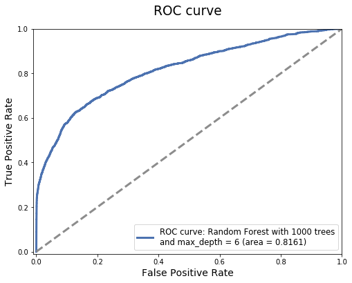

```python
# Plotting the ROC curve
score_rf_1000 = (fpr_rf_1000, tpr_rf_1000, roc_auc_rf_1000,
                 "ROC curve: Random Forest with 1000 trees\nand max_depth = 6")
ROC_Curve(score_rf_1000,
          figsize_w=8, figsize_h=6,
          ref_font_size=14,
          title="ROC curve",
          title_offset=20,
          col_numb=0)
```

```python
# Calculating the AUC score for the training set
# Taking the second element of each occurrency of the resulting bidimensional array
train_score_rf_1000 = rf_1000.predict_proba(X_train)[:,1]
# Calculating the AUC score
train_roc_auc_rf_1000 = roc_auc_score(y_train, train_score_rf_1000)
print("AUC for the training set: {:.4f}".format(train_roc_auc_rf_1000))
print("Overfitting indicator: {:.2f}%".\
      format((train_roc_auc_rf_1000-roc_auc_rf_1000)/roc_auc_rf_1000*100))
```

```
AUC for the training set: 0.8210
Overfitting indicator: 0.60%
```

### 6.8. Gradient Boosted Decision Trees

Ii is also an ensemble model.

The gradient boosted decision trees method builds a series of trees where each tree is trained so that it attempts to correct the mistakes of the previous tree in the series.

The paramater is the learning_rate controls how hard each new tree tries to correct the remaining mistakes from the previous round. A high learning rate means more complex trees. This parameter, together with the max_depth parameter, is used to control overfitting.

```python
from sklearn.ensemble import GradientBoostingClassifier

# Initializing data to provide consolle feedback
start_time = dt.datetime.now()
print ("Script start time:", start_time)

# Fitting a gradient boosted trees model with 1200 trees with a max depth of 5
# (and providing some consolle feedback)
gb_1200 = GradientBoostingClassifier(n_estimators=1200,
                                     max_depth=5,
                                     min_samples_split=20,
                                     min_samples_leaf=10,
                                     learning_rate=0.0015,
                                     verbose=1,
                                     random_state=0).fit(X_train, y_train)

# Providing consolle feedback
end_time = dt.datetime.now()
print ("Script end time:", end_time)
print ("Script duration:", end_time - start_time)
```

```
Script start time: 2020-02-21 16:55:22.058773
      Iter       Train Loss   Remaining Time
         1           0.5199            5.28m
         2           0.5191            5.30m
         3           0.5183            5.37m
         4           0.5175            5.52m
         5           0.5167            5.57m
         6           0.5159            5.56m
         7           0.5152            5.57m
         8           0.5144            5.51m
         9           0.5137            5.47m
        10           0.5129            5.43m
        20           0.5061            5.03m
        30           0.5000            4.85m
        40           0.4946            4.72m
```

[output cut: 17 more lines]

```python
# Calculating the accuracy
print('Accuracy of Gradient Boosted Decision Trees classifier on the training set: {:.4f}'
     .format(gb_1200.score(X_train, y_train)))
print('Accuracy of Gradient Boosted Decision Trees classifier on the validation set: {:.4f}'
     .format(gb_1200.score(X_val, y_val)))
```

```
Accuracy of Gradient Boosted Decision Trees classifier on the training set: 0.9442
Accuracy of Gradient Boosted Decision Trees classifier on the validation set: 0.9436
```

```python
# Calculating the probability of the positive class
# Taking the second element of each occurrency of the resulting bidimensional array
score_gb_1200 = gb_1200.predict_proba(X_val)[:,1]
# Calculating the ROC curve
fpr_gb_1200, tpr_gb_1200, thresholds = roc_curve(y_val, score_gb_1200)
# Calculating the area under the curve
roc_auc_gb_1200 = auc(fpr_gb_1200, tpr_gb_1200)
```

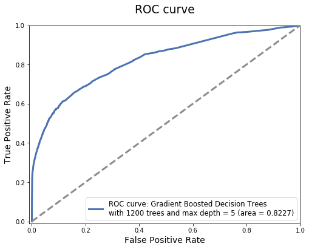

```python
# Plotting the ROC curve
score_gb_1200 = (fpr_gb_1200, tpr_gb_1200, roc_auc_gb_1200,
                 "ROC curve: Gradient Boosted Decision Trees\n"\
                 "with 1200 trees and max depth = 5")
ROC_Curve(score_gb_1200,
          figsize_w=8, figsize_h=6,
          ref_font_size=14,
          title="ROC curve",
          title_offset=20,
          col_numb=0)
```

```python
# Calculating the AUC score for the training set
# Taking the second element of each occurrency of the resulting bidimensional array
train_score_gb_1200 = gb_1200.predict_proba(X_train)[:,1]
# Calculating the AUC score
train_roc_auc_gb_1200 = roc_auc_score(y_train, train_score_gb_1200)
print("AUC for the training set: {:.4f}".format(train_roc_auc_gb_1200))
print("Overfitting indicator: {:.2f}%".\
      format((train_roc_auc_gb_1200-roc_auc_gb_1200)/roc_auc_gb_1200*100))
```

```
AUC for the training set: 0.8287
Overfitting indicator: 0.72%
```

## 7. Selecting the Model

Decison Tree (AUC = 0.8144) scores better than Logistic Regression (AUC = 0.7913) with all values of C.

Linear Support Vector Machines gives similar results as Logistic Regression for different values of C (AUC = 0.7918).

Random Forest provides a good score (AUC = 0.8161).

**Gradient Boosted Decision Trees** provides the best result (**AUC = 0.8227**), which is not so bad, by considering that the highest score obtained by participants in the kaggle competition with the test dataset is [0.83392](https://www.kaggle.com/c/detroit-blight-ticket-compliance/leaderboard).

Since the overfit indicator of the fitted Gradient Boosted Decision Trees model is 0.72%, it is expected that on the test set the auc value might decrease to 0.8168, which is still quite acceptable.

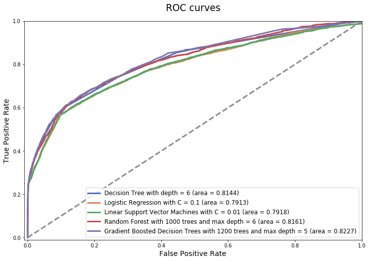

```python
# Comparing the ROC curves and the ROC scores

parameters_dt_6 = (fpr_dt_6, tpr_dt_6, roc_auc_dt_6,
                   "Decision Tree with depth = 6")
parameters_lr_01 = (fpr_lr_01, tpr_lr_01, roc_auc_lr_01,
                    "Logistic Regression with C = 0.1")
parameters_lsvm_001 = (fpr_lsvm_001, tpr_lsvm_001, roc_auc_lsvm_001,
                       "Linear Support Vector Machines with C = 0.01")
parameters_rf_1000 = (fpr_rf_1000, tpr_rf_1000, roc_auc_rf_1000,
                      "Random Forest with 1000 trees and max depth = 6")
parameters_gb_1200 = (fpr_gb_1200, tpr_gb_1200, roc_auc_gb_1200,
                      "Gradient Boosted Decision Trees with 1200 trees "\
                      "and max depth = 5")

ROC_Curve(parameters_dt_6,
          parameters_lr_01,
          parameters_lsvm_001,
          parameters_rf_1000,
          parameters_gb_1200,
          figsize_w=12, figsize_h=8,
          ref_font_size=14,
          title="ROC curves",
          title_offset=20,
          col_numb=0)
```

## 8. Making a Predition

Since the used model is the gradient boosted decision trees, there is no need to normalize the test dataset.

```python
# Making a prediction by using the test dataset
X_test = test_feat_cat
y_test = gb_1200.predict(X_test)
y_test
```

```
array([0, 0, 0, ..., 0, 0, 1])
```

```python
# Calculating the probability that the blight ticket will be paid on time
y_test_prob = gb_1200.predict_proba(X_test)[:,1]
y_test_prob
```

```
array([0.12942924, 0.03547727, 0.0526194 , ..., 0.12944254, 0.12944254,
       0.6894532 ])
```

```python
# Storing the results of the prediction in a dataframe
prediction = pd.DataFrame(index = test_feat_cat.index.tolist(),
                          columns = ['ticket_id', 'compliance_probability'])
prediction['ticket_id'] = test_feat_cat['ticket_id']
prediction['compliance_probability'] = y_test_prob
prediction
```

|  | ticket_id | compliance_probability |
| --- | --- | --- |
| 0 | 284932 | 0.129429 |
| 1 | 285362 | 0.035477 |
| 2 | 285361 | 0.052619 |
| 3 | 285338 | 0.129680 |
| 4 | 285346 | 0.059064 |
| ... | ... | ... |
| 60996 | 376496 | 0.031117 |
| 60997 | 376497 | 0.031117 |
| 60998 | 376499 | 0.129443 |
| 60999 | 376500 | 0.129443 |
| 61000 | 369851 | 0.689453 |

61001 rows × 2 columns

This prediction gives a AUC of 0.8221 on the test set.

## 9. Conclusions

**Data has been manipulated by merging different data sets and by creating new features**.

A new categorical variable has been created to divide violators in 4 classes based on the amount of violations.

Other two categorical variables have been created to indicate whether there has been a late fee and whether there has been a discount (since the late fee is always a fixed percentage of the fine amount and the discount, when applied, it is within a very narrow percentage range).

Year and month have been extracted from the ticket issued date.

**Then data has been cleansed**.

After checking null values and outliers in the train data set, three entries with wrong dara in the ticket issued date have been eliminated from the train dataset.

The entries with finite value in the compliance (entries related to responsible violators) have been selected from the train dataset. Then, the few entries with null values on the coordinates and in the violator category variable have been filled by using the mean for the numerical variables and the most frequent value for the categorical variable.

It has been verified that there were no miss-spelled addresses in the additional files.

**An exploratory data analysis has been done** to check extreme values and the consequent need for normalization, to help in the selection of the potential predictors (features) and to give hints about the prediction methods that would be most likely successful.

This analysis has also helped to confirm that the selected features (like discount and late fee) would not introduce risks of data leakage.

The result of this analysis included a comprehensive list of plots.

As a result of this work, **the following features have been selected**:

- agency_name (categorical)
- year (numerical)
- month (numerical)
- violator_cat (categorical)
- lat (numerical)
- lon (numerical)
- disposition (categorical)
- fine_amount (numerical)
- late_fee (categorical)
- discount (categorical)

In addition, ticket_id has been selected for consistency with the test dataset and the target value (compliance) has been isolated in a separate dataset.

Variables which are not useful predictors because they contain always the same value or because have many zero values or because they would lead to a huge number of variables with many zero values have been dropped. The same has been done for variables that are not considered to be useful predictors because of their meaning or because they are redundant.

**The data has been further prepared for machine learning**.

The category names in the categorical variables have been aligned in the train and the test data sets.

The categorical variables have been converted into indicator variables.

Modifications have been done to the test dataset in order to align it with the modifications done to the training data set.

Finally, a validation data set has been extracted from the train dataset to be used for model evaluation.

**The models to be tried and the evaluation metrics to be used have been identified**.

The result was a dataset with 32 features, containing sparse data. Therefore, a couple of linear models (Logistic Regression and Linear Support Vector Machines) have been tried. Before applying the linear models, the features have been normalized. Also, a Decision Tree has been used as an explorative prediction model. A couple of ensemble models (Random Forest and Gradient Boosted Decision Threes) have been fit as well.

Accuracy was not a useful evaluation metrics due to the presence of many unbalanced classes and the AUC (area under the ROC curve) has been used to evaluate the different models.

**The models have been created and evaluated**.

Care has been taken when tuning the different models that the AUC in the train set was not higher than 1% compared to the AUC value in the validation set, in order to limit overfitting.

Both the extensive data preparation and the careful parameter tuning have paid back.

Decision tree has given a surprising good AUC value on the validation set (AUC = 0.8144) with a reasonably low overfit coefficient (0.63%).

The liner models have performed worst (Logistic Regression gave an AUC of 0.7913 and Linear Support Vector Machines gave an AUC of 0.7918).

Random Forest provided an AUC of 0.8161 while **Gradient Boosted Decision Trees gave the best result of 0.8227 on the validation data set with a overfit coefficient of 0.72%**.

This has led to an **AUC of 0.8221 on the test set**, which is a quite good result by considering that the highest score obtained by participants in the kaggle competition with the test dataset was 0.83392 and the third best value was 0.8215.